# Analysing Sentences Backbone Communities

| Title | Year | Journal | Authors | Number sentences | Words Similarity |
| --- | --- | --- | --- | --- | --- |
| [Toward a Concrete Concept of Effective Competition](https://http://www.jstor.org/stable/1237622) | 1968 | American Journal of Agricultural Economics | Stephen H. Sosnick | 5 | 0.547 |
| [Price Discrimination in Law and Economics](https://http://www.jstor.org/stable/1055530) | 1961 | Southern Economic Journal | Lucile Sheppard Keyes | 4 | 0.518 |
| [The Restoration of Pure Monopoly and the Concept of the Industry](https://http://www.jstor.org/stable/1879549) | 1962 | The Quarterly Journal of Economics | Mancur Olson, David McFarland | 4 | 0.522 |
| [The Economics of Disequilibrium Price](https://http://www.jstor.org/stable/1884199) | 1961 | The Quarterly Journal of Economics | Romney Robinson | 4 | 0.529 |
| [Quantity Discounts and Competition: Economic Rationality or Robinson-Patman](https://http://www.jstor.org/stable/724818) | 1960 | The Journal of Law & Economics | Victor E. Ferrall, Jr. | 4 | 0.534 |
| [Ordo and Coercion: A Logical Critique](https://http://www.jstor.org/stable/1055165) | 1960 | Southern Economic Journal | Henry M. Oliver, Jr. | 3 | 0.524 |
| [The Impact on General Theory](https://http://www.jstor.org/stable/1818487) | 1964 | The American Economic Review | Robert L. Bishop | 3 | 0.522 |
| [Friedman and Machlup on the Significance of Testing Economic Assumptions](https://http://www.jstor.org/stable/1828428) | 1965 | Journal of Political Economy | Jack Melitz | 3 | 0.550 |
| [The Feedback Effect of Business Conduct on Industry Structure](https://http://www.jstor.org/stable/724982) | 1969 | The Journal of Law & Economics | William L. Baldwin | 3 | 0.510 |
| [Legislative Intent and the Policy of the Sherman Act](https://http://www.jstor.org/stable/724991) | 1966 | The Journal of Law & Economics | Robert H. Bork | 3 | 0.530 |

| Title | Year | Journal | Authors | Number sentences | Words Similarity |
| --- | --- | --- | --- | --- | --- |
| [Surveys of Applied Economics: Price Behaviour of Firms](https://http://www.jstor.org/stable/2229953) | 1970 | The Economic Journal | Aubrey Silberston | 31 | 0.529 |
| [An Essay on Monopoly Power and Stable Price Policy](https://http://www.jstor.org/stable/1802497) | 1979 | The American Economic Review | S. Y. Wu | 10 | 0.544 |
| [Competition, Exclusion, and the Optimal Supply of Public Goods](https://http://www.jstor.org/stable/725143) | 1978 | The Journal of Law & Economics | Thomas E. Borcherding | 9 | 0.537 |
| [Price Expectations and the Welfare Gains from Price Stabilization](https://http://www.jstor.org/stable/1239300) | 1974 | American Journal of Agricultural Economics | Stephen J. Turnovsky | 8 | 0.539 |
| [Demand Theory and the Economist’s Propensity to Assume](https://http://www.jstor.org/stable/4224224) | 1973 | Journal of Economic Issues | Philip A. Klein | 8 | 0.521 |
| [Adam Smith: The Labor Market as the Basis of Natural Right](https://http://www.jstor.org/stable/4224563) | 1977 | Journal of Economic Issues | Thomas J. Lewis | 8 | 0.536 |
| [Some Lessons of Price Controls in 1971-1973](https://www.jstor.org/stable/10.2307/3003214) | 1975 | The Bell Journal of Economics | D. Quinn Mills | 8 | 0.528 |
| [The Two Price Systems in the Copper Industry](https://www.jstor.org/stable/10.2307/3003215) | 1975 | The Bell Journal of Economics | David L. McNicol | 8 | 0.527 |
| [Discretionary pricing and tax shifting](https://doi.org/10.1177/109114217800600101) | 1978 | Public Finance Review | Frankel M. | 7 | 0.534 |
| [Prices vs. Quantities](https://http://www.jstor.org/stable/2296698) | 1974 | The Review of Economic Studies | Martin L. Weitzman | 7 | 0.552 |

| Title | Year | Journal | Authors | Number sentences | Words Similarity |
| --- | --- | --- | --- | --- | --- |
| [Uncertainty, Information and Investment Decisions](https://http://www.jstor.org/stable/2325741) | 1971 | The Journal of Finance | R. G. E. Smith | 31 | 0.539 |
| [The Investment Decision of the Firm Under Uncertainty and the Allocative Efficiency of Capital Markets](https://http://www.jstor.org/stable/2326628) | 1976 | The Journal of Finance | Niels Christian Nielsen | 17 | 0.544 |
| [A Theory of Competitive Equilibrium in Stock Market Economies](https://http://www.jstor.org/stable/1914186) | 1979 | Econometrica | Sanford J. Grossman, Oliver D. Hart | 12 | 0.551 |
| [A Note on Investment Evaluations in Light of Uncertain Future Opportunities](https://http://www.jstor.org/stable/2978852) | 1972 | The Journal of Finance | Bernhard Schwab, Peter Lusztig | 12 | 0.539 |
| On the financing and investment decisions of the firm | 1978 | Journal of Banking and Finance | Nielsen N.C. | 11 | 0.535 |
| [The Investment System of a Socialist Economy](https://http://www.jstor.org/stable/4379461) | 1973 | Eastern European Economics | Eugeniusz Rychlewski, A. I. Ross | 11 | 0.581 |
| [Production, Investment and Idle Capacity](https://http://www.jstor.org/stable/1056347) | 1976 | Southern Economic Journal | Michael S. Proctor | 9 | 0.531 |
| [On the Irrelevance of Corporate Financial Policy](https://http://www.jstor.org/stable/1815238) | 1974 | The American Economic Review | Joseph E. Stiglitz | 9 | 0.532 |
| [Some Aspects of Firms’ Decision Making in an Economy with Incomplete Capital Markets](https://http://www.jstor.org/stable/3439362) | 1974 | The Swedish Journal of Economics | Steinar Ekern | 9 | 0.538 |
| Capital asset prices with heterogeneous beliefs | 1977 | Journal of Financial Economics | Williams J. | 8 | 0.530 |

| Title | Year | Journal | Authors | Number sentences | Words Similarity |
| --- | --- | --- | --- | --- | --- |
| [Satisficing, Selection, and The Innovating Remnant](https://http://www.jstor.org/stable/1880703) | 1971 | The Quarterly Journal of Economics | Sidney G. Winter | 16 | 0.577 |
| [Surveys of Applied Economics: Price Behaviour of Firms](https://http://www.jstor.org/stable/2229953) | 1970 | The Economic Journal | Aubrey Silberston | 9 | 0.544 |
| [Some Problems concerning the Role and Motivation of Enterprise Executives](https://http://www.jstor.org/stable/4379488) | 1974 | Eastern European Economics | Zsuzsa Hegedüs, Márton Tardos, George Hajdu | 6 | 0.511 |
| [X-Theory versus Management Discretion Theory](https://http://www.jstor.org/stable/1056828) | 1971 | Southern Economic Journal | M. A. Crew, M. W. Jones-Lee, C. K. Rowley | 5 | 0.529 |
| [Diffusion of Major Technological Innovations in U.S. Iron and Steel Manufacturing](https://http://www.jstor.org/stable/2097611) | 1970 | The Journal of Industrial Economics | Bela Gold, William S. Peirce, Gerhard Rosegger | 5 | 0.529 |
| [Property Rights and Economic Theory: A Survey of Recent Literature](https://http://www.jstor.org/stable/2721541) | 1972 | Journal of Economic Literature | Eirik G. Furubotn, Svetozar Pejovich | 5 | 0.570 |
| [Bonus Formulae and Soviet Managerial Performance](https://http://www.jstor.org/stable/1056854) | 1970 | Southern Economic Journal | Wayne A. Leeman | 4 | 0.526 |
| [Managerial Pay and Corporate Performance](https://http://www.jstor.org/stable/1818414) | 1970 | The American Economic Review | Wilbur G. Lewellen, Blaine Huntsman | 4 | 0.547 |
| [Public Responsibility in the Private Corporation](https://http://www.jstor.org/stable/2098241) | 1972 | The Journal of Industrial Economics | Kenneth R. Andrews | 4 | 0.523 |
| [Toward a General Theory of Managerial Discretion [with Comment and Reply]](https://http://www.jstor.org/stable/30023151) | 1974 | Public Choice | Jean-Luc Migué, Gérard Bélanger, William A. Niskanen, Jean-Luc Migué, Gérard Bélanger | 4 | 0.553 |

| Title | Year | Journal | Authors | Number sentences | Words Similarity |
| --- | --- | --- | --- | --- | --- |
| [Efficient Capital Markets and Martingales](https://http://www.jstor.org/stable/2727024) | 1989 | Journal of Economic Literature | Stephen F. LeRoy | 34 | 0.569 |
| [Dividend Variability and Variance Bounds Tests for the Rationality of Stock Market Prices](https://http://www.jstor.org/stable/1813364) | 1986 | The American Economic Review | Terry A. Marsh, Robert C. Merton | 27 | 0.586 |
| [Informed Speculation with Imperfect Competition](https://http://www.jstor.org/stable/2297551) | 1989 | The Review of Economic Studies | Albert S. Kyle | 24 | 0.525 |
| [Speculation, Optimism and Differential Information](https://http://www.jstor.org/stable/1058961) | 1986 | Southern Economic Journal | Torben M. Andersen | 19 | 0.553 |
| [Stock Prices and Social Dynamics](https://http://www.jstor.org/stable/2534436) | 1984 | Brookings Papers on Economic Activity | Robert J. Shiller, Stanley Fischer, Benjamin M. Friedman | 18 | 0.546 |
| [Information Dissemination and Portfolio Choice](https://doi.org/10.2307/2330801) | 1983 | Journal of Financial and Quantitative Analysis | Barry C.B. | 16 | 0.535 |
| [Information Diversity and Market Behavior](https://http://www.jstor.org/stable/2327119) | 1982 | The Journal of Finance | Stephen Figlewski | 16 | 0.541 |
| [An Asset-Pricing Theory Unifying the CAPM and APT](https://http://www.jstor.org/stable/2328141) | 1988 | The Journal of Finance | K. C. John Wei | 15 | 0.536 |
| [Arbitrage and Diversification in a General Equilibrium Asset Economy](https://http://www.jstor.org/stable/1912700) | 1988 | Econometrica | Frank Milne | 14 | 0.535 |
| [Information and Equilibrium with Inside Traders](https://http://www.jstor.org/stable/2234077) | 1989 | The Economic Journal | Leonard J. Mirman, Larry Samuelson | 14 | 0.541 |

| Title | Year | Journal | Authors | Number sentences | Words Similarity |
| --- | --- | --- | --- | --- | --- |
| [Irreversibility, Uncertainty, and Cyclical Investment](https://http://www.jstor.org/stable/1885568) | 1983 | The Quarterly Journal of Economics | Ben S. Bernanke | 9 | 0.557 |
| The effects of uncertainty on investment and the expected long-run capital stock | 1984 | Journal of Economic Dynamics and Control | Abel A. | 7 | 0.540 |
| Environmental policy choice with an uncertain chance of irreversibility | 1985 | Journal of Environmental Economics and Management | Kip Viscusi W. | 5 | 0.541 |
| Corporate financing and investment decisions when firms have information that investors do not have | 1984 | Journal of Financial Economics | Myers S.C. | 5 | 0.548 |
| [Financial Constraints and Capital Accumulation](https://http://www.jstor.org/stable/2526359) | 1980 | International Economic Review | William E. Schworm | 5 | 0.528 |
| [Investment and q in a Stock Valuation Model](https://http://www.jstor.org/stable/1058158) | 1981 | Southern Economic Journal | Gary Smith | 4 | 0.529 |
| [On the “q” Theory of Investment](https://http://www.jstor.org/stable/1803570) | 1980 | The American Economic Review | Hiroshi Yoshikawa | 4 | 0.547 |
| [Deficient Foresight: A Troublesome Theme in Keynesian Economics](https://http://www.jstor.org/stable/1831546) | 1982 | The American Economic Review | Alan Coddington | 4 | 0.581 |
| [The Effects of Uncertainty on Investment under Risk Neutrality with Endogenous Information](https://http://www.jstor.org/stable/1831926) | 1980 | Journal of Political Economy | Alex Cukierman | 4 | 0.516 |
| [Financial Volatility and the q Theory of Investment](https://http://www.jstor.org/stable/2554517) | 1986 | Economica | Kazuo Ueda, Hiroshi Yoshikawa | 4 | 0.537 |

| Title | Year | Journal | Authors | Number sentences | Words Similarity |
| --- | --- | --- | --- | --- | --- |
| [The New Keynesian Microfoundations](https://http://www.jstor.org/stable/4623707) | 1987 | NBER Macroeconomics Annual | Julio J. Rotemberg | 16 | 0.532 |
| [Sticky Prices and Disequilibrium Adjustment in a Rational Model of the Inflationary Process](https://http://www.jstor.org/stable/1803483) | 1981 | The American Economic Review | Michael Mussa | 11 | 0.561 |
| [Unemployment from a Theoretical Viewpoint](https://http://www.jstor.org/stable/2553151) | 1980 | Economica | F. H. Hahn | 10 | 0.536 |
| [Output Fluctuations and Gradual Price Adjustment](https://http://www.jstor.org/stable/2724154) | 1981 | Journal of Economic Literature | Robert J. Gordon | 10 | 0.550 |
| [Commodities and Capital: Prices and Quantities](https://http://www.jstor.org/stable/1803922) | 1983 | The American Economic Review | Gardner Ackley | 9 | 0.555 |
| [Recent Developments in Macroeconomic Disequilibrium Theory](https://http://www.jstor.org/stable/1911097) | 1980 | Econometrica | Allan Drazen | 9 | 0.560 |
| [Adjustment Lags, Economically Rational Expectations and Price Behavior](https://http://www.jstor.org/stable/1924092) | 1981 | The Review of Economics and Statistics | Louis J. Maccini | 9 | 0.537 |
| [The Valid Core of Rationality Hypotheses In the Theory of Expectations](https://http://www.jstor.org/stable/1992033) | 1980 | Journal of Money, Credit and Banking | William Fellner | 9 | 0.569 |
| [AGONISING OVER EQUILIBRIUM: HAYEK AND LINDAHL](https://www.jstor.org/stable/10.2307/43315381) | 1989 | Quaderni di storia dell’economia politica | Martin Currie, Ian Steedman | 9 | 0.533 |
| Price and output responsiveness to nominal changes under differential information | 1985 | European Economic Review | Andersen T. | 8 | 0.552 |

#### Top articles for 1_4_1900-1919: price_fixing, price, price_determination, tho, prices (1990-1999)

| Title | Year | Journal | Authors | Number sentences | Words Similarity |
| --- | --- | --- | --- | --- | --- |
| [Bargaining and the Right to Remain Silent](https://http://www.jstor.org/stable/2951585) | 1992 | Econometrica | Lawrence M. Ausubel, Raymond J. Deneckere | 27 | 0.557 |
| [Stationarity, Rationalizability and Bargaining](https://http://www.jstor.org/stable/2297985) | 1994 | The Review of Economic Studies | In-Koo Cho | 24 | 0.556 |
| [Secret Reserve Prices in a Bidding Model with a Resale Option](https://http://www.jstor.org/stable/2951368) | 1997 | The American Economic Review | Ignatius J. Horstmann, Chantale LaCasse | 22 | 0.530 |
| [Competition among Sellers Who Offer Auctions Instead of Prices](https://doi.org/10.1006/jeth.1997.2278) | 1997 | Journal of Economic Theory | Peters M. | 19 | 0.531 |
| [The Price is Right, But are the Bids? An Investigation of Rational Decision Theory](https://http://www.jstor.org/stable/2118313) | 1996 | The American Economic Review | Jonathan B. Berk, Eric Hughson, Kirk Vandezande | 18 | 0.553 |
| [Repeated Signalling Games and Dynamic Trading Relationships](https://http://www.jstor.org/stable/2527293) | 1998 | International Economic Review | Daniel R. Vincent | 18 | 0.558 |
| [Decentralized Markets and Endogenous Institutions](https://http://www.jstor.org/stable/136032) | 1995 | The Canadian Journal of Economics / Revue canadienne d’Economique | Michael Peters | 17 | 0.531 |
| [A Competitive Distribution of Auctions](https://http://www.jstor.org/stable/2971742) | 1997 | The Review of Economic Studies | Michael Peters | 17 | 0.547 |
| [Coase versus Pacman: Who Eats Whom in the Durable-Goods Monopoly?](https://http://www.jstor.org/stable/2138582) | 1995 | Journal of Political Economy | Nils-Henrik Mørch von der Fehr, Kai-Uwe Kühn | 15 | 0.524 |
| [Uncertainty and Delay in Bargaining](https://http://www.jstor.org/stable/2298087) | 1990 | The Review of Economic Studies | In-Koo Cho | 15 | 0.550 |

| Title | Year | Journal | Authors | Number sentences | Words Similarity |
| --- | --- | --- | --- | --- | --- |
| The effects of irreversibility and uncertainty on capital accumulation | 1999 | Journal of Monetary Economics | Abel A.B. | 17 | 0.538 |
| [Psychological Factors and Stock Option Exercise](https://http://www.jstor.org/stable/2587018) | 1999 | The Quarterly Journal of Economics | Chip Heath, Steven Huddart, Mark Lang | 12 | 0.567 |
| Measuring option prices from market behavior | 1992 | Journal of Environmental Economics and Management | Larson D. | 10 | 0.530 |
| An empirical analysis of common stock call exercise: A note | 1997 | Journal of Banking and Finance | Finucane T.J. | 9 | 0.545 |
| [Investment and Hysteresis](https://http://www.jstor.org/stable/2138376) | 1992 | The Journal of Economic Perspectives | Avinash Dixit | 9 | 0.528 |
| [A General Equilibrium Analysis of Option and Stock Market Interactions](https://http://www.jstor.org/stable/2526876) | 1991 | International Economic Review | Jerome Detemple, Larry Selden | 9 | 0.536 |
| The exercise and valuation of executive stock options | 1998 | Journal of Financial Economics | Carpenter J.N. | 8 | 0.539 |
| Real investment decisions under adjustment costs and asymmetric information | 1998 | Journal of Economic Dynamics and Control | Gaudet G. | 8 | 0.541 |
| [Option Volume and Stock Prices: Evidence on Where Informed Traders Trade](https://http://www.jstor.org/stable/117358) | 1998 | The Journal of Finance | David Easley, Maureen O’Hara, P. S. Srinivas | 8 | 0.530 |
| [Inflation Uncertainty, Relative Price Uncertainty, and Investment in U.S. Manufacturing](https://http://www.jstor.org/stable/2077721) | 1993 | Journal of Money, Credit and Banking | John Huizinga | 8 | 0.526 |

| Title | Year | Journal | Authors | Number sentences | Words Similarity |
| --- | --- | --- | --- | --- | --- |
| [Construction of a State Space for Interrelated Securities with an Application to Temporary Equilibrium Theory](https://http://www.jstor.org/stable/25054982) | 1996 | Economic Theory | Philippe Henrotte | 12 | 0.543 |
| [Asset Markets and Equilibrium Processes](https://http://www.jstor.org/stable/2297380) | 1990 | The Review of Economic Studies | Jayasri Dutta, Herakles Polemarchakis | 11 | 0.524 |
| Equilibrium asset prices with undiversifiable labor income risk | 1992 | Journal of Economic Dynamics and Control | Weil P. | 9 | 0.551 |
| [A Revealed Preference Analysis of Asset Pricing Under Recursive Utility](https://http://www.jstor.org/stable/2298079) | 1995 | The Review of Economic Studies | Larry G. Epstein, Angelo Melino | 9 | 0.527 |
| [On the Arbitrage Pricing Theory](https://http://www.jstor.org/stable/25054609) | 1991 | Economic Theory | Christian Gilles, Stephen F. LeRoy | 9 | 0.524 |
| [Arbitrage, Bubbles, and Valuation](https://http://www.jstor.org/stable/2527383) | 1997 | International Economic Review | Jan Werner | 9 | 0.524 |
| Arbitrage, equilibrium, and gains from trade: A counterexample | 1997 | Journal of Mathematical Economics | Monteiro P. | 8 | 0.526 |
| [Arbitrage and Existence of Equilibrium in Infinite Asset Markets](https://http://www.jstor.org/stable/2297843) | 1995 | The Review of Economic Studies | Donald J. Brown, Jan Werner | 8 | 0.520 |
| [Asset-Pricing Puzzles and Incomplete Markets](https://http://www.jstor.org/stable/2329068) | 1993 | The Journal of Finance | Chris I. Telmer | 8 | 0.524 |
| A multibeta representation theorem for linear asset pricing theories | 1997 | Journal of Financial Economics | Nawalkha S. | 7 | 0.518 |

#### Top articles for 1_8_1900-1919: business, employers, scientific, management, business_activity (1990-1999)

| Title | Year | Journal | Authors | Number sentences | Words Similarity |
| --- | --- | --- | --- | --- | --- |
| Aggressiveness and survival of overconfident traders | 1998 | Journal of Financial Markets | Benos A.V. | 71 | 0.589 |
| [Volume, Volatility, Price, and Profit When All Traders Are above Average](https://http://www.jstor.org/stable/117456) | 1998 | The Journal of Finance | Terrance Odean | 61 | 0.569 |
| Public information and heuristic trade | 1999 | Journal of Accounting and Economics | Fischer P. | 56 | 0.548 |
| [Positive Feedback Investment Strategies and Destabilizing Rational Speculation](https://http://www.jstor.org/stable/2328662) | 1990 | The Journal of Finance | J. Bradford de Long, Andrei Shleifer, Lawrence H. Summers, Robert J. Waldmann | 51 | 0.570 |
| [Common beliefs and the existence of speculative trade](https://doi.org/10.1006/game.1996.0075) | 1996 | Games and Economic Behavior | Neeman Z. | 36 | 0.590 |
| [Noise Trader Risk in Financial Markets](https://http://www.jstor.org/stable/2937765) | 1990 | Journal of Political Economy | J. Bradford De Long, Andrei Shleifer, Lawrence H. Summers, Robert J. Waldmann | 35 | 0.558 |
| [Rational Asset-Price Movements Without News](https://http://www.jstor.org/stable/2117551) | 1993 | The American Economic Review | David Romer | 34 | 0.567 |
| [Speculation Duopoly with Agreement to Disagree: Can Overconfidence Survive the Market Test?](https://http://www.jstor.org/stable/2329474) | 1997 | The Journal of Finance | Albert S. Kyle, F. Albert Wang | 30 | 0.572 |
| Endogenous sunspots, pseudo-bubbles, and beliefs about beliefs | 1998 | Journal of Financial Markets | Kraus A. | 28 | 0.565 |
| Strategic trading, asymmetric information and heterogeneous prior beliefs | 1998 | Journal of Financial Markets | Albert Wang F. | 27 | 0.551 |

| Title | Year | Journal | Authors | Number sentences | Words Similarity |
| --- | --- | --- | --- | --- | --- |
| [Feedback and the success of irrational investors](https://doi.org/10.1016/j.jfineco.2005.05.006) | 2006 | Journal of Financial Economics | Hirshleifer D. | 142 | 0.611 |
| [The Price Impact and Survival of Irrational Traders](https://http://www.jstor.org/stable/3699339) | 2006 | The Journal of Finance | Leonid Kogan, Stephen A. Ross, Jiang Wang, Mark M. Westerfield | 94 | 0.588 |
| [Arrogance can be a virtue: Overconfidence, information acquisition, and market efficiency](https://doi.org/10.1016/j.jfineco.2006.03.002) | 2007 | Journal of Financial Economics | Ko K. | 67 | 0.584 |
| [On the Impossibility of Weak-form Efficient Markets](https://doi.org/10.2307/4126730) | 2003 | Journal of Financial and Quantitative Analysis | Slezak S.L. | 63 | 0.621 |
| [The effects of intelligence on price discovery and market efficiency](https://doi.org/10.1016/j.jebo.2008.07.002) | 2008 | Journal of Economic Behavior and Organization | Yeh C.H. | 55 | 0.579 |
| [A simple asset pricing model with social interactions and heterogeneous beliefs](https://doi.org/10.1016/j.jedc.2006.04.008) | 2007 | Journal of Economic Dynamics and Control | Chang S.K. | 48 | 0.587 |
| [Overconfidence and market efficiency with heterogeneous agents](https://http://www.jstor.org/stable/27822479) | 2007 | Economic Theory | Diego García, Francesco Sangiorgi, Branko Urošević | 48 | 0.601 |
| Speculating against an overconfident market | 2003 | Journal of Financial Markets | Caballé J. | 47 | 0.543 |
| [The impact of individual and institutional investor sentiment on the market price of risk](https://doi.org/10.1016/j.qref.2008.11.001) | 2009 | Quarterly Review of Economics and Finance | Verma R. | 47 | 0.574 |
| Investor psychology in capital markets: Evidence and policy implications | 2002 | Journal of Monetary Economics | Daniel K. | 46 | 0.579 |

| Title | Year | Journal | Authors | Number sentences | Words Similarity |
| --- | --- | --- | --- | --- | --- |
| Advertising and prices as signals of quality in a regime of price rivalry | 2002 | International Journal of Industrial Organization | Fluet C. | 20 | 0.562 |
| Bounded rationality, dynamic oligopoly, and conjectural variations | 2002 | Journal of Economic Behavior and Organization | Friedman J.W. | 17 | 0.561 |
| [Entry and exit with information externalities](https://doi.org/10.1016/j.jebo.2004.07.003) | 2006 | Journal of Economic Behavior and Organization | Comino S. | 16 | 0.548 |
| [Strategic trade and delegated competition](https://doi.org/10.1016/j.jinteco.2004.04.003) | 2005 | Journal of International Economics | Miller N.H. | 15 | 0.544 |
| [When behavior matters: Games and computation in A Behavioral Theory of the Firm](https://doi.org/10.1016/j.jebo.2006.12.005) | 2008 | Journal of Economic Behavior and Organization | Prietula M. | 13 | 0.561 |
| [Price vs. quantity in oligopoly games](https://doi.org/10.1016/j.ijindorg.2005.07.009) | 2006 | International Journal of Industrial Organization | Tasnádi A. | 12 | 0.557 |
| [Predatory reputation in US airline markets](https://doi.org/10.1016/j.ijindorg.2009.02.002) | 2009 | International Journal of Industrial Organization | Kim S. | 12 | 0.566 |
| [Information-constrained state-dependent pricing](https://doi.org/10.1016/j.jmoneco.2009.06.014) | 2009 | Journal of Monetary Economics | Woodford M. | 11 | 0.545 |
| [Flexible reservation prices and price inflexibility](https://doi.org/10.1016/j.econmod.2007.08.001) | 2008 | Economic Modelling | Gangopadhyay P. | 10 | 0.555 |
| [The escape from conjectural variations: the consistency condition in duopoly theory from Bowley to Fellner](https://http://www.jstor.org/stable/23602162) | 2005 | Cambridge Journal of Economics | Nicola Giocoli | 10 | 0.548 |

| Title | Year | Journal | Authors | Number sentences | Words Similarity |
| --- | --- | --- | --- | --- | --- |
| Discretionary disclosure, efficiency, and signal informativeness | 2002 | Journal of Accounting and Economics | Pae S. | 73 | 0.557 |
| [Financial intermediation as a beliefs-bridge between optimists and pessimists](https://doi.org/10.1016/j.jfineco.2004.02.005) | 2005 | Journal of Financial Economics | Coval J. | 53 | 0.595 |
| [Investment under uncertainty and time-inconsistent preferences](https://doi.org/10.1016/j.jfineco.2006.01.002) | 2007 | Journal of Financial Economics | Grenadier S. | 53 | 0.549 |
| [Clearly Irrational Financial Market Behavior: Evidence from the Early Exercise of Exchange Traded Stock Options](https://http://www.jstor.org/stable/3094481) | 2003 | The Journal of Finance | Allen M. Poteshman, Vitaly Serbin | 47 | 0.580 |
| [Early-stage financing and firm growth in new industries](https://doi.org/10.1016/j.jfineco.2008.07.004) | 2009 | Journal of Financial Economics | Inderst R. | 33 | 0.554 |
| [Devaluating projects and the investment-uncertainty relationship](https://doi.org/10.1016/j.jedc.2006.12.013) | 2007 | Journal of Economic Dynamics and Control | Gutiérrez O. | 22 | 0.549 |
| Capital market equilibrium with moral hazard | 2002 | Journal of Mathematical Economics | Magill M. | 21 | 0.555 |
| Evidence of irreversibility in the UK property market | 2001 | Quarterly Review of Economics and Finance | Sing T.F. | 21 | 0.548 |
| [Uncertainty, irreversibility, and the likelihood of entry: An empirical assessment of the option to defer](https://doi.org/10.1016/j.jebo.2004.11.011) | 2006 | Journal of Economic Behavior and Organization | Folta T.B. | 19 | 0.541 |
| [Investment timing and predatory behavior in a duopoly with endogenous exit](https://doi.org/10.1016/j.jedc.2006.10.006) | 2007 | Journal of Economic Dynamics and Control | Bayer C. | 19 | 0.548 |

### Most cited references in the backbone community

| First Author | Year | Journal | Citation by article | Citation by sentence |
| --- | --- | --- | --- | --- |
| KYLE-A | 1985 | ECONOMETRICA | 28 | 5712 |
| MERTON-R | 1973 | BELL J EC MANAGEMENT | 67 | 4288 |
| MEHRA-R | 1985 | J MONETARY EC | 92 | 3680 |
| SHARPE-W | 1964 | J FINANCE | 168 | 2688 |
| ROTHSCHILD-M | 1970 | J ECONOMIC THEORY | 30 | 2220 |
| MODIGLIANI-F | 1958 | AM EC REV | 84 | 1260 |
| CALVO-G | 1983 | J MONETARY ECON | 104 | 1040 |
| MERTON-R | 1973 | ECONOMETRICA | 82 | 984 |
| COX-J | 1985 | ECONOMETRICA | 24 | 840 |
| PINDYCK-R | 1991 | J ECON LIT | 44 | 704 |
| BLACK-F | 1973 | J POLITICAL EC | 130 | 650 |
| LINTNER-J | 1965 | REV EC STATISTICS | 80 | 640 |
| MUTH-J | 1961 | ECONOMETRICA | 92 | 552 |
| DELONG-J | 1990 | J POLIT ECON | 2 | 406 |
| HIRSHLEIFER-D | 1994 | J FINANC | 2 | 406 |

| First Author | Year | Journal | Citation by article | Citation by sentence |
| --- | --- | --- | --- | --- |
| KEYNES-J | 1936 | GENERAL THEORY EMPLO | 206 | 21630 |
| DIXIT-A | 1994 | INVESTMENT UNCERTAIN | 277 | 19390 |
| FRIEDMAN-M | 1953 | ESSAYS POSITIVE EC | 102 | 16422 |
| DEBREU-G | 1959 | THEORY VALUE | 226 | 13560 |
| SHILLER-R | 2000 | IRRATIONAL EXUBERANC | 80 | 11360 |
| CAMPBELL-J | 1997 | ECONOMETRICS FINANCI | 81 | 5427 |
| TIROLE-J | 1988 | THEORY IND ORG | 209 | 4389 |
| SHLEIFER-A | 2000 | INEFFICIENT MARKETS | 75 | 3600 |
| KAHNEMAN-D | 1982 | JUDGMENT UNCERTAINTY | 35 | 3150 |
| FAMA-E | 1976 | F FINANCE | 74 | 2516 |
| KEYNES-J | 1936 | GEN THEORY EMPLOYMEN | 66 | 2376 |
| SHILLER-R | 1989 | MARKET VOLATILITY | 36 | 2196 |
| CYERT-R | 1963 | BEHAVIORAL THEORY FI | 37 | 1739 |
| BAUMOL-W | 1959 | BUSINESS BEHAVIOR VA | 44 | 1628 |
| MARRIS-R | 1964 | ECONOMIC THEORY MANA | 31 | 1457 |

### Most cited references per kmean clusters

| First Author | Year | Journal | Citation by article | Citation by sentence |
| --- | --- | --- | --- | --- |
| SHOVEGF | 1944 | ECON J | 1 | 3 |
| KEYNESJM | 1936 | GENERAL THEORY EMPLO | 1 | 3 |
| MORGANEV | 1944 | ECON J | 1 | 3 |
| GRAHAMF | 1944 | ECON J | 1 | 3 |
| BROWN | 1493 | HIST ACCOUNTING ACCO | 1 | 3 |
| BURN | 1940 | EC HIST STEEL MAKING | 1 | 3 |
| HAYEK | 1944 | ECONOMICA | 1 | 3 |
| MACHLUPF | 1942 | ECONOMICA 1 | 1 | 3 |
| MACHLUP | 1942 | ECONOMICA 2 | 1 | 3 |
| ROBBINSL | 1933 | COMMON SENSE POLITIC | 1 | 3 |

| First Author | Year | Journal | Citation by article | Citation by sentence |
| --- | --- | --- | --- | --- |
| SWEEZYPM | 1942 | THEORY CAPITALIST DE | 2 | 4 |
| FISKHE | 1920 | ENGLISH PUBLIC FINAN | 1 | 3 |
| SMART | 1801 | EC ANN 19 CENTURY | 1 | 3 |
| CRIDERJH | 1944 | SATURDAY EVENIN 0226 | 1 | 3 |
| HAHNLA | 1943 | B CHAMBER COMMERCE P | 1 | 3 |
| HARRISSE | 1941 | EC SOCIAL SECURITY | 1 | 3 |
| KNIGHTFH | 1941 | REV EC STAT | 1 | 3 |
| MOULTONHG | 1943 | NEW PHILOS PUBLIC DE | 1 | 3 |
| MOULTONHG | 1940 | CAPITAL EXPANSION EM | 1 | 3 |
| ROBERTSONDH | 1940 | ESSAYS MONETARY THEO | 1 | 3 |

| First Author | Year | Journal | Citation by article | Citation by sentence |
| --- | --- | --- | --- | --- |
| HENDERSON | 1941 | REV EC STAT MAY | 1 | 7 |
| HARRODRF | 1939 | OXFORD ECON PAP | 2 | 6 |
| *NATBURECRES | 1945 | COST BEH PRIC POL | 1 | 5 |
| HALLRL | 1939 | OXFORD ECON PAP | 1 | 5 |
| COASE-R | 1946 | ECONOMICA | 1 | 4 |
| STIGLER-G | 1939 | JPE | 1 | 4 |
| HOTELLING-H | 1938 | ECONOMETRICA | 1 | 4 |
| HUTTWH | 1940 | ECON J | 1 | 4 |
| TINTNERG | 1946 | ECONOMETRICA | 1 | 4 |
| LANGE-O | 1942 | ECONOMETRICA | 1 | 4 |

| First Author | Year | Journal | Citation by article | Citation by sentence |
| --- | --- | --- | --- | --- |
| HICKSJR | 1939 | VALUE CAPITAL | 4 | 12 |
| LANGEO | 1944 | PRICE FLEXIBILITY EM | 4 | 12 |
| HUMPHREYDD | 1937 | J POLITICAL EC OCT | 1 | 7 |
| MASONES | 1938 | REV EC STAT MAY | 1 | 7 |
| MEANSGC | 1939 | STRUCTURE AM EC 1 | 1 | 7 |
| SCHULTZ-T | 1945 | AGR UNSTABLE EC | 2 | 6 |
| TROXELE | 1943 | J LAND PUBLIC UT FEB | 2 | 6 |
| BLACKML | 1946 | J ACCOUNTANCY NOV | 1 | 5 |
| JOHNSON-D | 1947 | FORWARD PRICES AGR | 2 | 4 |
| COCHRANE-W | 1945 | THESIS HARVARD U | 2 | 4 |

| First Author | Year | Journal | Citation by article | Citation by sentence |
| --- | --- | --- | --- | --- |
| LESTER-R | 1946 | AM ECON REV | 1 | 8 |
| HART-A | 1942 | STUDIES MATH EC ECON | 2 | 8 |
| HALLRL | 1939 | OXFORD ECON PAP | 1 | 8 |
| HARRODRF | 1939 | OXFORD ECON PAP | 1 | 8 |
| KATONAG | 1946 | AM ECON REV | 1 | 8 |
| KATONAG | 1945 | PRICE CONTROL BUSINE | 1 | 8 |
| LESTERRA | 1941 | EC LABOR | 1 | 8 |
| DESCITOVSKY-T | 1943 | REV EC STUDIES | 1 | 7 |
| LESTER | 1946 | AM ECON REV | 1 | 7 |
| BARNARD | 1938 | FUNCT EXECUTIVE | 1 | 7 |

| First Author | Year | Journal | Citation by article | Citation by sentence |
| --- | --- | --- | --- | --- |
| HARTAG | 1940 | ANTICIPATIONS UNCERT | 3 | 21 |
| GORDONRA | 1945 | BUSINESS LEADERSHIP | 3 | 18 |
| BOULDINGKE | 1941 | EC ANAL | 1 | 7 |
| BOWMAN | 1944 | EC ANAL PUBLIC POLIC | 1 | 7 |
| MATHEWSONSB | 1931 | RESTRICTION OUTPUT U | 1 | 7 |
| MEADE | 1938 | EC ANAL POLICY | 1 | 7 |
| MEYERSAL | 1942 | ELEMENTS MODERN EC | 1 | 7 |
| NOURSE | 1944 | PRICE MAKING DEMOCRA | 1 | 7 |
| NYMANRC | 1934 | UNION MANAGEMENT COO | 1 | 7 |
| ROBINSONJ | 1933 | EC IMPERFECT COMPETI | 1 | 7 |

| First Author | Year | Journal | Citation by article | Citation by sentence |
| --- | --- | --- | --- | --- |
| HICKSJ | 1939 | VALUE CAPITAL ENQUIR | 1 | 5 |
| SHOVEGF | 1933 | EC J MAR | 1 | 5 |
| HARRODRF | 1939 | OXFORD ECON PAP | 1 | 5 |
| BURNSAR | 1945 | DECLINE COMPETITION | 1 | 5 |
| CHAMBERLIN | 1937 | Q J ECON | 1 | 5 |
| CLARKJM | 1945 | FINANCING AM PROSPER | 1 | 5 |
| HALLRI | 1939 | OXFORD ECON PAP | 1 | 5 |
| HAYCKFA | 1945 | AM EC REV SEP | 1 | 5 |
| HICKSJR | 1935 | ECONOMETRICA | 1 | 5 |
| MACHLUP | 1939 | AM EC REV JUN | 1 | 5 |

| First Author | Year | Journal | Citation by article | Citation by sentence |
| --- | --- | --- | --- | --- |
| MARSHALLA | 1920 | PRINCIPLES EC | 1 | 5 |
| HICKSJR | 1939 | VALUE CAPITAL | 2 | 2 |
| LANGEO | 1944 | PRICE FLEXIBILITY EM | 2 | 2 |
| LERNERAP | 1944 | EC CONTROL | 2 | 2 |
| SCHUMPETERJA | 1942 | CAPITALISM SOCIALISM | 2 | 2 |
| *OFFPRICADMECD | 1947 | OPA EC DAT SER | 1 | 2 |
| *TNEC | 1941 | TNEC MON | 1 | 2 |
| DEWINGAS | 1922 | Q J EC | 1 | 2 |
| ENGLENH | 1945 | ALUMINUM | 1 | 2 |
| HOMANPT | 1930 | Q J COMMERCE FEB | 1 | 2 |

#### Most cited references for 1_2_1900-1919: capital, depreciation, diminishing_returns, circulating, fisher’s (1950-1959)

| First Author | Year | Journal | Citation by article | Citation by sentence |
| --- | --- | --- | --- | --- |
| LORIE-J | 1955 | J BUSINESS | 1 | 7 |
| ALCHIAN-A | 1955 | AER | 1 | 7 |
| SAMUELSON-P | 1936 | Q J EC | 1 | 7 |
| ROBERTS-H | 1957 | J BUSINESS | 1 | 7 |
| AFTALIONA | 1909 | REV ECON POLIT | 1 | 7 |
| HART-A | 1937 | QUART J ECONOMICS | 1 | 7 |
| LUTZ-F | 1951 | THEORY INVESTMENT FI | 1 | 7 |
| SOLOMON-E | 1956 | J BUSINESS | 1 | 7 |
| SCITOVSKY-T | 1951 | WELFARE COMPETITION | 1 | 7 |
| DEAN-J | 1951 | MANAGERIAL EC | 1 | 7 |

| First Author | Year | Journal | Citation by article | Citation by sentence |
| --- | --- | --- | --- | --- |
| HICKSJR | 1950 | CONTRIBUTION THEORY | 9 | 63 |
| EINARSENJ | 1938 | REINVESTMENT CYCLES | 4 | 28 |
| HARRODRF | 1936 | TRADE CYCLE ESSAY | 4 | 28 |
| HICKSJR | 1949 | ECONOMICA | 4 | 28 |
| SAMUELSONPA | 1939 | J POLITICAL EC | 4 | 28 |
| FISHER-I | 1930 | THEORY INTEREST | 3 | 21 |
| HARRODRF | 1948 | DYNAMIC EC | 3 | 21 |
| TINBERGENJ | 1938 | ECONOMICA | 3 | 21 |
| KEYNES-J | 1936 | GENERAL THEORY EMPLO | 3 | 18 |
| LANGE-O | 1944 | PRICE FLEXIBILITY EM | 3 | 18 |

| First Author | Year | Journal | Citation by article | Citation by sentence |
| --- | --- | --- | --- | --- |
| BROWN-D | 1924 | MANAG ADM | 1 | 7 |
| MASON-E | 1958 | J BUS | 1 | 7 |
| ZACHARIASZ-J | 1956 | FINANSE | 1 | 5 |
| MONTIAS-J | 1957 | FOREIGN AFFAIRS | 1 | 5 |
| MONTIAS-J | 1957 | SOVIET STUDIES | 1 | 5 |
| MEADE-J | 1948 | PLANNING PRICE MECHA | 1 | 5 |
| KALECKI-M | 1956 | NOWE DROGI | 1 | 5 |
| *GLOWNURZSTAT | 1956 | ROCZN STAT 1956 | 1 | 5 |
| FISZEL-H | 1956 | PRAWO WARTOSCI PROBL | 1 | 5 |
| BRUS-W | 1956 | EKONOMISTA | 1 | 5 |

| First Author | Year | Journal | Citation by article | Citation by sentence |
| --- | --- | --- | --- | --- |
| KOOPMANSTC | 1951 | ACTIVITY ANAL PRODUC | 6 | 12 |
| SCITOVSKY | 1951 | MOBILIZING RESOURCES | 2 | 8 |
| VONNEUMANN-J | 1947 | THEORY GAMES EC BEHA | 2 | 8 |
| JASNY-N | 1951 | SOVIET PRICE SYSTEM | 2 | 6 |
| FELLNER-W | 1949 | COMPETITION FEW | 3 | 6 |
| GRUNFELD-C | 1956 | PUBLIC LAW WIN | 2 | 6 |
| HICKS-J | 1939 | VALUE CAPITAL | 2 | 6 |
| HICKSJR | 1950 | VALUE CAPITAL | 3 | 6 |
| ALTON-T | 1955 | POLISH POSTWAR PLANN | 1 | 5 |
| BORYSIEWICZ-J | 1955 | SYSTEM SRODKOW PRODU | 1 | 5 |

#### Most cited references for 1_8_1900-1919: business, employers, scientific, management, business_activity (1950-1959)

| First Author | Year | Journal | Citation by article | Citation by sentence |
| --- | --- | --- | --- | --- |
| CLARK-J | 1940 | AM EC REV | 1 | 4 |
| LIEBHAFSKY-H | 1955 | CANADIAN J EC | 1 | 4 |
| HAYEK-F | 1944 | ROAD SERFDOM | 1 | 4 |
| PETERSON-S | 1957 | AM ECON REV | 1 | 4 |
| BURNS-A | 1936 | DECLINE COMPETITION | 1 | 4 |
| BERLE-A | 1954 | 20TH CENTURY CAPITAL | 1 | 4 |
| SMITH-B | 1951 | NEW YORK U LAW REV | 1 | 4 |
| TAUSSIG-F | 1911 | PRINCIPLES EC | 1 | 4 |
| SPIEGEL-H | 1952 | DEV EC THOUGHT | 1 | 4 |
| SCHUMPETER-J | 1947 | CAPITALISM SOCIALISM | 1 | 4 |

| First Author | Year | Journal | Citation by article | Citation by sentence |
| --- | --- | --- | --- | --- |
| CLARK-J | 1940 | AM EC REV JUN | 3 | 9 |
| GALBRAITH-J | 1952 | AM CAPITALISM | 4 | 8 |
| *MONRESTRPRACTC | 1953 | REP SUPPL EXP MATCH | 2 | 8 |
| CHAMBERLIN | 1951 | ECONOMICA NOV | 2 | 8 |
| HOWARD-J | 1954 | J POLITICAL EC | 2 | 6 |
| LILIENTHAL-D | 1953 | BIG BUSINESS NEW ERA | 2 | 6 |
| FARRELLMJ | 1951 | EC J JUN | 2 | 4 |
| HICKSJR | 1954 | OXFORD EC PAPERS FEB | 2 | 4 |
| MACHLUPF | 1952 | EC SELLERS COMPETITI | 2 | 4 |
| OLIVER-H | 1954 | CRITIQUE SOCIOECONOM | 1 | 4 |

| First Author | Year | Journal | Citation by article | Citation by sentence |
| --- | --- | --- | --- | --- |
| HOFSTADTER-R | 1955 | SOCIAL DARWINISM AM | 1 | 11 |
| SAVETH-E | 1952 | FORTUNE APR | 1 | 11 |
| WILSON-C | 1954 | HIST UNILEVER STUDY | 1 | 11 |
| VEBLEN-T | 1912 | THEORY BUSINESS ENTE | 1 | 11 |
| TREVELYAN-G | 1949 | AUTOBIOGRAPHY OTHER | 1 | 11 |
| TAWNEY-R | 1948 | EC HIST REV | 1 | 11 |
| STAMP-J | 1926 | CHRISTIAN ETHIC EC F | 1 | 11 |
| SMITH-A | 1892 | THEORY MORAL SENTIME | 1 | 11 |
| SALVEMINI-G | 1939 | HIST SCI | 1 | 11 |
| NIEBUHR-R | 1934 | REFLECTIONS END ERA | 1 | 11 |

| First Author | Year | Journal | Citation by article | Citation by sentence |
| --- | --- | --- | --- | --- |
| MACHLUPF | 1946 | MARGINAL ANAL EMPIRI | 6 | 54 |
| LARSON-H | 1948 | GUIDE BUSINESS HIST | 3 | 33 |
| TARBELL-I | 1904 | HIST STANDARD OIL CO | 2 | 22 |
| LESTERRA | 1946 | SHORTCOMINGS MARGINA | 2 | 18 |
| BOULDINGKE | 1950 | RECONSTRUCTION EC | 3 | 15 |
| SHACKLEGLS | 1949 | EXPECTATION EC | 3 | 15 |
| KATONAG | 1951 | PSYCHOL ANAL EC BEHA | 3 | 15 |
| BAUMOL-W | 1952 | Q J EC | 2 | 12 |
| HALL-R | 1939 | 2 OXF EC PAP | 2 | 12 |
| NAVIN-T | 1950 | WHITIN MACHINE WORKS | 4 | 12 |

| First Author | Year | Journal | Citation by article | Citation by sentence |
| --- | --- | --- | --- | --- |
| MODIGLIANI-F | 1958 | AM EC REV | 9 | 18 |
| HIRSHLEIFER-J | 1958 | J POLITICAL ECONOMY | 1 | 14 |
| LUTZ-F | 1951 | THEORY INVESTMENT FI | 1 | 14 |
| PUU-T | 1964 | STUDIER DET OPTIMALA | 1 | 14 |
| ODHNOFF-J | 1965 | SWEDISH J ECONOMICS | 1 | 14 |
| LUTZ-F | 1945 | Q J ECON | 1 | 14 |
| FISHER-I | 1930 | THEORY INTEREST DETE | 1 | 14 |
| BOULDING-K | 1934 | QUART J ECONOMICS | 1 | 14 |
| SCOTT-I | 1957 | REV EC STUDIES | 1 | 13 |
| KEYNES-J | 1935 | GENERAL THEORY EMPLO | 1 | 9 |

| First Author | Year | Journal | Citation by article | Citation by sentence |
| --- | --- | --- | --- | --- |
| MEYER-J | 1957 | INVESTMENT DECISION | 17 | 119 |
| DUESENBERRY-J | 1958 | BUSINESS CYCLES EC G | 17 | 85 |
| MARKOWITZ-H | 1959 | PORTFOLIO SELECTION | 21 | 84 |
| LUTZ-F | 1951 | THEORY INVESTMENT FI | 9 | 81 |
| KOYCK-L | 1954 | DISTRIBUTED LAGS INV | 14 | 70 |
| BAUMOL-W | 1959 | BUSINESS BEHAVIOR VA | 10 | 60 |
| GORDON-M | 1962 | INVESTMENT FINANCING | 14 | 56 |
| DENISON-E | 1962 | SOURCES EC GROWTH US | 11 | 55 |
| HICKS-J | 1950 | CONTRIBUTION THEORY | 11 | 55 |
| ROBINSON-J | 1956 | ACCUMULATION CAPITAL | 11 | 55 |

| First Author | Year | Journal | Citation by article | Citation by sentence |
| --- | --- | --- | --- | --- |
| HALL-R | 1939 | OXFORD ECON PAP | 1 | 26 |
| SIMON-H | 1955 | QUART J ECONOMICS | 1 | 26 |
| STIGLER-G | 1946 | AM ECON REV | 1 | 26 |
| SIMON-H | 1959 | AM EC REV | 1 | 26 |
| MONSEN-R | 1965 | J POLITICAL ECONOMY | 1 | 26 |
| SCHUMPETER-J | 1928 | ECON J | 1 | 26 |
| LESTER-R | 1947 | AM ECON REV | 1 | 26 |
| LESTER-R | 1946 | AM ECON REV | 1 | 26 |
| MACHLUP-F | 1946 | AM ECON REV | 1 | 26 |
| MACHLUP-F | 1947 | AM ECON REV | 1 | 26 |

| First Author | Year | Journal | Citation by article | Citation by sentence |
| --- | --- | --- | --- | --- |
| BAUMOL-W | 1959 | BUSINESS BEHAV VALUE | 21 | 546 |
| BERLE-A | 1932 | MODERN CORPORATION P | 9 | 225 |
| PENROSE-E | 1959 | THEORY GROWTH FIRM | 9 | 225 |
| CYERT-R | 1963 | BEHAV THEORY FIRM | 8 | 208 |
| WILLIAMSON-O | 1964 | EC DISCRETIONARY BEH | 6 | 156 |
| BERLE-A | 1954 | 20TH CENTURY CAPITAL | 6 | 150 |
| ROBINSON-J | 1933 | EC IMPERFECT COMPETI | 5 | 130 |
| SIMON-H | 1957 | ADM BEHAV | 5 | 130 |
| GORDON-R | 1945 | BUSINESS LEADERSHIP | 5 | 125 |
| MARRIS-R | 1964 | EC THEORY MANAGERIAL | 9 | 81 |

| First Author | Year | Journal | Citation by article | Citation by sentence |
| --- | --- | --- | --- | --- |
| HOTELLING-H | 1938 | ECONOMETRICA JUL | 1 | 3 |
| PREST-A | 1965 | EC J | 3 | 3 |
| CHRISTY-F | 1965 | COMMON WEALTH OCEAN | 1 | 3 |
| SCOTT-A | 1955 | NATURAL RESOURCES EC | 1 | 3 |
| LEVIN-H | 1966 | AM ECON ASSOC P | 1 | 3 |
| MCKEAN-R | 1958 | EFFICIENCY GOVT SYST | 1 | 3 |
| *USCOMMTECHNADV | 1966 | EL SPECTR UT SIL CRI | 1 | 3 |
| *USBURRECL | 1964 | PAC SW WAT PLAN SUPP | 1 | 3 |
| SCHURR-S | 1960 | ENERGY AM ECONOMY | 1 | 3 |
| PREST-A | 1965 | EC J DEC | 1 | 3 |

| First Author | Year | Journal | Citation by article | Citation by sentence |
| --- | --- | --- | --- | --- |
| ECKSTEIN-O | 1958 | WATER RESOURCE DEV | 7 | 42 |
| ECKSTEIN-O | 1961 | PUBLIC FINANCES NEED | 6 | 36 |
| FELDSTEIN-M | 1964 | EC J | 6 | 36 |
| KRUTILLA-J | 1958 | MULTIPLE PURPOSE RIV | 6 | 36 |
| MCKEAN-R | 1958 | EFFICIENCY GOVT SYST | 6 | 36 |
| CLAWSON-M | 1959 | RESOURCES FUTURE | 5 | 30 |
| HIRSHLEIFER-J | 1960 | WATER SUPPLY EC TECH | 4 | 24 |
| HITCH-C | 1960 | EC DEFENSE NUCLEAR A | 4 | 24 |
| MUSGRAVE-R | 1959 | THEORY PUBLIC FINANC | 4 | 24 |
| TURVEY-R | 1963 | ECON J | 4 | 24 |

| First Author | Year | Journal | Citation by article | Citation by sentence |
| --- | --- | --- | --- | --- |
| MASON-E | 1937 | YALE LAW J | 1 | 12 |
| WALLACE-D | 1934 | Q J EC AUG | 1 | 12 |
| TYNDALL-D | 1951 | Q J EC AUG | 1 | 12 |
| ROBINSON-J | 1938 | EC IMPERFECT COMPETI | 1 | 12 |
| PIGOU-A | 1948 | EC WELFARE | 1 | 12 |
| CLEMENS-E | 1941 | AM EC REV DEC | 1 | 12 |
| SCHUMPETER-J | 1947 | CAPITALISM SOCIALISM | 1 | 11 |
| DEAN-J | 1951 | MANAGERIAL EC | 1 | 11 |
| YNTEMA-T | 1940 | TNEC6 US STEEL CORP | 1 | 11 |
| MASON-E | 1957 | EC CONCENTRATION MON | 1 | 11 |

| First Author | Year | Journal | Citation by article | Citation by sentence |
| --- | --- | --- | --- | --- |
| BAUMOL-W | 1959 | BUSINESS BEHAVIOR VA | 12 | 132 |
| DUESENBERRY-J | 1958 | BUSINESS CYCLES EC G | 8 | 88 |
| FELLNER-W | 1949 | COMPETITION FEW | 6 | 66 |
| PHILLIPS-A | 1962 | MARKET STRUCTURE ORG | 5 | 40 |
| LERNER-A | 1944 | EC CONTROL | 4 | 40 |
| KAPLAN-A | 1958 | PRICING BIG BUSINESS | 9 | 36 |
| BOULDING-K | 1952 | SURVEY CONTEMPORARY | 3 | 36 |
| HEFLEBOWER-R | 1954 | AM EC REV PAPERS P | 3 | 33 |
| MODIGLIANI-F | 1958 | J POLITICAL EC | 3 | 33 |
| SCHULTZE-C | 1959 | 1 JOINT EC COMM STUD | 3 | 33 |

| First Author | Year | Journal | Citation by article | Citation by sentence |
| --- | --- | --- | --- | --- |
| BAIN-J | 1951 | QUART J ECONOMICS | 1 | 5 |
| VICKREY-W | 1961 | J FINANCE | 1 | 5 |
| WILLIAMSON-O | 1968 | AM EC REV | 1 | 5 |
| LANZILLOTTI-R | 1960 | J FARM EC | 1 | 5 |
| TURVEY-R | 1963 | ECONOMICA | 1 | 5 |
| CLARK-J | 1940 | AM EC REV | 1 | 5 |
| SOSNICK-S | 1958 | QUART J ECON | 1 | 5 |
| HARBERGER-A | 1954 | AM EC REV PAPERS P | 1 | 5 |
| STIGLER-G | 1964 | J POLITICAL EC | 1 | 5 |
| EDWARDS-F | 1965 | NAT BANKING REV | 1 | 5 |

| First Author | Year | Journal | Citation by article | Citation by sentence |
| --- | --- | --- | --- | --- |
| BAUMOL-W | 1959 | BUSINESS BEHAVIOR VA | 5 | 20 |
| FELLNER-W | 1949 | COMPETITION FEW | 4 | 16 |
| HOOVER-H | 1922 | COMMUNICATION 0116 | 14 | 14 |
| BAIN-J | 1956 | BARRIERS NEW COMPETI | 4 | 8 |
| COLLINS-N | 1959 | CALIF AGR EXPT STA B | 4 | 8 |
| KAYSEN-C | 1959 | ANTITRUST POLICY EC | 4 | 8 |
| EDGEWORTH-F | 1881 | MATHEMATICAL PSYCHIC | 4 | 8 |
| STIGLER | 1952 | THEORY PRICE | 2 | 8 |
| HINES-W | 1933 | COMMUNICATION 0213 | 7 | 7 |
| BERLE-A | 1932 | MODERN CORPORATION P | 3 | 6 |

| First Author | Year | Journal | Citation by article | Citation by sentence |
| --- | --- | --- | --- | --- |
| MUTH-J | 1961 | ECONOMETRICA | 17 | 34 |
| SANDMO-A | 1971 | AM EC REV | 23 | 23 |
| MUTH-J | 1961 | ECONOMETRICA | 22 | 22 |
| ARROW-K | 1964 | REV EC STUDIES | 7 | 21 |
| STIGLER-G | 1961 | J POLITICAL EC | 20 | 20 |
| FRIEDMAN-M | 1968 | AER | 18 | 18 |
| FRIEDMAN-M | 1968 | AER | 9 | 18 |
| SHARPE-W | 1964 | J FINANCE | 17 | 17 |
| LANCASTER-K | 1966 | J POLITICAL EC | 17 | 17 |
| LELAND-H | 1972 | AM EC REV | 17 | 17 |

| First Author | Year | Journal | Citation by article | Citation by sentence |
| --- | --- | --- | --- | --- |
| ARROW-K | 1971 | ESSAYS THEORY RISK B | 65 | 650 |
| ROBINSON-J | 1933 | ECONOMICS IMPERFECT | 19 | 589 |
| BAUMOL-W | 1959 | BUSINESS BEHAVIOUR V | 16 | 496 |
| BAIN-J | 1956 | BARRIERS NEW COMPETI | 15 | 465 |
| FELLNER-W | 1949 | COMPETITION AMONG FE | 13 | 403 |
| PATINKIN-D | 1965 | MONEY INTEREST PRICE | 54 | 378 |
| CYERT-R | 1963 | BEHAVIORAL THEORY FI | 12 | 372 |
| SHUBIK-M | 1959 | STRATEGY MARKET STRU | 12 | 372 |
| STIGLER-G | 1963 | CAPITAL RATES RETURN | 11 | 341 |
| DEBREU-G | 1959 | THEORY VALUE | 67 | 335 |

| First Author | Year | Journal | Citation by article | Citation by sentence |
| --- | --- | --- | --- | --- |
| SHARPE-W | 1964 | J FINANCE | 48 | 48 |
| LINTNER-J | 1965 | REV EC STATISTICS | 36 | 36 |
| SHARPE-W | 1964 | J FINANCE | 17 | 34 |
| DURAND-D | 1957 | J FINANCE SEP | 1 | 31 |
| COOTNER-P | 1962 | INDUS MANAGE REV SPR | 1 | 31 |
| PUTHUCHEARY-J | 1959 | PUBLIC FINANCE | 1 | 31 |
| GROSSMAN-H | 1969 | J FINANCE JUN | 1 | 31 |
| ANGELL-J | 1960 | QUART J ECON FEB | 1 | 31 |
| LINTNER-J | 1965 | REV EC STATISTICS | 15 | 30 |
| MODIGLIANI-F | 1958 | AM EC REV | 15 | 30 |

| First Author | Year | Journal | Citation by article | Citation by sentence |
| --- | --- | --- | --- | --- |
| DEBREU-G | 1959 | THEORY VALUE | 33 | 561 |
| MARKOWITZ-H | 1959 | PORTFOLIO SELECTION | 65 | 455 |
| FAMA-E | 1972 | THEORY FINANCE | 43 | 387 |
| FISHER-I | 1930 | THEORY INTEREST | 20 | 340 |
| MOSSIN-J | 1973 | THEORY FINANCIAL MAR | 19 | 323 |
| BLACK-F | 1972 | STUDIES THEORY CAPIT | 37 | 296 |
| MERTON-R | 1973 | ECONOMETRICA SEP | 16 | 272 |

| First Author | Year | Journal | Citation by article | Citation by sentence |
| --- | --- | --- | --- | --- |
| HALL-R | 1939 | OXFORD ECON PAP | 1 | 16 |
| SIMON-H | 1955 | QUART J ECONOMICS | 1 | 16 |
| PENROSE-E | 1952 | AM ECON REV | 1 | 16 |
| WILLIAMSON-O | 1963 | AM EC REV | 1 | 16 |
| ALCHIAN-A | 1950 | J POLIT EC | 1 | 16 |
| LESTER-R | 1946 | AM ECON REV | 1 | 16 |
| BAUMOL-W | 1964 | AM ECON REV | 1 | 16 |
| WINTER-S | 1964 | YALE EC ESSAYS | 1 | 16 |
| WILLIAMSON-O | 1964 | ECONOMICS DISCRETION | 1 | 16 |
| EARLEY-J | 1956 | AM EC REV | 1 | 16 |

| First Author | Year | Journal | Citation by article | Citation by sentence |
| --- | --- | --- | --- | --- |
| CYERT-R | 1963 | BEHAVIORAL THEORY FI | 25 | 400 |
| MARRIS-R | 1964 | ECONOMIC THEORY MANA | 21 | 336 |
| BAUMOL-W | 1959 | BUSINESS BEHAVIOR VA | 17 | 272 |
| WILLIAMSON-O | 1964 | ECONOMICS DISCRETION | 21 | 105 |
| BAIN-J | 1956 | BARRIERS NEW COMPETI | 7 | 63 |
| BERLE-A | 1932 | MODERN CORPORATION P | 7 | 63 |
| DEBREU-G | 1959 | THEORY VALUE | 12 | 60 |
| BAUMOL-W | 1967 | BUSINESS BEHAVIOR VA | 14 | 56 |

| First Author | Year | Journal | Citation by article | Citation by sentence |
| --- | --- | --- | --- | --- |
| BLACK-F | 1973 | J POLITICAL EC | 51 | 51 |
| MERTON-R | 1973 | ECONOMETRICA | 20 | 40 |
| SHARPE-W | 1964 | J FINANCE | 40 | 40 |
| MERTON-R | 1973 | BELL J EC MANAGEMENT | 39 | 39 |
| FAMA-E | 1970 | J FINANCE | 3 | 39 |
| GROSSMAN-S | 1976 | J FINANCE | 3 | 39 |
| MERTON-R | 1973 | ECONOMETRICA | 6 | 36 |
| BASU-S | 1977 | J FINANCE | 1 | 34 |
| BLACK-F | 1986 | J FINANC | 1 | 34 |
| DEBONDT-W | 1985 | J FINANCE | 1 | 34 |

| First Author | Year | Journal | Citation by article | Citation by sentence |
| --- | --- | --- | --- | --- |
| FAMA-E | 1976 | F FINANCE | 74 | 2516 |
| KEYNES-J | 1936 | GENERAL THEORY EMPLO | 50 | 1700 |
| DEBREU-G | 1959 | THEORY VALUE | 43 | 602 |
| KAHNEMAN-D | 1982 | JUDGMENT UNCERTAINTY | 16 | 544 |
| MARSH-T | 1983 | 147583 SLOAN SCH MAN | 14 | 378 |

| First Author | Year | Journal | Citation by article | Citation by sentence |
| --- | --- | --- | --- | --- |
| JORGENSON-D | 1963 | AM EC REV | 15 | 15 |
| JENSEN-M | 1976 | J FINANCIAL EC | 14 | 14 |
| GOULD-J | 1968 | REV EC STUDIES | 14 | 14 |
| TOBIN-J | 1969 | J MONEY CREDIT BANKI | 14 | 14 |
| LUCAS-R | 1967 | INT EC REV | 14 | 14 |
| GOULD-J | 1968 | REV EC STUDIES | 3 | 12 |
| HAYASHI-F | 1982 | ECONOMETRICA | 6 | 12 |
| LUCAS-R | 1967 | J POLITICAL EC | 3 | 12 |
| UZAWA-H | 1969 | JPE 2 | 3 | 12 |
| MODIGLIANI-F | 1958 | AM EC REV | 11 | 11 |

| First Author | Year | Journal | Citation by article | Citation by sentence |
| --- | --- | --- | --- | --- |
| KEYNES-J | 1936 | GENERAL THEORY EMPLO | 35 | 140 |
| NICKELL-S | 1978 | INVESTMENT DECISIONS | 15 | 60 |
| KEYNES-J | 1973 | COLLECTED WRITINGS J | 17 | 51 |
| ABEL-A | 1979 | INVESTMENT VALUE CAP | 9 | 36 |

| First Author | Year | Journal | Citation by article | Citation by sentence |
| --- | --- | --- | --- | --- |
| LUCAS-R | 1973 | AER | 42 | 42 |
| DORNBUSCH-R | 1976 | J POLITICAL EC | 37 | 37 |
| MUTH-J | 1961 | ECONOMETRICA | 18 | 36 |
| MUTH-J | 1961 | ECONOMETRICA | 35 | 35 |
| SARGENT-T | 1975 | JPE | 16 | 32 |
| SANDMO-A | 1971 | AM EC REV | 30 | 30 |
| ROTHSCHILD-M | 1970 | J ECONOMIC THEORY | 29 | 29 |
| SARGENT-T | 1975 | JPE | 29 | 29 |
| FISCHER-S | 1977 | JPE | 27 | 27 |
| LUCAS-R | 1972 | J EC THEORY | 27 | 27 |

| First Author | Year | Journal | Citation by article | Citation by sentence |
| --- | --- | --- | --- | --- |
| OKUN-A | 1981 | PRICES QUANTITIES MA | 48 | 768 |
| KEYNES-J | 1936 | GENERAL THEORY EMPLO | 69 | 690 |
| MALINVAUD-E | 1977 | THEORY UNEMPLOYMENT | 56 | 560 |
| ARROW-K | 1971 | GENERAL COMPETITIVE | 57 | 513 |
| BARRO-R | 1976 | MONEY EMPLOYMENT INF | 51 | 510 |
| SARGENT-T | 1979 | MACROECONOMIC THEORY | 44 | 440 |
| BALL-L | 1987 | STICKY PRICES COORDI | 22 | 352 |
| STIGLER-G | 1970 | BEHAVIOR IND PRICES | 21 | 336 |

#### Most cited references for 1_4_1900-1919: price_fixing, price, price_determination, tho, prices (1990-1999)

| First Author | Year | Journal | Citation by article | Citation by sentence |
| --- | --- | --- | --- | --- |
| MILGROM-P | 1982 | ECONOMETRICA | 13 | 39 |
| HOTELLING-H | 1929 | EC J | 37 | 37 |
| RUBINSTEIN-A | 1982 | ECONOMETRICA | 7 | 35 |
| MYERSON-R | 1981 | MATH OPER RES | 7 | 35 |
| BULOW-J | 1985 | J POLIT ECON | 34 | 34 |
| WILSON-R | 1985 | ECONOMETRICA | 2 | 34 |
| DIAMOND-P | 1971 | J EC THEORY | 2 | 34 |
| MCAFEE-R | 1993 | ECONOMETRICA | 2 | 34 |
| PETERS-M | 1991 | ECONOMETRICA | 2 | 34 |
| CHO-I | 1987 | Q J ECON | 32 | 32 |

| First Author | Year | Journal | Citation by article | Citation by sentence |
| --- | --- | --- | --- | --- |
| FUDENBERG-D | 1991 | GAME THEORY | 56 | 1344 |
| BAUMOL-W | 1982 | CONTESTABLE MARKETS | 59 | 649 |
| TIROLE-J | 1988 | THEORY IND ORG | 117 | 585 |
| DEBREU-G | 1959 | THEORY VALUE | 41 | 410 |
| SCHERER-F | 1990 | IND MARKET STRUCTURE | 33 | 396 |
| FUDENBERG-D | 1985 | GAME THEORETIC MODEL | 16 | 384 |
| LAFFONT-J | 1993 | UNPUB ECONOMETRICS 1 | 38 | 380 |
| WILLIAMSON-O | 1985 | EC I CAPITALISM FIRM | 73 | 365 |

| First Author | Year | Journal | Citation by article | Citation by sentence |
| --- | --- | --- | --- | --- |
| BLACK-F | 1973 | J POLITICAL EC | 38 | 38 |
| JENSEN-M | 1976 | J FINANCIAL EC | 31 | 31 |
| PINDYCK-R | 1991 | J ECON LIT | 29 | 29 |
| MERTON-R | 1973 | BELL J EC MANAGEMENT | 3 | 27 |
| MERTON-R | 1973 | BELL J EC MANAGEMENT | 24 | 24 |
| PINDYCK-R | 1991 | J ECON LIT | 8 | 24 |
| ABEL-A | 1983 | AM ECON REV | 3 | 24 |
| CABALLERO-R | 1991 | AM ECON REV | 3 | 24 |
| MYERS-S | 1984 | J FINANCIAL EC | 23 | 23 |
| GROSSMAN-S | 1986 | J POLITICAL EC | 21 | 21 |

| First Author | Year | Journal | Citation by article | Citation by sentence |
| --- | --- | --- | --- | --- |
| DIXIT-A | 1994 | INVESTMENT UNCERTAIN | 65 | 1105 |
| COX-J | 1985 | OPTIONS MARKETS | 23 | 207 |

| First Author | Year | Journal | Citation by article | Citation by sentence |
| --- | --- | --- | --- | --- |
| MEHRA-R | 1985 | J MONETARY EC | 61 | 61 |
| MEHRA-R | 1985 | J MONETARY EC | 22 | 44 |
| HANSEN-L | 1982 | ECONOMETRICA | 34 | 34 |
| MERTON-R | 1973 | ECONOMETRICA | 33 | 33 |
| LUCAS-R | 1978 | ECONOMETRICA | 31 | 31 |
| BLACK-F | 1973 | J POLITICAL EC | 30 | 30 |
| HARRISON-J | 1979 | J EC THEORY | 29 | 29 |
| SHARPE-W | 1964 | J FINANCE | 28 | 28 |
| NEWEY-W | 1987 | ECONOMETRICA | 26 | 26 |
| MERTON-R | 1973 | ECONOMETRICA | 13 | 26 |

| First Author | Year | Journal | Citation by article | Citation by sentence |
| --- | --- | --- | --- | --- |
| COX-J | 1985 | OPTIONS MARKETS | 15 | 180 |
| GEANAKOPLOS-J | 1986 | UNCERTAINTY INFORMAT | 13 | 143 |
| DUFFIE-D | 1988 | UNPUB STATIONARY MAR | 12 | 132 |
| DEBREU-G | 1959 | THEORY VALUE | 21 | 126 |
| ARROW-K | 1971 | ESSAYS THEORY RISK B | 25 | 125 |
| ROCKAFELLAR-R | 1970 | CONVEX ANAL | 8 | 96 |
| HODRICK-R | 1987 | EMPIRICAL EVIDENCE E | 11 | 88 |
| INGERSOLL-J | 1987 | THEORY FINANCIAL DEC | 21 | 84 |
| DUFFIE-D | 1992 | DYNAMIC ASSET PRICIN | 21 | 84 |
| HUANG-C | 1988 | F FINANCIAL EC | 10 | 80 |

#### Most cited references for 1_8_1900-1919: business, employers, scientific, management, business_activity (1990-1999)

| First Author | Year | Journal | Citation by article | Citation by sentence |
| --- | --- | --- | --- | --- |
| KAHNEMAN-D | 1979 | ECONOMETRICA | 1 | 61 |
| BERNARD-V | 1989 | J ACCOUNTING RES S | 1 | 61 |
| DEBONDT-W | 1985 | J FINANCE | 1 | 61 |
| DEBONDT-W | 1987 | J FINANCE | 1 | 61 |
| DELONG-J | 1990 | J POLIT ECON | 1 | 61 |
| JEGADEESH-N | 1993 | J FINANC | 1 | 61 |
| LAKONISHOK-J | 1992 | BROOKINGS PAP ECO AC | 1 | 61 |
| HIRSHLEIFER-D | 1994 | J FINANC | 1 | 61 |
| BROWN-D | 1989 | REV FINANC STUD | 1 | 61 |
| KYLE-A | 1985 | ECONOMETRICA | 1 | 61 |

| First Author | Year | Journal | Citation by article | Citation by sentence |
| --- | --- | --- | --- | --- |
| KEYNES-J | 1936 | GENERAL THEORY EMPLO | 49 | 2499 |
| SHILLER-R | 1989 | MARKET VOLATILITY | 36 | 2196 |
| FRIEDMAN-M | 1953 | ESSAYS POSITIVE EC | 32 | 1792 |
| KAHNEMAN-D | 1982 | JUDGMENT UNCERTAINTY | 19 | 1064 |
| KINDLEBERGER-C | 1978 | MANIAS PANICS CRASHE | 15 | 765 |
| DELONG-J | 1987 | NBER2385 WORK PAP | 12 | 612 |

| First Author | Year | Journal | Citation by article | Citation by sentence |
| --- | --- | --- | --- | --- |
| DELONG-J | 1990 | J POLIT ECON | 1 | 142 |
| HIRSHLEIFER-D | 1994 | J FINANC | 1 | 142 |
| DELONG-J | 1991 | J BUS | 1 | 142 |
| FROOT-K | 1992 | J FINANC | 1 | 142 |
| KYLE-A | 1985 | ECONOMETRICA | 1 | 142 |
| COOPER-R | 1988 | Q J ECON | 1 | 142 |
| GLOSTEN-L | 1985 | J FINANC ECON | 1 | 142 |
| FISHMAN-M | 1989 | J FINANC | 1 | 142 |
| HAYEK-F | 1945 | AM EC REV | 1 | 142 |
| VIVES-X | 1995 | REV FINANC STUD | 1 | 142 |

| First Author | Year | Journal | Citation by article | Citation by sentence |
| --- | --- | --- | --- | --- |
| SHILLER-R | 2000 | IRRATIONAL EXUBERANC | 80 | 11360 |
| CAMPBELL-J | 1997 | ECONOMETRICS FINANCI | 81 | 5427 |
| FRIEDMAN-M | 1953 | ESSAYS POSITIVE EC | 52 | 4888 |
| SHLEIFER-A | 2000 | INEFFICIENT MARKETS | 75 | 3600 |
| KEYNES-J | 1936 | GEN THEORY EMPLOYMEN | 66 | 2376 |

| First Author | Year | Journal | Citation by article | Citation by sentence |
| --- | --- | --- | --- | --- |
| CALVO-G | 1983 | J MONETARY ECON | 69 | 69 |
| CALVO-G | 1983 | J MONETARY ECON | 22 | 44 |
| CLARIDA-R | 1999 | J ECON LIT | 41 | 41 |
| DIXIT-A | 1977 | AM EC REV | 38 | 38 |
| TAYLOR-J | 1993 | CARNEGIE-ROCHESTER C | 32 | 32 |
| GALI-J | 1999 | J MONETARY ECON | 31 | 31 |
| HOTELLING-H | 1929 | EC J | 30 | 30 |
| DIXIT-A | 1977 | AM EC REV | 14 | 28 |
| BILS-M | 2004 | J POLIT ECON | 14 | 28 |
| KYLE-A | 1985 | ECONOMETRICA | 26 | 26 |

| First Author | Year | Journal | Citation by article | Citation by sentence |
| --- | --- | --- | --- | --- |
| TIROLE-J | 1988 | THEORY IND ORG | 92 | 1472 |
| WOODFORD-M | 2003 | INTEREST PRICES FDN | 96 | 1056 |
| VIVES-X | 1999 | OLIGOPOLY PRICING OL | 39 | 468 |
| BLINDER-A | 1998 | ASKING PRICES NEW AP | 41 | 369 |

| First Author | Year | Journal | Citation by article | Citation by sentence |
| --- | --- | --- | --- | --- |
| MILGROM-P | 1990 | AM ECON REV | 1 | 73 |
| VERRECCHIA-R | 1983 | J ACCOUNT ECON | 1 | 73 |
| GROSSMAN-S | 1981 | J LAW EC | 1 | 73 |
| ROTHSCHILD-M | 1970 | J ECONOMIC THEORY | 1 | 73 |
| MILGROM-P | 1981 | BELL J EC | 1 | 73 |
| JOVANOVIC-B | 1982 | BELL J ECON | 1 | 73 |
| HANOCH-G | 1969 | REV EC STUDIES | 1 | 73 |
| MILGROM-P | 1995 | J ACCOUNT ECON | 1 | 73 |
| DYE-R | 1985 | J ACCOUNTING RES | 1 | 73 |
| JUNG-W | 1988 | J ACCOUNTING RES | 1 | 73 |

| First Author | Year | Journal | Citation by article | Citation by sentence |
| --- | --- | --- | --- | --- |
| DIXIT-A | 1994 | INVESTMENT UNCERTAIN | 212 | 11236 |

## Intertemporal cluster *2: voter, risk_aversion, voting, voters*

The cluster gathers 59343 sentences from our corpus. It represents 21.9% of all the sentences selected over the whole period.

The community exists from 1900 to 2009.

The most recurring authors are Larry G. Epstein (265 sentences; 26 articles), Matthew Rabin (237 sentences; 19 articles), Karni E. (236 sentences; 21 articles), Jr. (223 sentences; 99 articles), Mark J. Machina (203 sentences; 11 articles), Robert Sugden (171 sentences; 27 articles), Edi Karni (160 sentences; 26 articles), Chris Starmer (149 sentences; 15 articles), Grant S. (148 sentences; 13 articles), Richard H. Thaler (142 sentences; 22 articles), David Kelsey (126 sentences; 12 articles), Nehring K. (126 sentences; 9 articles), David Schmeidler (124 sentences; 17 articles), Alberto Alesina (122 sentences; 27 articles), Massimo Marinacci (115 sentences; 8 articles).

The most recurring journals are Public Choice (3487 sentences; 1108 articles), The American Economic Review (2324 sentences; 978 articles), Journal of Economic Theory (2181 sentences; 669 articles), Econometrica (2150 sentences; 649 articles), Journal of Public Economics (1998 sentences; 651 articles), Social Choice and Welfare (1850 sentences; 493 articles).

### Top TF-IDF terms describing the community

| Token | TF-IDF |
| --- | --- |
| voter | 0.0090844 |
| risk_aversion | 0.0065361 |
| voting | 0.0057282 |
| voters | 0.0055914 |
| saving | 0.0052225 |
| aversion | 0.0046333 |
| median_voter | 0.0044574 |
| electoral | 0.0043402 |
| risk | 0.0036988 |
| hyperbolic_discounting | 0.0036757 |
| voter’s | 0.0036210 |
| election | 0.0035861 |
| absolute_risk | 0.0034601 |
| rational_voter | 0.0034166 |
| expected_utility | 0.0033909 |
| retail | 0.0031804 |
| relative_risk | 0.0031055 |
| elections | 0.0030677 |
| votes | 0.0030161 |
| risk_averse | 0.0027243 |

### Top TF-IDF terms describing the different k-means clusters

#### Top terms 2_1_1900-1919: postponement, saving, lessened, save, postponed (1900-1919)

| Token | TF-IDF |
| --- | --- |
| postponement | 0.0172744 |
| saving | 0.0111231 |
| lessened | 0.0066235 |
| save | 0.0062348 |
| postponed | 0.0053271 |
| energies | 0.0043186 |
| saved | 0.0042401 |
| resting | 0.0039736 |
| savings | 0.0038770 |
| consumption | 0.0037391 |
| instinct | 0.0036819 |
| instinctive | 0.0036156 |
| discount | 0.0035777 |
| possession | 0.0035556 |
| disposition | 0.0035054 |

#### Top terms 2_3_1900-1919: marginal_utility, horses, apple, marginal, marginal_utilities (1900-1919)

| Token | TF-IDF |
| --- | --- |
| marginal_utility | 0.0163763 |
| horses | 0.0138157 |
| apple | 0.0088758 |
| marginal | 0.0070294 |
| marginal_utilities | 0.0067938 |
| utility | 0.0065770 |
| wealthier | 0.0059172 |
| contemporaries | 0.0051174 |
| diminution | 0.0048041 |
| common_denominator | 0.0044446 |
| pressing | 0.0042843 |
| satisfaction | 0.0042627 |
| perfection | 0.0032992 |
| afford | 0.0031423 |
| final_utility | 0.0031314 |

#### Top terms 2_11_1930-1939: satisfactions, marginal_utility, utility, measurability, satisfaction (1930-1939)

| Token | TF-IDF |
| --- | --- |
| satisfactions | 0.0074723 |
| marginal_utility | 0.0074652 |
| utility | 0.0066936 |
| measurability | 0.0065997 |
| satisfaction | 0.0060752 |
| utility_concept | 0.0050207 |
| total_utility | 0.0048866 |
| utility_principle | 0.0041840 |
| final_utility | 0.0033472 |
| scales | 0.0028566 |
| marginal | 0.0023842 |
| prescriptions | 0.0022518 |
| utilities | 0.0022496 |
| utility_theory | 0.0022200 |
| measurement | 0.0022176 |

#### Top terms 2_2_1930-1939: consume, consumer’s, consumers, consumer, kahn (1930-1939)

| Token | TF-IDF |
| --- | --- |
| consume | 0.0077902 |
| consumer’s | 0.0070558 |
| consumers | 0.0068935 |
| consumer | 0.0068565 |
| kahn | 0.0065674 |
| imperfection | 0.0063877 |
| retail | 0.0052469 |
| consumption | 0.0050476 |
| irrational | 0.0042007 |
| seller | 0.0038399 |
| diversion | 0.0035765 |
| buying | 0.0033857 |
| erroneously | 0.0031559 |
| brand | 0.0030380 |
| satisfaction | 0.0029137 |

#### Top terms 2_5_1930-1939: saving, savings, forced_saving, investment, saved (1930-1939)

| Token | TF-IDF |
| --- | --- |
| saving | 0.0369822 |
| savings | 0.0108886 |
| forced_saving | 0.0090035 |
| investment | 0.0084863 |
| saved | 0.0060710 |
| save | 0.0048926 |
| keynes | 0.0033092 |
| robertson | 0.0028539 |
| voluntary | 0.0025923 |
| consumption | 0.0025739 |
| invest | 0.0025044 |
| spending | 0.0024175 |
| thrift | 0.0022928 |
| capital | 0.0021569 |
| rate | 0.0021528 |

#### Top terms 2_3_1940-1949: consumer’s, consumption, consumer, consumers, consumer’s_choice (1940-1949)

| Token | TF-IDF |
| --- | --- |
| consumer’s | 0.0086866 |
| consumption | 0.0072795 |
| consumer | 0.0062018 |
| consumers | 0.0060620 |
| consumer’s_choice | 0.0042680 |
| consume | 0.0034253 |
| food | 0.0031024 |
| physiocratic | 0.0030115 |
| conspicuous | 0.0029824 |
| purchasing_power | 0.0028612 |
| hear | 0.0027710 |
| economic_welfare | 0.0027406 |
| durables | 0.0026360 |
| shop | 0.0025744 |
| rational_conduct | 0.0024082 |

#### Top terms 2_2_1940-1949: saving, save, investment, savings, invest (1940-1949)

| Token | TF-IDF |
| --- | --- |
| saving | 0.0219672 |
| save | 0.0124866 |
| investment | 0.0082474 |
| savings | 0.0060391 |
| invest | 0.0046383 |
| propensity | 0.0039017 |
| income | 0.0028156 |
| consume | 0.0026753 |
| keynesian | 0.0026350 |
| consumption | 0.0026348 |
| saved | 0.0025161 |
| actual_investment | 0.0021643 |
| fund | 0.0021403 |
| necessarily_follow | 0.0020107 |
| encouragement | 0.0019652 |

#### Top terms 2_9_1940-1949: interpersonal, ordinal, utility, utility_concept, cardinal_utility (1940-1949)

| Token | TF-IDF |
| --- | --- |
| interpersonal | 0.0071348 |
| ordinal | 0.0059090 |
| utility | 0.0057501 |
| utility_concept | 0.0056935 |
| cardinal_utility | 0.0053561 |
| cardinal | 0.0050190 |
| public_utility | 0.0048486 |
| ordinal_utility | 0.0046522 |
| interpersonal_comparison | 0.0043034 |
| interpersonal_utility | 0.0038936 |
| satisfaction | 0.0038752 |
| utility_comparisons | 0.0038054 |
| comparisons | 0.0037827 |
| real_income | 0.0036315 |
| interpersonal_comparisons | 0.0035664 |

#### Top terms 2_13_1950-1959: cardinal, ordinal, utility, measurability, marginal_utility (1950-1959)

| Token | TF-IDF |
| --- | --- |
| cardinal | 0.0096604 |
| ordinal | 0.0080427 |
| utility | 0.0079008 |
| measurability | 0.0073133 |
| marginal_utility | 0.0060040 |
| cardinal_utility | 0.0057858 |
| ordinal_utility | 0.0046905 |
| utility_theory | 0.0045686 |
| measurable_utility | 0.0040182 |
| utilities | 0.0036800 |
| measurable | 0.0034574 |
| diminishing_marginal | 0.0031343 |
| utility_analysis | 0.0030823 |
| diminishing | 0.0026331 |
| measurement | 0.0026276 |

#### Top terms 2_15_1950-1959: preferences, preferential, preference, indifference, indifferences (1950-1959)

| Token | TF-IDF |
| --- | --- |
| preferences | 0.0085455 |
| preferential | 0.0069878 |
| preference | 0.0059099 |
| indifference | 0.0055490 |
| indifferences | 0.0051795 |
| alternatives | 0.0050635 |
| indifferent | 0.0047963 |
| revealed_preference | 0.0045598 |
| transitive | 0.0043427 |
| orderings | 0.0042306 |
| individual_values | 0.0030714 |
| intransitivity | 0.0027110 |
| individual_preferences | 0.0026159 |
| choice_procedures | 0.0025223 |
| preferred | 0.0024741 |

#### Top terms 2_5_1950-1959: consumer, consumers, consumer’s, consumer_behavior, consumer’s_choice (1950-1959)

| Token | TF-IDF |
| --- | --- |
| consumer | 0.0144888 |
| consumers | 0.0100627 |
| consumer’s | 0.0077247 |
| consumer_behavior | 0.0060946 |
| consumer’s_choice | 0.0059039 |
| buying | 0.0039538 |
| consumer_behaviour | 0.0036418 |
| commodity | 0.0035722 |
| shopping | 0.0032050 |
| advertising | 0.0023914 |
| behaviour | 0.0022994 |
| purchases | 0.0022095 |
| purchase | 0.0022002 |
| static_theory | 0.0021367 |
| bold | 0.0018427 |

#### Top terms 2_2_1960-1969: insurance, risk, risk_aversion, life_insurance, aversion (1960-1969)

| Token | TF-IDF |
| --- | --- |
| insurance | 0.0184187 |
| risk | 0.0145827 |
| risk_aversion | 0.0075593 |
| life_insurance | 0.0072282 |
| aversion | 0.0065839 |
| risks | 0.0047028 |
| friedman_savage | 0.0031705 |
| pure_risk | 0.0028311 |
| risk_taking | 0.0026227 |
| risky | 0.0024855 |
| decision | 0.0022548 |
| uncertainty | 0.0021808 |
| speculative | 0.0021379 |
| risk_management | 0.0020652 |
| risk_preference | 0.0020386 |

#### Top terms 2_9_1960-1969: consumer, consumption, consumer_behavior, consumer’s, consumer’s_choice (1960-1969)

| Token | TF-IDF |
| --- | --- |
| consumer | 0.0107093 |
| consumption | 0.0090014 |
| consumer_behavior | 0.0066478 |
| consumer’s | 0.0050556 |
| consumer’s_choice | 0.0038639 |
| consumers | 0.0034026 |
| durables | 0.0029830 |
| buying | 0.0028032 |
| consumption_patterns | 0.0027264 |
| purchase | 0.0025499 |
| rational_consumer | 0.0024186 |
| purchases | 0.0024101 |
| automobile | 0.0023864 |
| consumes | 0.0023306 |
| intentions | 0.0021691 |

#### Top terms 2_6_1960-1969: utility_function, utility, interpersonal, utility_possibility, merit (1960-1969)

| Token | TF-IDF |
| --- | --- |
| utility_function | 0.0054718 |
| utility | 0.0053417 |
| interpersonal | 0.0051440 |
| utility_possibility | 0.0049760 |
| merit | 0.0049368 |
| cardinal_utility | 0.0043029 |
| musgrave | 0.0041467 |
| interpersonal_comparisons | 0.0040111 |
| cardinal | 0.0039343 |
| welfare_function | 0.0035315 |
| ordinal | 0.0031014 |
| curve | 0.0026565 |
| indifference | 0.0026485 |
| welfare | 0.0026184 |
| measurable_utility | 0.0025614 |

#### Top terms 2_10_1960-1969: saving, savings, save, savings_ratio, investment (1960-1969)

| Token | TF-IDF |
| --- | --- |
| saving | 0.0224617 |
| savings | 0.0130971 |
| save | 0.0075073 |
| savings_ratio | 0.0050613 |
| investment | 0.0042409 |
| pension | 0.0033926 |
| pensions | 0.0031633 |
| savers | 0.0029685 |
| saving_behaviour | 0.0029556 |
| saved | 0.0028364 |
| income | 0.0023868 |
| propensity | 0.0023458 |
| consumption | 0.0023137 |
| savings_decisions | 0.0020042 |
| retirement | 0.0019548 |

#### Top terms 2_17_1970-1979: utility_function, expected_utility, utility, utility_functions, von_neumann (1970-1979)

| Token | TF-IDF |
| --- | --- |
| utility_function | 0.0080798 |
| expected_utility | 0.0075403 |
| utility | 0.0064244 |
| utility_functions | 0.0051445 |
| von_neumann | 0.0037271 |
| utility_theory | 0.0035403 |
| neumann | 0.0035384 |
| morgenstern | 0.0030369 |
| von | 0.0029636 |
| uncertainty | 0.0026187 |
| cardinal | 0.0026011 |
| neumann_morgenstern | 0.0025901 |
| indifference_curves | 0.0025223 |
| function | 0.0024983 |
| functions | 0.0024258 |

#### Top terms 2_9_1970-1979: voting, voter, vote, voters, vote_trading (1970-1979)

| Token | TF-IDF |
| --- | --- |
| voting | 0.0179662 |
| voter | 0.0176895 |
| vote | 0.0131590 |
| voters | 0.0130149 |
| vote_trading | 0.0078371 |
| voter’s | 0.0058562 |
| votes | 0.0055341 |
| majority_rule | 0.0053931 |
| election | 0.0047408 |
| candidate | 0.0042800 |
| electoral | 0.0036973 |
| trading | 0.0030032 |
| candidates | 0.0028014 |
| simple_majority | 0.0027971 |
| majority | 0.0026027 |

#### Top terms 2_18_1970-1979: saving, consumption, savings, consumer, savings_ratio (1970-1979)

| Token | TF-IDF |
| --- | --- |
| saving | 0.0093235 |
| consumption | 0.0079588 |
| savings | 0.0060966 |
| consumer | 0.0057594 |
| savings_ratio | 0.0031869 |
| optimal_consumption | 0.0023706 |
| investment | 0.0023663 |
| saving_behavior | 0.0023370 |
| consumer’s | 0.0022750 |
| consumer_choice | 0.0021424 |
| consumer_behavior | 0.0021092 |
| consumers | 0.0020362 |
| save | 0.0019433 |
| future_consumption | 0.0018368 |
| optimal | 0.0018028 |

#### Top terms 2_16_1970-1979: social_choice, preferences, choice_function, choice_functions, arrow’s (1970-1979)

| Token | TF-IDF |
| --- | --- |
| social_choice | 0.0069625 |
| preferences | 0.0056809 |
| choice_function | 0.0048866 |
| choice_functions | 0.0041999 |
| arrow’s | 0.0034044 |
| preference | 0.0032549 |
| transitive | 0.0031526 |
| decision | 0.0029621 |
| revealed_preference | 0.0028329 |
| path_independence | 0.0027638 |
| choice | 0.0025677 |
| impossibility_theorem | 0.0024132 |
| individual_preferences | 0.0023554 |
| alternatives | 0.0023484 |
| decision_maker | 0.0023301 |

#### Top terms 2_12_1970-1979: risk_aversion, aversion, risk, absolute_risk, risk_averse (1970-1979)

| Token | TF-IDF |
| --- | --- |
| risk_aversion | 0.0292673 |
| aversion | 0.0222000 |
| risk | 0.0203552 |
| absolute_risk | 0.0100638 |
| risk_averse | 0.0076236 |
| averse | 0.0069460 |
| decreasing_absolute | 0.0057132 |
| relative_risk | 0.0049194 |
| risky | 0.0046904 |
| constant_absolute | 0.0035930 |
| decreasing | 0.0031752 |
| utility_function | 0.0030837 |
| risk_preference | 0.0029311 |
| constant_relative | 0.0020943 |
| risk_taking | 0.0020032 |

#### Top terms 2_11_1980-1989: risk_aversion, aversion, risk, absolute_risk, risk_averse (1980-1989)

| Token | TF-IDF |
| --- | --- |
| risk_aversion | 0.0344702 |
| aversion | 0.0258578 |
| risk | 0.0222400 |
| absolute_risk | 0.0144454 |
| risk_averse | 0.0133019 |
| averse | 0.0118550 |
| relative_risk | 0.0097589 |
| constant_absolute | 0.0069849 |
| constant_relative | 0.0049602 |
| decreasing_absolute | 0.0046388 |
| decreasing | 0.0032385 |
| risk_neutral | 0.0028389 |
| constant | 0.0025942 |
| risk_neutrality | 0.0025043 |
| utility_function | 0.0024407 |

#### Top terms 2_10_1980-1989: expected_utility, utility_theory, utility, utility_function, preferences (1980-1989)

| Token | TF-IDF |
| --- | --- |
| expected_utility | 0.0156467 |
| utility_theory | 0.0072591 |
| utility | 0.0053864 |
| utility_function | 0.0042925 |
| preferences | 0.0040092 |
| utility_hypothesis | 0.0040037 |
| allais | 0.0038656 |
| expected | 0.0037749 |
| independence_axiom | 0.0035161 |
| utility_model | 0.0025596 |
| von_neumann | 0.0025244 |
| random_utility | 0.0025131 |
| neumann | 0.0024253 |
| model | 0.0023869 |
| utility_functions | 0.0023157 |

#### Top terms 2_9_1980-1989: consumption, saving, permanent_income, savings, rational_expectations (1980-1989)

| Token | TF-IDF |
| --- | --- |
| consumption | 0.0080029 |
| saving | 0.0067363 |
| permanent_income | 0.0051935 |
| savings | 0.0047147 |
| rational_expectations | 0.0031299 |
| intertemporal | 0.0031112 |
| future_consumption | 0.0029946 |
| time_preference | 0.0027073 |
| model | 0.0026339 |
| pension | 0.0025903 |
| saving_behavior | 0.0025763 |
| discounting | 0.0024403 |
| discount | 0.0022554 |
| annuity | 0.0022268 |
| investment | 0.0021824 |

#### Top terms 2_0_1980-1989: voters, voter, voting, vote, elections (1980-1989)

| Token | TF-IDF |
| --- | --- |
| voters | 0.0201288 |
| voter | 0.0187291 |
| voting | 0.0181713 |
| vote | 0.0100627 |
| elections | 0.0061308 |
| median_voter | 0.0057655 |
| electoral | 0.0054872 |
| rational_voter | 0.0052003 |
| rational_voters | 0.0047234 |
| voter’s | 0.0044610 |
| median | 0.0043803 |
| candidates | 0.0042169 |
| election | 0.0039963 |
| votes | 0.0037881 |
| turnout | 0.0034669 |

#### Top terms 2_0_1990-1999: voters, voter, voting, vote, median_voter (1990-1999)

| Token | TF-IDF |
| --- | --- |
| voters | 0.0153340 |
| voter | 0.0144711 |
| voting | 0.0132031 |
| vote | 0.0065790 |
| median_voter | 0.0051921 |
| election | 0.0048773 |
| electoral | 0.0046312 |
| median | 0.0039862 |
| rational_voter | 0.0039779 |
| voter’s | 0.0036131 |
| elections | 0.0034476 |
| public_choice | 0.0028648 |
| candidates | 0.0028355 |
| model | 0.0027405 |
| rational_voters | 0.0026119 |

#### Top terms 2_10_1990-1999: consumption, saving, discounting, discount, intertemporal (1990-1999)

| Token | TF-IDF |
| --- | --- |
| consumption | 0.0074607 |
| saving | 0.0065879 |
| discounting | 0.0053635 |
| discount | 0.0053329 |
| intertemporal | 0.0040008 |
| precautionary | 0.0038164 |
| precautionary_saving | 0.0035719 |
| time_preference | 0.0033889 |
| agents | 0.0033715 |
| savings | 0.0031597 |
| preferences | 0.0028451 |
| discount_rate | 0.0025715 |
| model | 0.0025486 |
| agent | 0.0022443 |
| future_consumption | 0.0022167 |

#### Top terms 2_16_1990-1999: preferences, model, random_utility, discrete_choice, decision (1990-1999)

| Token | TF-IDF |
| --- | --- |
| preferences | 0.0099291 |
| model | 0.0035665 |
| random_utility | 0.0033060 |
| discrete_choice | 0.0031906 |
| decision | 0.0029982 |
| choice_model | 0.0029367 |
| preference | 0.0028414 |
| preference_relation | 0.0024179 |
| individual_preferences | 0.0023654 |
| choice | 0.0021715 |
| discrete | 0.0020925 |
| models | 0.0020240 |
| decision_maker | 0.0019765 |
| random | 0.0019651 |
| decision_makers | 0.0018623 |

#### Top terms 2_12_1990-1999: risk_aversion, aversion, risk, lotteries, risk_averse (1990-1999)

| Token | TF-IDF |
| --- | --- |
| risk_aversion | 0.0175353 |
| aversion | 0.0145309 |
| risk | 0.0140444 |
| lotteries | 0.0089790 |
| risk_averse | 0.0078884 |
| gambles | 0.0075413 |
| averse | 0.0073963 |
| relative_risk | 0.0050757 |
| gamble | 0.0050156 |
| absolute_risk | 0.0050021 |
| lottery | 0.0047572 |
| bet | 0.0042775 |
| expected_utility | 0.0040630 |
| bets | 0.0031570 |
| constant_absolute | 0.0029793 |

#### Top terms 2_17_1990-1999: expected_utility, utility_theory, independence_axiom, allais, expected (1990-1999)

| Token | TF-IDF |
| --- | --- |
| expected_utility | 0.0263339 |
| utility_theory | 0.0115879 |
| independence_axiom | 0.0068566 |
| allais | 0.0065433 |
| expected | 0.0058883 |
| utility | 0.0056083 |
| allais_paradox | 0.0054691 |
| savage’s | 0.0050521 |
| subjective_expected | 0.0050433 |
| utility_model | 0.0045355 |
| probabilities | 0.0042815 |
| uncertainty_aversion | 0.0041339 |
| utility_hypothesis | 0.0039515 |
| axiom | 0.0039176 |
| axioms | 0.0037196 |

#### Top terms 2_15_2000-2009: expected_utility, preferences, model, ambiguity_aversion, ambiguity (2000-2009)

| Token | TF-IDF |
| --- | --- |
| expected_utility | 0.0068927 |
| preferences | 0.0059894 |
| model | 0.0030799 |
| ambiguity_aversion | 0.0025214 |
| ambiguity | 0.0025200 |
| utility_theory | 0.0024653 |
| utility | 0.0024216 |
| decision | 0.0023811 |
| decision_maker | 0.0021769 |
| probabilities | 0.0020287 |
| ellsberg | 0.0019272 |
| maker | 0.0018944 |
| preference | 0.0018429 |
| subjective_expected | 0.0018396 |
| uncertainty | 0.0018249 |

#### Top terms 2_12_2000-2009: hyperbolic, hyperbolic_discounting, discounting, consumption, discount (2000-2009)

| Token | TF-IDF |
| --- | --- |
| hyperbolic | 0.0110784 |
| hyperbolic_discounting | 0.0106723 |
| discounting | 0.0096544 |
| consumption | 0.0069870 |
| discount | 0.0061286 |
| agents | 0.0034947 |
| agent | 0.0034234 |
| intertemporal | 0.0030679 |
| preferences | 0.0030431 |
| saving | 0.0029027 |
| exponential_discounting | 0.0028489 |
| discount_rate | 0.0028289 |
| model | 0.0027842 |
| precautionary | 0.0027128 |
| time_preference | 0.0024434 |

#### Top terms 2_16_2000-2009: risk_aversion, aversion, risk, averse, risk_averse (2000-2009)

| Token | TF-IDF |
| --- | --- |
| risk_aversion | 0.0191904 |
| aversion | 0.0164013 |
| risk | 0.0148926 |
| averse | 0.0075390 |
| risk_averse | 0.0072825 |
| lotteries | 0.0057815 |
| equity_premium | 0.0049227 |
| gambles | 0.0048448 |
| relative_risk | 0.0045407 |
| gamble | 0.0042419 |
| loss_aversion | 0.0041148 |
| absolute_risk | 0.0037199 |
| lottery | 0.0033571 |
| premium_puzzle | 0.0033204 |
| expected_utility | 0.0033195 |

#### Top terms 2_1_2000-2009: voting, voters, voter, vote, median_voter (2000-2009)

| Token | TF-IDF |
| --- | --- |
| voting | 0.0185971 |
| voters | 0.0173082 |
| voter | 0.0124829 |
| vote | 0.0071246 |
| median_voter | 0.0044498 |
| election | 0.0042960 |
| voter’s | 0.0041373 |
| median | 0.0038498 |
| candidates | 0.0035956 |
| electoral | 0.0035451 |
| equilibrium | 0.0032400 |
| strategic_voting | 0.0031825 |
| elections | 0.0031392 |
| votes | 0.0030010 |
| candidate | 0.0028863 |

### Distribution of sentences over time

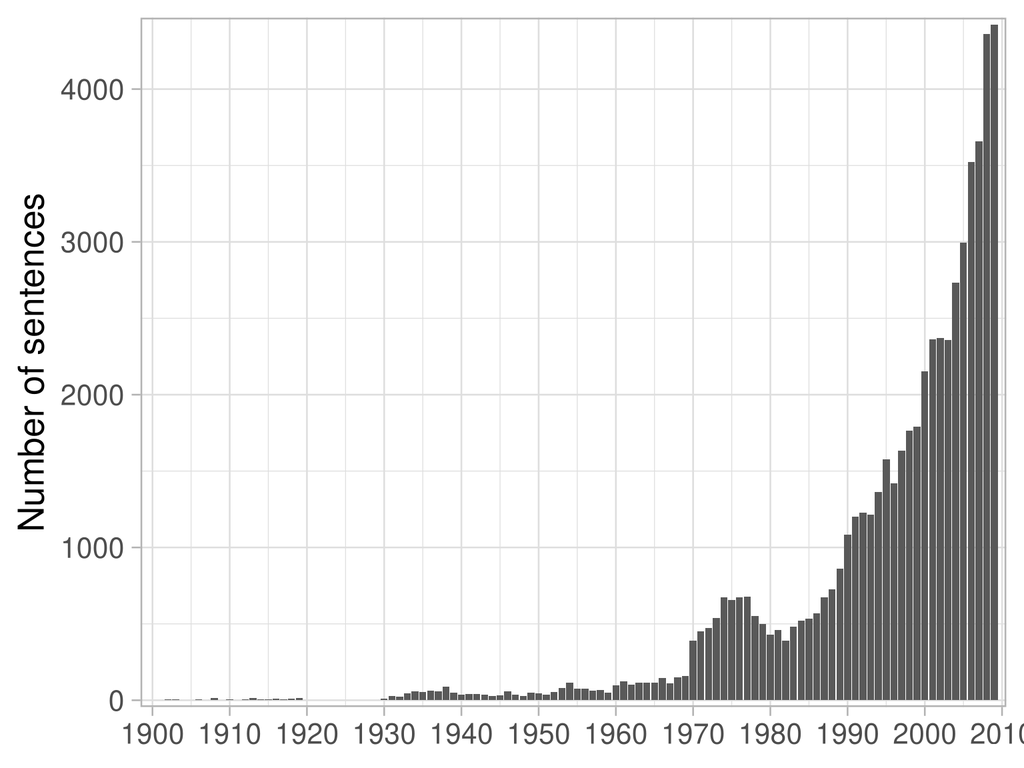

### Closest sentence from ‘rational’ and ‘rationality’ of the backbone community

| Sentence | Title | Year | Journal | Authors | Words Similarity |
| --- | --- | --- | --- | --- | --- |
| The assumption of a constant rate of discount is not merely sufficient to generate time-consistent choices; it may be implied by a certain type of rational reasoning. | [The Endogenous Determination of Time Preference](https://http://www.jstor.org/stable/2951254) | 1997 | The Quarterly Journal of Economics | Gary S. Becker, Casey B. Mulligan | 0.789 |
| l/ This concept of rationality must be considered from the viewpoint of the consumer in her economic and physical environment - not from the viewpoint of the market researcher with preconceived ideas … | [CONSUMER DECISION MAKING AND BUYING BEHAVIOUR](https://www.jstor.org/stable/10.2307/44012516) | 1959 | Proceedings of the Annual Meeting (Western Farm Economics Association) | C. Richard Creek | 0.777 |
| Rather, without committing to a specific decision procedure, we merely want to show that a familiar and very simple notion of rationality, based on a single preference relation, imposes restrictions o… | [Non-Deteriorating Choice](https://http://www.jstor.org/stable/40268922) | 2009 | Economica | Walter Bossert, Yves Sprumont | 0.777 |
| risk neutrality and rationality). | Design and evaluation of an economic experiment via the Internet | 2001 | Journal of Economic Behavior and Organization | Anderhub V. | 0.777 |
| With multiple rational preference types, not all ordinally alike, an interior rational expectation dynamic steady-state robustly emerges: It may be impossible to draw any clear inference from history … | [Pathological Outcomes of Observational Learning](https://http://www.jstor.org/stable/2999431) | 2000 | Econometrica | Lones Smith, Peter Sørensen | 0.776 |
| It follows that the same model can be used by both proponents and opponents of irrational behaviour as explanation of the equity-premium puzzle. | [Equity premium with distorted beliefs: A puzzle](https://doi.org/10.1016/j.jedc.2005.06.013) | 2006 | Journal of Economic Dynamics and Control | Misina M. | 0.772 |
| (e.g., ), we argue below that it would be fruitful to extend the analysis to include a salient feature and an implication of bounded rationality in dynamic decision-making that are not captured by the… | [Growth of strategy sets, entropy, and nonstationary bounded recall](https://doi.org/10.1016/j.geb.2008.04.005) | 2009 | Games and Economic Behavior | Neyman A. | 0.770 |
| The rationality hypothesis requires given preferences which are known in advance and regrouped according to the transitivity principle. | [A Critical Review of Strategic Conflict Theory and Socio-political Instability Models](https://http://www.jstor.org/stable/24703028) | 2009 | Revue d’économie politique | Mehrdad Vahabi | 0.769 |
| “Rationality” has been imputed to the consumer only in the sense that his preferences are assumed to be unambiguous and self-consistent. | [Professor Knight and the Theory of Demand](https://http://www.jstor.org/stable/1825792) | 1946 | Journal of Political Economy | Robert L. Bishop | 0.767 |
| Our formulation follows the standard economic interpretation of rationality in the sense that choices are based on a single binary relation. | [Weakened WARP and top-cycle choice rules](https://doi.org/10.1016/j.jmateco.2007.05.004) | 2008 | Journal of Mathematical Economics | Ehlers L. | 0.766 |
| Returning to the consumer and the observer from the previous section, and implies that if after having observed the consumer’s choices in K ′· N random examples the observed choices are rationalizable… | Learnability and rationality of choice | 2003 | Journal of Economic Theory | Kalai G. | 0.760 |
| The agents in this model are assumed to follow boundedly rational behavioral rules that incorporate the notions that there is inertia in consumer choices, and that they do not take into account the in… | [Herd behavior and the quality of opinions](https://doi.org/10.1016/j.socec.2003.10.004) | 2003 | Journal of Socio Economics | Teraji S. | 0.759 |
| Then there exists a choice function which is optimal-rational with respect to R. We have, thus, realized that rational behavior of individuals follows from very mild conditions imposed upon their pref… | [Rationality without Transitivity](https://http://www.jstor.org/stable/41795073) | 2003 | Journal of Economics | Susanne Fuchs-Seliger, Oliver Mayer | 0.758 |
| Rational choice is very permissive in some respects, i.e., we could see that economic rationality does not rule out extreme risk aversion in small gambles, although this attitude almost necessarily yi… | [Rational choice and irrational individuals or simply an irrational theory: A critical review of the hypothesis of perfect rationality](https://doi.org/10.1016/j.socec.2003.12.031) | 2005 | Journal of Socio Economics | Miljkovic D. | 0.756 |
| Bounded rationality Although the strong rationality assumptions underlying most models serve a useful purpose by providing a benchmark for the analysis of interest group politics, there is mounting em… | [On the Economic Theory of Interest Groups: Towards a Group Frame of Reference in Political Economics](https://http://www.jstor.org/stable/30026077) | 1999 | Public Choice | Frans van Winden | 0.754 |
| This paper addresses the question whether policy patterns described by the rational theory can emerge even if we do not assume that voters are rational. | A political business cycle with boundedly rational agents | 2001 | European Journal of Political Economy | Sieg G. | 0.752 |
| The Savage Paradigm A fuller sketch of the Savage paradigm of individual rational decision-making under uncertainty will be given in Section 3, but a few elements are needed here in order to introduce… | [Costly and Bounded Rationality in Individual and Team Decision-making](https://doi.org/10.1093/icc/9.4.623) | 2000 | Industrial and Corporate Change | Radner R. | 0.751 |
| We argued that for an agent who is discounting utility it may make sense to impose restrictions not only on the beliefs in the long run, as rationality would require, but also in the short run. | [On Some Topological Properties of Stable Measures](https://http://www.jstor.org/stable/25054986) | 1996 | Economic Theory | Carsten Krabbe Nielsen | 0.748 |
| Extensive form rationalizability: Until now, we have been reviewing rationality concepts that are either refinements or weakenings of preference conjecture equilibrium. | [Proper belief revision and equilibrium in dynamic games](https://doi.org/10.1016/j.jet.2006.06.008) | 2007 | Journal of Economic Theory | Perea A. | 0.748 |
| Given inertia in the political process, formation of expectations in a regressive and seemingly myopic fashion may, therefore, be entirely rational. | [Equilibrium Relationships between Money and Other Economic Variables](https://http://www.jstor.org/stable/1821359) | 1985 | The American Economic Review | James R. Lothian | 0.747 |
| Given the use of a logit model, for finite values of the “intensity of choice” parameter, agents are not fully rational in their choice, in the sense that not all use the model that provides the best … | [Heterogeneous expectations, sunspot equilibria and their fragility](https://doi.org/10.1016/j.econlet.2009.08.021) | 2009 | Economics Letters | Berardi M. | 0.747 |

### Closest sentences of the backbone community’s centroid

| Sentence | Title | Year | Journal | Authors | Similarity to Backbone Centroid |
| --- | --- | --- | --- | --- | --- |
| If we assume an added disutility associated with involvement in a risky and low probability choice, then the theory that people are maximising their utility is not overturned by these experiments. | [The hidden persuaders: institutions and individuals in economic theory](https://http://www.jstor.org/stable/23600366) | 2003 | Cambridge Journal of Economics | Geoffrey M. Hodgson | 0.823 |
| It is well known from the literature (beginning with Allais, 1953) that individual behavior in some situations is inconsistent with expected utility maximization. | Acquisition of costly information: An experimental study | 2001 | Journal of Economic Behavior and Organization | Rötheli T. | 0.819 |
| It is also of some interest to note that the model resulting from (2.2) and (6.1) is consistent with utility theory, and in fact embodies a naive version of the Random Utility Hypothesis (see, e.g., B… | Exact small-sample inference in stationary, fully regular, dynamic demand models | 2000 | Journal of Econometrics | Deschamps P.J. | 0.816 |
| The main achievement of Theorem 1 is to identify a set of preferences for which the attitudes toward uncertainty and risk are separated, in the sense that any (uncertain) belief function is treated li… | [Expected utility with lower probabilities](https://doi.org/10.1007/BF01065372) | 1994 | Journal of Risk and Uncertainty | Hendon E. | 0.816 |
| A not uncommon reaction to modifications of subjective expected utility that incorporate other features of distributions or utility dispersions is to argue that such features violate intuitively attra… | [A variational model of preference under uncertainty](https://doi.org/10.1007/BF01065369) | 1994 | Journal of Risk and Uncertainty | Fishburn P. | 0.813 |
| Then our assumption requires, first, that the diver sity of preferences be accounted for by a single parameter, and, second, that they can be ranked globally by decreasing dislike for risk. | [Identifying Preferences under Risk from Discrete Choices](https://http://www.jstor.org/stable/25592424) | 2009 | The American Economic Review | Pierre-André Chiappori, Amit Gandhi, Bernard Salanié, Francois Salanié | 0.812 |
| In this paper, it is argued that there may be reason to doubt whether individuals act as if they have complete and consistent preferences over risky actions. | [Explaining risky choices without assuming preferences](https://www.jstor.org/stable/10.2307/41106162) | 1996 | Social Choice and Welfare | Chris Starmer | 0.812 |
| Although our formal analysis focuses on this one specific source of decision utility deviating from experienced utility, we discuss in Section 6 the extent to which our conclusions hold in other behav… | [Optimal sin taxes](https://doi.org/10.1016/j.jpubeco.2006.03.001) | 2006 | Journal of Public Economics | O’Donoghue T. | 0.811 |
| If it is further assumed the citizen’s attitude toward uncertainty in this kind of situation makes him indifferent between different outcomes which have the same actuarial value,5 then a comparison of… | [Identification of Preference for Election Outcomes from Aggregate Voting Data](https://http://www.jstor.org/stable/30022894) | 1976 | Public Choice | Anthony J. Barkume | 0.810 |
| Comparing the optimal choices by two agents from any common set of risky alternatives, Mathews shows that (when his proposed definition can be applied) an agent that is more risk averse cannot optimal… | [Portfolio Selection with Quadratic Utility Revisited](https://www.jstor.org/stable/10.2307/41959168) | 2004 | The Geneva Papers on Risk and Insurance Theory | TIMOTHY MATHEWS | 0.809 |
| Apart from some properties already noted by the preceding authors, it allows changes in the direction of preferences in cases of extreme reduction of risk, as will be shown in Section 5of this paper. | Comonotonicity axioms and rank-dependent expected utility theory for arbitrary consequences | 1999 | Journal of Mathematical Economics | Chateauneuf A. | 0.806 |
| 11 Our distinction between ex ante perceived utility and realized utility and reference to the perceived ex ante disutility of an uncertain prospect means that people may be risk-averse independently … | A model of human nature and personal development | 1998 | Journal of Socio Economics | Ho L. | 0.806 |
| With the assumption of constant absolute risk aversion in the neighborhood of a given outcome level, however, it can be inferred that decision makers who prefer F(y) to G(y) are not less riskaverse th… | [An Interval Approach to Measuring Decision Maker Preferences](https://http://www.jstor.org/stable/1240542) | 1981 | American Journal of Agricultural Economics | Robert P. King, Lindon J. Robison | 0.805 |
| I conclude my remark on the works of Quiggin, Yaari, and Segal with a criticism from a normative, behavioristic point of view: It may seem conceptually inconsistent to postulate a decision maker who, … | [Subjective Probability and Expected Utility without Additivity](https://http://www.jstor.org/stable/1911053) | 1989 | Econometrica | David Schmeidler | 0.805 |
| One special example of this case has been considered by Shapiro and Miyao [1978], where all individuals will obtain a certain (common) utility level from each alternative after their choice is made, i… | [Discrete Choice and Variable Returns to Scale](https://http://www.jstor.org/stable/2526276) | 1981 | International Economic Review | Takahiro Miyao, Perry Shapiro | 0.804 |

### Closest sentences of each HDBSCAN cluster’s centroid composing the backbone community

| Sentence | Title | Year | Journal | Authors | Similarity to HDSBSCAN Centroid |
| --- | --- | --- | --- | --- | --- |
| The existence of interest would be alone sufficient to account for this; for if goods can be exchanged, and if present goods are worth more than future goods, the former would always be preferred, for… | [The Nature of Interest and the Causes of Its Fluctuations](https://http://www.jstor.org/stable/1884035) | 1917 | The Quarterly Journal of Economics | A. F. McGoun | 0.636 |
| It seems reasonably clear, then, that if a’ll the bidders in the market were men for whom the good bid upon and the gooid used in making payment had a direct personal and present use in consumption, p… | [The Demand and Supply Concepts: An Introduction to the Study of Market Price](https://http://www.jstor.org/stable/1817324) | 1906 | Journal of Political Economy | Robert F. Hoxie | 0.603 |
| Evidently, then, we must still further restrict the main proposition by stipulating that the comparison must not only be of the present as against the future worth of the good made at the time of post… | [The Demand and Supply Concepts: An Introduction to the Study of Market Price](https://http://www.jstor.org/stable/1817324) | 1906 | Journal of Political Economy | Robert F. Hoxie | 0.600 |
| Now it goes without saying that neither the rationalistic reactions of a multitude of individuals in the matter of saving, nor the behavioristic psychology of the masses as conditioned by social and e… | [Commercial Banking and Capital Formation: IV](https://http://www.jstor.org/stable/1822000) | 1918 | Journal of Political Economy | H. G. Moulton | 0.593 |
| Likewise, if we suppose him to lend to Crusoe, the rate at which he will lend is influenced directly by his other alternative, and not merely by his time-preference or by his other alternative acting … | [The Discount Versus the Cost-of-Production Theory of Capital Valuation](https://http://www.jstor.org/stable/1804713) | 1914 | The American Economic Review | Harry Gunnison Brown | 0.591 |
| On the other hand, if it could be established that the mere increase in private savings could bring about a result so desirable if the dictates of altruism and far-sighted selfishness could be shown t… | [The Taxation of Luxuries and the Rate of Interest](https://http://www.jstor.org/stable/1884736) | 1919 | The Quarterly Journal of Economics | A. F. McGoun | 0.590 |
| First of all, custom at any rate lends some warrant to the view that under existing circumstances the survival of the total sum set aside may itself be an object so long as it be linked with the possi… | [Some Considerations About Interest](https://http://www.jstor.org/stable/2221207) | 1908 | The Economic Journal | E. C. K. Gonner | 0.576 |
| For it is not necessarily true that a person values his capital at 100 only because, having an impatience of 20 per cent, he discounts the expected income at a 20 per cent rate. | [The Marginal Productivity Versus the Impatience Theory of Interest](https://http://www.jstor.org/stable/1883445) | 1913 | The Quarterly Journal of Economics | Harry G. Brown | 0.570 |
| This outcome is the more surprising because the phrase “preference for present income,” which sums up his explanation of interest, itself so clearly implies the thought that waiting for future income … | [The Impatience Theory of Interest](https://http://www.jstor.org/stable/1828193) | 1912 | The American Economic Review | Henry R. Seager | 0.568 |
| Likewise, the savers of a community, not being a homogeneous body as regards their motives and pecuniary circumstances, it is the marginal, not the total, effective desire of accumulation which govern… | [Böhm-Bawerk on Rae](https://http://www.jstor.org/stable/1881983) | 1902 | The Quarterly Journal of Economics | Charles W. Mixter | 0.568 |

| Sentence | Title | Year | Journal | Authors | Similarity to HDSBSCAN Centroid |
| --- | --- | --- | --- | --- | --- |
| “1 Fetter, in his latest book, not merely mentions the fact of impulsive action, but abandons the doctrine of marginal utility.2 Again, most of the negative contentions here put forward are most admir… | [Economics and Modern Psycholoy: I](https://http://www.jstor.org/stable/1820785) | 1918 | Journal of Political Economy | J. M. Clark | 0.575 |
| As Weston furthermore says, it is “strange that one who is par excellence a mathematical economist should find satisfaction in a theory based on a principle that does not even permit of an exact mathe… | [Progressive Taxation in Theory and Practice](https://www.jstor.org/stable/10.2307/3000009) | 1908 | American Economic Association Quarterly | E. R. A. Seligman | 0.571 |
| And, if it be admitted that economic choice is more frequently the outcome of habit, suggestion, and the like, than of a rationalistic weighing of alternative gratifications, the marginal-utility anal… | [The Futility of Marginal Utility](https://http://www.jstor.org/stable/1820794) | 1910 | Journal of Political Economy | E. H. Downey | 0.570 |
| 3 The relation is well expressed in the following passage, one of a large class of similar conclusions: “All that we have proved is that situations are possible in which a diminution in the falsity of… | [Recent Contributions to Mathematical Economics](https://http://www.jstor.org/stable/2222169) | 1915 | The Economic Journal | F. Y. Edgeworth | 0.566 |
| things being equal, afford increments of utility, the magnitude of each of which is independent of the total quantity of the comminodity that the individual may choose to take. | [Some Remarks on Utility](https://http://www.jstor.org/stable/2956866) | 1903 | The Economic Journal | A. C. Pigou | 0.553 |
| This crude reductio ad absurdum may serve to make the reader doubt whether the principle of equal proportional sacrifice of utility can be sound. | [The Utility of Income and Progressive Taxation](https://http://www.jstor.org/stable/2222207) | 1913 | The Economic Journal | S. J. Chapman | 0.552 |
| “What becomes of our reasoning as to marginal utility?” | [Seligman’s Principles of Economics: A Reply and a Rejoinder](https://http://www.jstor.org/stable/1883753) | 1906 | The Quarterly Journal of Economics | F. W. Taussig | 0.545 |
| As over against such a doctrine the conception of marginal utility, as the key to the relation between prices and wants, embodies a vital and important truth. | [Economic Theory in an Era of Social Readjustment](https://http://www.jstor.org/stable/1814006) | 1919 | The American Economic Review | J. M. Clark | 0.540 |
| This he calls the economic principle of equivalence.24 But as we have seen that the marginal utility varies inversely as the amoount, the marginal utility of the commodities taken from two unequally w… | [Progressive Taxation in Theory and Practice](https://www.jstor.org/stable/10.2307/3000009) | 1908 | American Economic Association Quarterly | E. R. A. Seligman | 0.537 |
| Some of the defences of the doctrine that the marginal utility of money must always be less for the larger than for the smaller income are, it would seem, less impregnable than they appear at first si… | [The Utility of Income and Progressive Taxation](https://http://www.jstor.org/stable/2222207) | 1913 | The Economic Journal | S. J. Chapman | 0.535 |

| Sentence | Title | Year | Journal | Authors | Similarity to HDSBSCAN Centroid |
| --- | --- | --- | --- | --- | --- |
| … We should have to keep a strong hold on ourselves, or we should soon be finding some indirect way of talking about one marginal utility by itself-or, what is equally indefensible, talking about the … | [The End of the Marginal Utility Theory?](https://http://www.jstor.org/stable/2549021) | 1938 | Economica | H. Bernardelli | 0.681 |
| This point may be clarified by considering the view put forward by some utility-theorists that utility is some quality observable by introspection as quantitative, and choice is determined by this qua… | [The Determinateness of the Utility Function](https://http://www.jstor.org/stable/2224802) | 1939 | The Economic Journal | W. E. Armstrong | 0.680 |
| This difficulty is not peculiar to the theory of marginal utility. | [Annual Survey of Economic Theory: The Setting of the Central Problem](https://http://www.jstor.org/stable/1905243) | 1936 | Econometrica | Johan Åkerman | 0.667 |
| the other hand those are mistaken who, according to pattern (II, III), either try their wits on the hopeless task of measuring utility in spite of its immeasurability or resign in proposing those port… | [The End of the Marginal Utility Theory?](https://http://www.jstor.org/stable/2549021) | 1938 | Economica | H. Bernardelli | 0.661 |
| One answer to this question points to the much debated problem of the measurability of utility. | [Composite Commodities and the Problem of Index Numbers](https://http://www.jstor.org/stable/1907120) | 1936 | Econometrica | Wassily Leontief | 0.658 |
| Using the second postulate thus imposes a very serious restriction upon economic theory, because to subject the choice of the utility index function to the condition F” == o is equivalent to treating … | [The End of the Marginal Utility Theory?](https://http://www.jstor.org/stable/2549021) | 1938 | Economica | H. Bernardelli | 0.654 |
| When we seek to translate the principle of diminishing marginal utility into definable terms, it does not appear at first sight evident that this is the condition we must use. | [A Reconsideration of the Theory of Value. Part I](https://http://www.jstor.org/stable/2548574) | 1934 | Economica | J. R. Hicks, R. G. D. Allen | 0.653 |
| This leads us to a consideration of the postulates used for constructing the utility function and to the kind of indetermninateness these postulates result in. | [The Determinateness of the Utility Function](https://http://www.jstor.org/stable/2967485) | 1934 | The Review of Economic Studies | O. Lange | 0.648 |
| The deeper meaning of this assumption cannot be discussed here; we are certainly not suggesting that any independent criterion for testing maximum satisfaction is available other than the actual behav… | [A Development of the Economic Theory of Price Index Numbers](https://http://www.jstor.org/stable/2967585) | 1935 | The Review of Economic Studies | H. Staehle | 0.648 |
| which as motives or impulses of an individual are the essential factors that determine his choice it would be possible to introduce these immeasurable psychological magnitudes into the equations of eq… | [The End of the Marginal Utility Theory?](https://http://www.jstor.org/stable/2549021) | 1938 | Economica | H. Bernardelli | 0.647 |

| Sentence | Title | Year | Journal | Authors | Similarity to HDSBSCAN Centroid |
| --- | --- | --- | --- | --- | --- |
| When these conditions are satisfied, we may be reasonably certain that the market behavior of the consumers in question is consistent or rational. | [Interrelations of Demand](https://http://www.jstor.org/stable/1823046) | 1933 | Journal of Political Economy | Henry Schultz | 0.582 |
| Or we discover that, given enough time for adjustment, virtually all consumer’s preferences are irrational. | [Rational and Irrational Consumer Preference](https://http://www.jstor.org/stable/2224960) | 1938 | The Economic Journal | J. K. Galbraith | 0.580 |
| The point is, however, that the answers called for by (57b) do not require a comparison of final utilities and may be obtained by observing the individual’s market behavior; whereas the answers called… | [Interrelations of Demand, Price, and Income](https://http://www.jstor.org/stable/1822950) | 1935 | Journal of Political Economy | Henry Schultz | 0.572 |
| outlays about which no short-run decisions are made - commitments; it should treat the sometimes large category of purchases made with conscious irrationality - petty goods; and should differentiate s… | [The Analysis of Demand](https://http://www.jstor.org/stable/1882490) | 1939 | The Quarterly Journal of Economics | Ruby Turner Norris | 0.571 |
| In so far as he acts rationally, the consumer will estimate the relative importance to himself of any unit of a good by the relative importance of the use he would have to sacrifice if he were to lose… | [Collected Works of Carl Menger](https://http://www.jstor.org/stable/1891101) | 1936 | The Quarterly Journal of Economics | Alan R. Sweezy | 0.569 |
| It is well known that the utility derived from the expenditure of a given sum of money may vary widely from that which was anticipated. | [Recent and Contemporary Theories of Progressive Taxation](https://http://www.jstor.org/stable/1824777) | 1938 | Journal of Political Economy | Elmer D. Fagan | 0.567 |
| To the extent that consumers are rational and well informed, and to the extent that they are free to spend their money as they choose, this assumption must be correct. | [The Marginal Utility of Money in the United States from 1917 to 1921 and from 1922 to 1932](https://http://www.jstor.org/stable/1905630) | 1935 | Econometrica | Frederick V. Waugh | 0.562 |
| But only when the factors which determine the length of the economic period2 are given can we say that the system of wants is given. | [The Rôle of Time in Economic Theory](https://http://www.jstor.org/stable/2548575) | 1934 | Economica | P. N. Rosenstein-Rodan | 0.557 |
| At the most our rationality at such moments extends only to a conscious comparison of our momentary desire to consume with a vague recognition of our general financial situation. | [Some Problems of Price Maintenance](https://http://www.jstor.org/stable/2225476) | 1938 | The Economic Journal | T. H. Silcock | 0.555 |
| Hence a preference which was rational when the customer was transferred from one seller to another, becomes irrational when some time is allowed to elapse; we reach the charming but not -very useful r… | [Rational and Irrational Consumer Preference](https://http://www.jstor.org/stable/2224960) | 1938 | The Economic Journal | J. K. Galbraith | 0.551 |

Sentence

Title

Year

Journal

Authors

Similarity to HDSBSCAN Centroid

If for the definitions on which that proposition was based, we substitute the definition of ex ante investment given above, it is true that if ex ante investment exceeds saving, the system will be stimulated, and conversely.

[An Essay in Dynamic Theory](https://http://www.jstor.org/stable/2225181)

1939

The Economic Journal

R. F. Harrod

0.613

Thus to each level of output, there corresponds a certain rate of saving, which must be imagined to occur if that level of output is imagined to obtain.

[The long-period theory of employment](https://http://www.jstor.org/stable/41793119)

1936

Zeitschrift für Nationalökonomie / Journal of Economics

Joan Robinson

0.598

In fact, the normal situation would seem to require that the (discounted) flow of potential satisfactions represented by the investment should more than cancel the loss in immediate satisfaction entailed by the saving, in order that there be an incentive (other than fear, which cannot operate perennially) for the saving.

[Dynamic Theory of Saving and Investment](https://http://www.jstor.org/stable/3693801)

1938

Southern Economic Journal

Montgomery D. Anderson

0.595

2 It is interesting to note that the assumption that savings are largely a func.

[Prof. Pigou on Money Wages in Relation to Unemployment](https://http://www.jstor.org/stable/2225349)

1937

The Economic Journal

J. M. Keynes, Nicholas Kaldor

0.592

And in so far as the conclusions are determined by the variant assumptions as to the type of saving and investment underlying the respective theories, they are not really contradictory to each other.

[Saving, Investment, and Crisis](https://http://www.jstor.org/stable/1824545)

1935

Journal of Political Economy

Walter Egle

0.591

1. Suppose that on day 1 our man spends the whole of his ?10 on consumption, and is therefore not saving; but suppose that other people add to the flow of money expended on that day, thus competing with him for the flow of goods coming forward for sale and driving up their price, so that his ?10 buys 8 units of goods instead of 10.

[Saving and Hoarding](https://http://www.jstor.org/stable/2224283)

1933

The Economic Journal

D. H. Robertson

0.590

For example a discontinuous increase of productivity which was itself general might lead to discontinuous changes in the volume of saving and in the rate of interest; and a sharp fall in the volume of saving or rise in the rate of interest might well produce a general falsification of prior expectations, and a crisis.

[Neutral Money and the Trade Cycle](https://http://www.jstor.org/stable/2548720)

1935

Economica

Harold Barger

0.588

What, with one set of postulates, is called differentiating against savings might, with another set, be called not differentiating in favour of them.

[Taxation of Savings: A Reply](https://http://www.jstor.org/stable/2548656)

1937

Economica

A. C. Pigou

0.587

(That I meant it in this sensedis obvious from the fact that I quoted this paragraph against Mr. Keynes in my Rejoinder to his Reply to 1 I need not go into the other supposed ” modification ” of my theory which Mr. Sraffa mentions in this connection, as it ought to be obvious that the case in which the amounts saved are not invested is a case of a change in the velocity of circulation; i.e.

[Money and Capital: A Reply](https://http://www.jstor.org/stable/2223821)

1932

The Economic Journal

F. A. von Hayek

0.583

Some of these factors are accounted for by different assumptions with respect to the form of saving and investment.

[Saving, Investment, and Crisis](https://http://www.jstor.org/stable/1824545)

1935

Journal of Political Economy

Walter Egle

0.581

Sentence

Title

Year

Journal

Authors

Similarity to HDSBSCAN Centroid

We might employ Marshall’s subterfuge and say that the summation and averaging process does give us a result that is close to what each consumer would do if he were rational and in adjustment.

[Can We Measure the Marginal Utility of Money?](https://http://www.jstor.org/stable/1907011)

1945

Econometrica

James N. Morgan

0.673

It is, indeed, only in very exceptional cases that an individual planning his consumption feels absolutely certain in his anticipation of a price or interest rate or income which is going to prevail in the future.

[A Contribution to the Non-Static Theory of Choice](https://http://www.jstor.org/stable/1881933)

1942

The Quarterly Journal of Economics

Gerhard Tintner

0.645

“Rationality” has been imputed to the consumer only in the sense that his preferences are assumed to be unambiguous and self-consistent.

[Professor Knight and the Theory of Demand](https://http://www.jstor.org/stable/1825792)

1946

Journal of Political Economy

Robert L. Bishop

0.641

Under this condition any rational person must prefer present to future wealth, as has been pointed out many times.

[Professor Mises and the Theory of Capital](https://http://www.jstor.org/stable/2550107)

1941

Economica

F. H. Knight

0.636

It is possible to give an alternative representation of consumer’s surplus, which is not dependent on this assumption.

[Rationing and Index Numbers](https://http://www.jstor.org/stable/2967497)

1942

The Review of Economic Studies

J. L. Nicholson

0.598

Also, even if the consumer can be assumed to maximize utility for the ranges of incomes and prices with which he is familiar, he may still behave unpredictably under other conditions.

[Professor Knight and the Theory of Demand](https://http://www.jstor.org/stable/1825792)

1946

Journal of Political Economy

Robert L. Bishop

0.597

If the mechanism of this change were fully understood and if the results of different (future) types of consumer appeal were even moderately predictable, uncertainty for the producer might become a negligible risk.

[Cartels, Combinations and the Public Interest](https://http://www.jstor.org/stable/1232111)

1944

Journal of Farm Economics

F. B. Garver

0.579

Furthermore, even assuming that all of these other factors are known and can be measured, it is extremely doubtful whether we may postulate the existence of an exact consumption function.3 Such an assumption is equivalent to saying that individuals always react in exactly the same (known) fashion under similar (known) sets of circumstances.

[The Role of Econometric Models in Economic Research](https://http://www.jstor.org/stable/1232684)

1948

Journal of Farm Economics

Gershon Cooper

0.568

On the other hand, the theory is based on the concept of an indifference system of the consumer which is independent of prices, whilst the usefulness of money lies in its purchasing power and depends on the price level.

[The Consumer’s Demand for Money](https://http://www.jstor.org/stable/1909263)

1943

Econometrica

C. E. V. Leser

0.566

3. More important than the deflating indexes and the assumption of independence of utility, is the assumption that tastes are identical, consumption varying in response to differing opportunities, i.e., different prices and incomes.

[Can We Measure the Marginal Utility of Money?](https://http://www.jstor.org/stable/1907011)

1945

Econometrica

James N. Morgan

0.563

#### Closes sentences 2_1_1900-1919: postponement, saving, lessened, save, postponed (1940-1949)

| Sentence | Title | Year | Journal | Authors | Similarity to HDSBSCAN Centroid |
| --- | --- | --- | --- | --- | --- |
| The classical economists’ assumption that men save solely 1 So long as these two assumptions are consistent, and their consistency implies a restriction of the problem to stationary conditions, or to … | [Types of Competition and the Theory of Employment](https://http://www.jstor.org/stable/2661941) | 1949 | Oxford Economic Papers | B. R. Williams | 0.685 |
| It has further been shown that the introduction of saving into the picture may modify this result and that irrationality of individual decisions could also do so. | [The Case for Indirect Taxation](https://http://www.jstor.org/stable/2226177) | 1948 | The Economic Journal | A. Henderson | 0.670 |
| They can scarcely hope to refute altogether the new theories of speculation and to show that the supply of investible funds to industry is solely determined by the action of savers, so that savings au… | [Capital Theory and the Trade Cycle](https://http://www.jstor.org/stable/2967404) | 1940 | The Review of Economic Studies | Tom Wilson | 0.664 |
| If, however, we make the assumption that there is a direct relation between the propensity to consume and the real value of assets (a questionable assumption at best, but one necessary to Friedman’s a… | [Professor Friedman’s Proposal: A Comment](https://http://www.jstor.org/stable/1810492) | 1949 | The American Economic Review | Philip Neff | 0.660 |
| “4 The correctness of the first statement may be granted; but the second does not necessarily follow.5 My analysis is implicitly based on the same logic by which Keynes came to the conclusion that sav… | [Professors Pritchard and Benoit-Smullyan on Bank-Financed Functional Deficits: A Reply](https://http://www.jstor.org/stable/1810635) | 1948 | The American Economic Review | J. Carl Poindexter | 0.656 |
| A stable propensity to save, to be indicated by a, again need not imply a permanent constancy; it could also be made a function of certain variables. | [The Problem of Capital Accumulation](https://http://www.jstor.org/stable/1811691) | 1948 | The American Economic Review | Evsey D. Domar | 0.645 |
| In view of the prevailing tenor of current discussion, it seems important to insist that there is little relation between the hoarding that is causally important and any change in intention to save; t… | [Heimann’s History of Doctrine and Current Issues](https://http://www.jstor.org/stable/1827066) | 1946 | Journal of Political Economy | Frank H. Knight | 0.644 |
| Even though it be granted that the fundamental analysis is sound with respect to the importance of a balance between saving and investment in the Keynesian sense, and the necessity for maintaining or … | [Divergent Theories of National Debt](https://http://www.jstor.org/stable/1052594) | 1946 | Southern Economic Journal | W. O. Suiter | 0.640 |
| But this is not to agree with the Keynesian tenet that any net saving automatically decreases investment and income,3 nor to agree with Lange that saving over an “optimum rate” has these effects.4 The… | [Monetary Policy and Investment](https://http://www.jstor.org/stable/1814478) | 1940 | The American Economic Review | Howard S. Ellis | 0.638 |
| It does not seem contrary to reality, therefore, to assume that a change in the level of income alters anticipations either on the part of dynamic investors or on the part of consumers. | [A Model of the Forty-Month or Trade Cycle](https://http://www.jstor.org/stable/1825433) | 1942 | Journal of Political Economy | Joshua C. Hubbard | 0.630 |

| Sentence | Title | Year | Journal | Authors | Similarity to HDSBSCAN Centroid |
| --- | --- | --- | --- | --- | --- |
| “63 One cannot disagree with this statement any more than with the statement that the price of butter measures the marginal utility of butter to each member of the community.64 Both statements are eit… | [Liquidity Preference and the Theory of Interest and Money](https://http://www.jstor.org/stable/1905567) | 1944 | Econometrica | Franco Modigliani | 0.657 |
| It is not difficult to perceive herein the fundamental idea of the theory of marginal utility. | [Jeremy Bentham as an Economist](https://http://www.jstor.org/stable/2225988) | 1946 | The Economic Journal | W. Stark | 0.652 |
| 18 It may also be added that diminishing marginal utility, shown here to be no necessary condition of normal consumer behavior, is not a sufficient condition either. | [Professor Knight and the Theory of Demand](https://http://www.jstor.org/stable/1825792) | 1946 | Journal of Political Economy | Robert L. Bishop | 0.628 |
| He assumes that because one never has, he believes, any reason whatever to suppose that A has more or less capacity for satisfaction than B, it is equally probable that a shift of money from A to B, w… | [The Foundations of Welfare Economics](https://http://www.jstor.org/stable/2661708) | 1949 | Oxford Economic Papers | I. M. D. Little | 0.628 |
| 8 It is interesting to note that measurability of utility is implied for an unambiguous solution. ’ | [The Theory of Choice Under Subjective Risk and Uncertainty](https://http://www.jstor.org/stable/1907198) | 1941 | Econometrica | Gerhard Tintner | 0.626 |
| cost of sacrifices by some without requiring the interpersonal judgment that the loss in utility by those who sacrifice is less than the gain in utility by those who gain was immediately pointed out b… | [Recent Developments in the Theory of Marginal Cost Pricing](https://http://www.jstor.org/stable/2295868) | 1949 | The Review of Economic Studies | Nancy Ruggles | 0.616 |
| The nature of our utility unit not only prohibits rigorous interpersonal comparisons of utility; it also restricts the intertemporal comparisons for one individual to the case where we can assume that… | [Consumer’s Surplus and Cardinal Utility](https://http://www.jstor.org/stable/1881755) | 1943 | The Quarterly Journal of Economics | Robert L. Bishop | 0.613 |
| Certain assumptions .have to be made about human satisfactions. | [Welfare Economics and Economic Policy](https://http://www.jstor.org/stable/2549766) | 1946 | Economica | A. Radomysler | 0.610 |
| Every valuation is a comparison; we have no conception of an absolute utility or an absolute 21 As mentioned above (p. I4I), when a consumer’s tastes are consistent with the assumption of independent … | [Professor Knight and the Theory of Demand](https://http://www.jstor.org/stable/1825792) | 1946 | Journal of Political Economy | Robert L. Bishop | 0.607 |
| The characterisation of utility as measurable achieves more status; some fifteen pages are given over to discussion of it, and it is even formalised in a set of postulates. | [A Revolution in Economic Theory?](https://http://www.jstor.org/stable/2295753) | 1946 | The Review of Economic Studies | Carl Kaysen | 0.604 |

| Sentence | Title | Year | Journal | Authors | Similarity to HDSBSCAN Centroid |
| --- | --- | --- | --- | --- | --- |
| Either of these principles finds in (VII.2) an intuitive economic interpretation.5- Looked at from another angle, (VII.2) constitutes a straightforward generalization of the crude principle of decreas… | [A Diagrammatic Analysis of Complementarity](https://http://www.jstor.org/stable/1053966) | 1952 | Southern Economic Journal | Nicholas Georgescu-Roegen | 0.681 |
| ’The author, having so far kept his opinions submerged, is unable to avoid remarking that it would seem “better” to confine utility “theory” to attempts to explain or discern why a person chooses one … | [The Meaning of Utility Measurement](https://http://www.jstor.org/stable/1810289) | 1953 | The American Economic Review | Armen A. Alchian | 0.676 |
| Utility is “measurable” for one purpose but not for the other.9 s Some problems involved in this assumption and in its relaxation are discussed by N. Geogescu-Roegen, “The Theory of Choice and the Con… | [The Meaning of Utility Measurement](https://http://www.jstor.org/stable/1810289) | 1953 | The American Economic Review | Armen A. Alchian | 0.673 |
| ’8 Thus not only in early writings but even in later ones, we find this principle assumed jointly with the weak principle of decreasing marginal utility, at times without any support, at others, painf… | [A Diagrammatic Analysis of Complementarity](https://http://www.jstor.org/stable/1053966) | 1952 | Southern Economic Journal | Nicholas Georgescu-Roegen | 0.672 |
| It is dependent upon the particular combination of entities; i.e., we do not postulate that the utility of one sure element in a group of sure things is independent of what other entities are included… | [The Meaning of Utility Measurement](https://http://www.jstor.org/stable/1810289) | 1953 | The American Economic Review | Armen A. Alchian | 0.667 |
| We may assume for the moment in the following that the utility for different individuals could be compared and that utility can be cardinally measured. | [Some Problems of Income Determination and Welfare](https://http://www.jstor.org/stable/41796010) | 1959 | Zeitschrift für Nationalökonomie / Journal of Economics | Walter Froehlich | 0.667 |
| In these theories it is argued that a change of the scale of measurement of utility, such as a change from dollars to cents, should not alter the strategic considerations of rational players. | [The Determination of Subjective Characteristic Functions in Games with Misperceived Payoff Functions](https://http://www.jstor.org/stable/1905749) | 1956 | Econometrica | R. Duncan Luce, Ernest W. Adams | 0.665 |
| Taking utility in the sense of “desiredness,” the measurement of utility can be achieved only if some restrictive assumptions can be made regarding the preferences, as manifested by the behavior, of i… | [A Cardinal Concept of Welfare](https://http://www.jstor.org/stable/1885309) | 1952 | The Quarterly Journal of Economics | Marcus Fleming | 0.662 |
| the subject of explaining once more the rationale of the measurability of utility. | [Choice, Expectations and Measurability](https://http://www.jstor.org/stable/1881875) | 1954 | The Quarterly Journal of Economics | Nicholas Georgescu-Roegen | 0.659 |
| This illicit assumption alone is responsible for the dilemma: either to abandon the marginal utility theory, or to postulate measurability of utility. | [Comment on Mr. Lancaster’s “Refutation”](https://http://www.jstor.org/stable/2551322) | 1954 | Economica | Harro Bernardelli | 0.659 |

| Sentence | Title | Year | Journal | Authors | Similarity to HDSBSCAN Centroid |
| --- | --- | --- | --- | --- | --- |
| They suggest that preferences and indifferences are to be found not between alternatives but between the probabilities (including certainty) of alternatives. | [Utility and the “Ordinalist Fallacy”](https://http://www.jstor.org/stable/2295985) | 1958 | The Review of Economic Studies | W. E. Armstrong | 0.789 |
| Various strength of preference situations can be assumed. | [On Consumer Grades for Foods](https://http://www.jstor.org/stable/1234489) | 1956 | Journal of Farm Economics | V. James Rhodes, Elmer R. Kiehl | 0.779 |
| 2 The cited works of Houthakker, Little, and myself show that revealed preference theory in its narrow sense can identify regular situations that are indifferent only by an infinite sequence of compar… | [Consumption Theorems in Terms of Overcompensation Rather Than Indifference Comparisons](https://http://www.jstor.org/stable/2550984) | 1953 | Economica | Paul A. Samuelson | 0.771 |
| In this last connexion it will be noted that the consistency assumption, as, indeed, the whole method of deriving the indifference curve on the above basis, involves a certain stretching of the meanin… | [The Common Sense of Indifference Curves](https://http://www.jstor.org/stable/2661752) | 1950 | Oxford Economic Papers | Charles Kennedy | 0.769 |
| As mentioned in my Appendix, much of the problem about the specification of preference scales under intransitivity of indifference depends on whether finitude of levels of discretion (and welfare) is … | [Marginal Preference and the Theory of Welfare](https://http://www.jstor.org/stable/2662128) | 1953 | Oxford Economic Papers | Jerome Rothenberg | 0.766 |
| Evidently, those who believe in preferential sets have extended the meaning of the term preference so as to include not only preference, in the above sense, but a relation between alternatives that is… | [Utility and the “Ordinalist Fallacy”](https://http://www.jstor.org/stable/2295985) | 1958 | The Review of Economic Studies | W. E. Armstrong | 0.765 |
| We postulate that an individual behaves consistently, i.e., he has a consistent set of preferences; that these preferences are transitive, i.e., if B is preferred to A, and C to B, then C is preferred… | [The Meaning of Utility Measurement](https://http://www.jstor.org/stable/1810289) | 1953 | The American Economic Review | Armen A. Alchian | 0.764 |
| In a recent article’ Mr. Little attempts to construct a theory of choice on the basis of revealed preference, but without the explicit assumption of a complete ordering by preference of all alternativ… | [A Note on the Theory of Consumer’s Behaviour](https://http://www.jstor.org/stable/2661751) | 1950 | Oxford Economic Papers | W. E. Armstrong | 0.764 |
| Even when there can be more than two observations, we may interpret ‘preference’ and ‘indifference’ operationally only on the basis of a procedural resolution, because how many observations constitute… | [Behaviourist Cardinalism in Utility Theory](https://http://www.jstor.org/stable/2550691) | 1958 | Economica | Tapas Majumdar | 0.754 |
| He has shown that if a choice is to be made from among more than two alternatives, we cannot, in general, construct a social welfare function that could be regarded as a true representation of individ… | [The State of Welfare Economics](https://http://www.jstor.org/stable/1802104) | 1951 | The American Economic Review | Tibor Scitovsky | 0.752 |

| Sentence | Title | Year | Journal | Authors | Similarity to HDSBSCAN Centroid |
| --- | --- | --- | --- | --- | --- |
| Very pure, in the hands of the dominant schools, has this theory now become-little more, indeed, than an attempt to express the logical implications of the assumption that the consumer acts consistent… | [Utility and All What?](https://http://www.jstor.org/stable/2228037) | 1954 | The Economic Journal | D. H. Robertson | 0.689 |
| However, the results obtained by Hotelling [5], on which Wald’s argument depends cannot be deduced from the requirement that consumers choose consistently. | [On Equilibrium in Graham’s Model of World Trade and Other Competitive Systems](https://http://www.jstor.org/stable/1907539) | 1954 | Econometrica | Lionel McKenzie | 0.681 |
| And, however that may be, the assumption of independence made here would seem to be fruitful in that it suggests the possibility of defining rather specific interrelations of market demand, provided o… | [On the Independence of Utility of Product Groups](https://http://www.jstor.org/stable/1926511) | 1956 | The Review of Economics and Statistics | G. Warren Nutter | 0.672 |
| It is, however, possible to avoid this conflict and still have a consistent theory of consumer’s choice, such as that presented here. | [Choice, Expectations and Measurability](https://http://www.jstor.org/stable/1881875) | 1954 | The Quarterly Journal of Economics | Nicholas Georgescu-Roegen | 0.666 |
| One might think of avoiding such an uncomfortable conclusion by assuming that the consumer will not decide upon his ultimate equilibrium before trying out all combinations compatible with the budget r… | [The Theory of Choice and the Constancy of Economic Laws](https://http://www.jstor.org/stable/1881962) | 1950 | The Quarterly Journal of Economics | Nicholas Georgescu-Roegen | 0.658 |
| Buyers’ preferences of an irrational kind (in so far as they would pay more for the product of the business to which they were thus sentimentally attached than the price at which they could get an ide… | [Some Aspects of Competition in Retail Trade](https://http://www.jstor.org/stable/2662135) | 1950 | Oxford Economic Papers | P. W. S. Andrews | 0.657 |
| If one now assumes the opposite extreme; i.e., that all characteristics are taken into consideration but subject to error, it can be shown that the consumer will again tend to behave in a manner custo… | [A Probabilistic Theory of Consumer Behavior](https://http://www.jstor.org/stable/1881863) | 1956 | The Quarterly Journal of Economics | Richard E. Quandt | 0.652 |
| Thus if the consumer makes a particular choice on the basis of a particular set of characteristics, and the results of the choice do not make him wish he had chosen differently, he is likely to base h… | [A Probabilistic Theory of Consumer Behavior](https://http://www.jstor.org/stable/1881863) | 1956 | The Quarterly Journal of Economics | Richard E. Quandt | 0.652 |
| feel certainty about the effects of a change in tastes (quantity demanded), rather than because the conditions for dynamic stability indicate a price rise. | [Professor Samuelson on Operationalism in Economic Theory](https://http://www.jstor.org/stable/1882155) | 1955 | The Quarterly Journal of Economics | Donald F. Gordon | 0.647 |
| “4 If in fact A is more expensive than B when the consumer buys A then the second possibility is ruled out-our consumer must have bought A because he actually prefers it to B. | [Activity Analysis in One Lesson](https://http://www.jstor.org/stable/1808153) | 1958 | The American Economic Review | William J. Baumol | 0.646 |

| Sentence | Title | Year | Journal | Authors | Similarity to HDSBSCAN Centroid |
| --- | --- | --- | --- | --- | --- |
| Such an assumption does not imply that the decision-maker must have to be a pessimist, since degrees of risk-aversion are adequately reflected by the parmeters p*. | [On Decisions Under Uncertainty](https://http://www.jstor.org/stable/2229455) | 1965 | The Economic Journal | José Encarnación, Jr. | 0.659 |
| We will see later that this identification of the market price of risk in terms of investor’s risk aversions continues to be valid in spite of divergent expectations and when there is no risk asset. | [The Aggregation of Investor’s Diverse Judgments and Preferences in Purely Competitive Security Markets](https://doi.org/10.2307/2330056) | 1969 | Journal of Financial and Quantitative Analysis | Lintner J. | 0.650 |
| a world of uncertain price levels.4 Moreover, a useful theory of individual risk taking cannot be limited to the problem of asset choice.5 If the analysis is extended to occupational and other economi… | [The Effects of Taxation on Risk Taking](https://http://www.jstor.org/stable/1829965) | 1969 | Journal of Political Economy | Martin S. Feldstein | 0.648 |
| The results themselves, however, are in no way dependent on any special assumptions with respect to risk or “risk aversion”; and readers wlho find our rationalization in terms of these categories unsa… | [Some Estimates of the Cost of Capital to the Electric Utility Industry, 1954-57](https://http://www.jstor.org/stable/1823774) | 1966 | The American Economic Review | Merton H. Miller, Franco Modigliani | 0.635 |
| Nonetheless, the authors intuitively feel that it is plausible to hold that uncertainty can give rise to risk under certain conditions. | [The Meaning of Risk](https://www.jstor.org/stable/10.2307/250861) | 1967 | The Journal of Risk and Insurance | Ronald C. Horn, Robert M. Crowe | 0.628 |
| But the author shows that this assumption combined with the “expected utility” doctrine has rather implausible implications: the combination implies that the risk aversion increases with increasing fo… | [Tõnu Puu’s Studies in the Theory of Optimal Choice of Assets](https://www.jstor.org/stable/10.2307/3438768) | 1964 | Ekonomisk Tidskrift | Harald Dickson | 0.627 |
| It has, however, been argued by Arrow that in general such a degree of risk-aversion is necessary if the expected utility hypothesis is to be consistent. | [Uncertainty and the “Expectations Hypothesis”](https://http://www.jstor.org/stable/2296557) | 1967 | The Review of Economic Studies | H. A. John Green | 0.618 |
| The importance of the possibility of plunging behavior on the part of risk averters depends mainly upon whether the particular underlying forms of U(R) and f(R) are economically realistic. | [On the Risk-Return Trade-off in the Valuation of Assets](https://doi.org/10.2307/2330061) | 1969 | Journal of Financial and Quantitative Analysis | Adler M. | 0.617 |
| Under this interpretation, f is not as autonomous or structural a function as under the indifference-map interpretation, but it still would provide information about the relationship between risk and … | [A Peek at the Tradeoff Relationship Between Expected Return and Risk](https://http://www.jstor.org/stable/1884810) | 1967 | The Quarterly Journal of Economics | Robert Summers | 0.614 |
| Alternatively, economic decision making under risk carries forward to include uncertainty, but does not work backward.’ | [A General Theory of Maximum Profits](https://http://www.jstor.org/stable/1055444) | 1962 | Southern Economic Journal | Melvin L. Greenhut | 0.607 |

| Sentence | Title | Year | Journal | Authors | Similarity to HDSBSCAN Centroid |
| --- | --- | --- | --- | --- | --- |
| 10 It is also arguable that it is more realistic to assume that consumers have only a local knowedge of their indifference maps (and are therefore content to rest at a local maximum) than to make the … | [On Convexity, Efficiency, and Markets: A Reply](https://http://www.jstor.org/stable/1828538) | 1961 | Journal of Political Economy | M. J. Farrell | 0.664 |
| 2 Hansen distinguishes this concept from ” optimum purchases “, which include all purchases that would be rational to make, but some of which may not lead to orders since the orders are known to be di… | [A Theory of the Wage-Price Process in Modern Industry](https://http://www.jstor.org/stable/2295899) | 1964 | The Review of Economic Studies | Otto Eckstein | 0.663 |
| In this section and the next, we suppose that the individual can reconsider his consumption plan at only a finite number of ” decision points ” which are specified in advance. | [Consistent Planning](https://http://www.jstor.org/stable/2296548) | 1968 | The Review of Economic Studies | R. A. Pollak | 0.656 |
| The corresponding concept of a Parefo-optimum would therefore be based not on overt preferences but rather on a normalised set of consumer preferences adjusted for the effects of both ignorance and ir… | [Merit Goods Revisited](https://http://www.jstor.org/stable/40910613) | 1969 | FinanzArchiv / Public Finance Analysis | John G. Head | 0.646 |
| Consumer behavior as just described differs markedly from traditional economic theory in that the latter maintains that the consumer will always choose one particular alternative (that which is “most … | [A Programmed Solution for Approximating an Optimum Retail Location](https://http://www.jstor.org/stable/3145346) | 1966 | Land Economics | David L. Huff | 0.643 |
| That is to say, the consumer enjoying adequate knowledge still chooses on a random basis where the difference between alternatives provides a sub-threshold stimulus for consistent preferences due to “… | [Choice and Threshold: A Further Experiment in Spatial Duopoly](https://http://www.jstor.org/stable/2552088) | 1967 | Economica | Nicos E. Devletoglou, P. A. Demetriou | 0.639 |
| In his discussion of a probabilistic theory of consumer choice, Marris recognizes the possibility of both goods deciders and money deciders.5 He points out that inasmuch as it is necessary to accept t… | [Irrational Behavior and Economic Theory: A Comment](https://http://www.jstor.org/stable/1829022) | 1963 | Journal of Political Economy | John F. Chant | 0.635 |
| If x is purchased when y not only could have been purchased, but could have been purchased at no greater cost than x, then we shall say that x is directly revealed preferred (narrow sense) to y, and w… | [Revealed Preference Theory](https://http://www.jstor.org/stable/1909773) | 1966 | Econometrica | Marcel K. Richter | 0.632 |
| Under Assumption 1, the consumer’s budget set is completely determined by prices, and he can have a price-determined behavior rule even if he is subject to externalities. | A simple remark on the second best pareto optimality of market equilibria | 1969 | Journal of Economic Theory | McFadden D. | 0.628 |
| Even if the consumption pattern of the group remains stable day after day, each individual person will generally vary his choice, and if the postulate of maximising behaviour is to hold, the economist… | [Price as an Indicator of Quality: Report on an Enquiry](https://http://www.jstor.org/stable/2552272) | 1966 | Economica | André Gabor, C. W. J. Granger | 0.625 |

| Sentence | Title | Year | Journal | Authors | Similarity to HDSBSCAN Centroid |
| --- | --- | --- | --- | --- | --- |
| In particular, the type of utility function and the optimization process that are assumed to hold in the classical model are of such a level of generality that, except for consistency, they do not res… | [On the Problem of Degrees of Freedom in the Analysis of Consumer Behavior](https://http://www.jstor.org/stable/1237377) | 1968 | American Journal of Agricultural Economics | Alain de Janvry, Jurg Bieri | 0.653 |
| If on the Other Hand it is Due to the Existence of Different Utilities for the Same Monetary Payoff, These Differences Cannot Logically be Explained Either in Terms of the Size of the Prior Expectatio… | [The Slanting of Subjective Probabilities–Agreement on Some Essentials](https://http://www.jstor.org/stable/1880658) | 1965 | The Quarterly Journal of Economics | K. R. W. Brewer, William Fellner | 0.645 |
| The assumption that utility is measurable is associated with the choice of alternatives, by an individual who is confronted with uncertainty. | [On the Optimum Rate of Savings](https://http://www.jstor.org/stable/40436772) | 1963 | Weltwirtschaftliches Archiv | Arnold Heertje | 0.630 |
| Thereby the utility will not be a predefined quantity but rather something which appears as a result-a quantity which has been deduced from the made postulates about rational choices in risk-taking si… | [An Introduction to Bernoullian Utility Theory: I. Utility Functions](https://http://www.jstor.org/stable/3439089) | 1967 | The Swedish Journal of Economics | Niels Erik Jensen | 0.628 |
| One is that the larger sum may veritably have less utility than the smaller sum now, the other the lack of telescopic faculty whereby we fail to estimate justly the utility that the larger sum will ha… | [Recent Theories Concerning the Nature and Role of Interest](https://http://www.jstor.org/stable/2228764) | 1961 | The Economic Journal | G. L. Shackle | 0.613 |
| If it cannot be known whether the factors increase or decrease, or whether the goods increase or decrease in the imaginary journey from Q, to H, it has yet to be made plain by reference to Little’s va… | [The Recent Debate on Welfare Criteria](https://http://www.jstor.org/stable/2662382) | 1965 | Oxford Economic Papers | E. J. Mishan | 0.613 |
| As has been shown, under certain assumptions, the cubic utility function results in the same strange conclusions as the quadratic utility function. | [Studies in the Theory of Optimal Choice of Assets: A Note about a Portfolio Optimum under Uncertainty](https://www.jstor.org/stable/10.2307/3438769) | 1964 | Ekonomisk Tidskrift | Sture Skogh | 0.611 |
| In the beginning of the section we assumed that the utilities were directly proportional to the pay-offs; later on we abandoned this assumption for a more general preference structure as implied in Sa… | [Forecasts, Uncertainty and Decision-Making: A Review Article](https://http://www.jstor.org/stable/3439378) | 1967 | The Swedish Journal of Economics | Carl Johan Åberg | 0.610 |
| The reader should note that the assumption that utility depends only on | [The Consumer’s Demand for Money: A Neoclassical Approach](https://http://www.jstor.org/stable/1829969) | 1969 | Journal of Political Economy | Brian Motley | 0.609 |
| In the absence of additional, rigorous tests which allow discrimination between the two competing approaches, the application of Occam’s razor requires that the hypothesis that utility functions shift… | [A Utility Analysis of Post-Disaster Co-operation](https://www.jstor.org/stable/10.2307/30022061) | 1967 | Papers on Non-Market Decision Making | Louis De Alessi | 0.608 |

| Sentence | Title | Year | Journal | Authors | Similarity to HDSBSCAN Centroid |
| --- | --- | --- | --- | --- | --- |
| Various well-known assumptions concerning the behavior of the propensity to save are possible. | [The Stability of Growth Equilibrium](https://http://www.jstor.org/stable/1884251) | 1960 | The Quarterly Journal of Economics | F. H. Hahn | 0.673 |
| In any case, in order to discuss the fixed-sum saver explicitly it is desirable to choose a particular form of utility function to illustrate the argument.8 It is especially important to do this in or… | [The Theory of Household Saving](https://http://www.jstor.org/stable/1924136) | 1963 | The Review of Economics and Statistics | Roger F. Miller | 0.669 |
| Let it be further assumed that an individual is in equilibrium, in the sense that he is able to save at a level sufficient to have zero degree of uncertainty. | [Measuring the Macroeconomic Effects of Life and Health Insurance](https://www.jstor.org/stable/10.2307/250730) | 1961 | The Journal of Insurance | Walter Williams | 0.667 |
| When deciding how much to save in period one for use in period two, the individual knows for sure the consequences of his decision for c1, but he does not know for sure what c2 will result in. | [Notes on Optimal Monetary Growth](https://http://www.jstor.org/stable/1830383) | 1968 | Journal of Political Economy | James Tobin | 0.661 |
| If we are not willing to do this, the non-existence of an optimal saving program should lead us to analyze our system of axioms regarding preferences over time, etc., with the objective of reaching a … | [Optimal Savings with Finite Planning Horizon: A Reply](https://http://www.jstor.org/stable/2525375) | 1966 | International Economic Review | S. Chakravarty | 0.646 |
| A second argument is suggested by Ramsey’s model of optimal savings.4 This model employs the assumption that future utilities should not be discounted. | [Conservation and the Theory of Exhaustible Resources](https://http://www.jstor.org/stable/139990) | 1966 | The Canadian Journal of Economics and Political Science / Revue canadienne d’Economique et de Science politique | Richard L. Gordon | 0.643 |
| From this situation we may conclude that the determination of an optimum rate of savings implies a choice regarding income distribution and consumption path. | [On the Optimum Rate of Savings](https://http://www.jstor.org/stable/40436772) | 1963 | Weltwirtschaftliches Archiv | Arnold Heertje | 0.637 |
| We believe it is useful to consider the behaviour of the model under a broader saving postulate. | [A Model of Induced Invention, Growth and Distribution](https://http://www.jstor.org/stable/2229086) | 1966 | The Economic Journal | E. M. Drandakis, E. S. Phelps | 0.634 |
| But different ways of characterizing saving behavior lead to different ” decompositions” of the equivalent equilibrium conditions and therefore, from a superficial point of view, to different ” theori… | [Neoclassical Growth with Fixed Factor Proportions](https://http://www.jstor.org/stable/2974435) | 1966 | The Review of Economic Studies | R. M. Solow, J. Tobin, C. C. von Weizsäcker, M. Yaari | 0.630 |
| When p < 1, the non-optimality of future a in our eyes should cause us to save less than we would if we could impose our desires on future generations. | [On Second-Best National Saving and Game-Equilibrium Growth](https://http://www.jstor.org/stable/2296547) | 1968 | The Review of Economic Studies | E. S. Phelps, R. A. Pollak | 0.623 |

| Sentence | Title | Year | Journal | Authors | Similarity to HDSBSCAN Centroid |
| --- | --- | --- | --- | --- | --- |
| Since all other theories of expected utility, in which the utility function is defined over the consequences, have rested heavily upon arguments involving gambles and constant decisions, an example of… | [Conditional Expected Utility](https://http://www.jstor.org/stable/1913344) | 1971 | Econometrica | R. Duncan Luce, David H. Krantz | 0.792 |
| If several actions are tied in expected utility, we allow the group to employ some secondary principle to choose among them. | [The Impossibility of Bayesian Group Decision Making with Separate Aggregation of Beliefs and Values](https://http://www.jstor.org/stable/1914003) | 1979 | Econometrica | Aanund Hylland, Richard Zeckhauser | 0.787 |
| To cover such possibilities, the theory of utility has been generalized by either weakening or omitting the Archimedean assumption [5, 21, 32]. | [Stochastic Programming, Utility, and Sequential Decision Problems in Farm Management](https://http://www.jstor.org/stable/1238222) | 1971 | American Journal of Agricultural Economics | Allan N. Rae | 0.783 |
| The works of Ramsey,9 Von Neumann and Morgenstern,’0 Marschak,’1 Luce and Riaffa,’12 Samuelson,13 Borch,14 and Feldstein’5 have substantiated the concept of maximizing expected utility as a valid desc… | [Profitability in the Property and Liability Insurance Industry: Comment](https://www.jstor.org/stable/10.2307/251843) | 1972 | The Journal of Risk and Insurance | John L. Markle | 0.770 |
| CONSTANT DECISIONS AND THE UTILITY OF CONSEQUENCES As we noted earlier, Theorems 1 and 1* do not assign a utility function to consequences; therefore, they do not seem to fulfill our original goal and… | [Conditional Expected Utility](https://http://www.jstor.org/stable/1913344) | 1971 | Econometrica | R. Duncan Luce, David H. Krantz | 0.768 |
| The latter have shown that, provided an individual’s preference ordering over alternative (conditional) 6 decisions obeys a restricted set of fairly plausible axioms, then under the circumstances desc… | [The Value of Changes in the Probability of Death or Injury](https://http://www.jstor.org/stable/1837150) | 1974 | Journal of Political Economy | Michael Jones-Lee | 0.765 |
| It is this property that makes the expected utility model attractive for normative purposes in difficult decision problems when the decision maker’s preferences are not fully developed in a consistent… | [Acceptability of Three Normative Methods in Insurance Decision Making](https://www.jstor.org/stable/10.2307/251402) | 1971 | The Journal of Risk and Insurance | C. Arthur Williams, Jr., John Neter | 0.765 |
| Three general topics are covered, namely axioms for expected utility, unanimous expectations, and revealed preference. | Separation theorems and expected utilities | 1975 | Journal of Economic Theory | Fishburn P. | 0.763 |
| In terms of consistency with the fundamental (von Neumann-Morgenstern) axioms of individual behavior the most satisfactory is the general expected utility approach, which we consider first. | [Risk-Taking and Taxation](https://http://www.jstor.org/stable/41797438) | 1972 | Zeitschrift für Nationalökonomie / Journal of Economics | M. G. Allingham | 0.763 |
| Expected utility theory can help such a decision maker find his preferred act within the “desirable” consistency imposed by the expected utility theory. | [Acceptability of Three Normative Methods in Insurance Decision Making](https://www.jstor.org/stable/10.2307/251402) | 1971 | The Journal of Risk and Insurance | C. Arthur Williams, Jr., John Neter | 0.757 |

| Sentence | Title | Year | Journal | Authors | Similarity to HDSBSCAN Centroid |
| --- | --- | --- | --- | --- | --- |
| We assume the rational decision maker announces vote trading bids so as to maximize his expected utility within the constraints of his initial vote endownment and the prevailing market exchange ratios… | [The Social Gains from Exchanging Votes: A Simulation Approach](https://http://www.jstor.org/stable/30022683) | 1972 | Public Choice | Dennis C. Mueller, Geoffrey C. Philpotts, Jaroslav Vanek | 0.749 |
| If it is further assumed the citizen’s attitude toward uncertainty in this kind of situation makes him indifferent between different outcomes which have the same actuarial value,5 then a comparison of… | [Identification of Preference for Election Outcomes from Aggregate Voting Data](https://http://www.jstor.org/stable/30022894) | 1976 | Public Choice | Anthony J. Barkume | 0.698 |
| In Section II, we shall review a recent revision of the theorem in terms of a voting model and suggest how the unanimity conclusion of this model can be preserved even with the existence of risk taker… | [Distributional Equality and Aggregate Utility: Comment](https://http://www.jstor.org/stable/1817995) | 1970 | The American Economic Review | William Breit, William P. Culbertson, Jr. | 0.696 |
| If each issue promises an equal (or on average equal) change in utility, plus or minus, for each individual, this theorem becomes a plausible reason for an egoist, uncertain over future position, to f… | [Public Choice: A Survey](https://http://www.jstor.org/stable/2722461) | 1976 | Journal of Economic Literature | Dennis C. Mueller | 0.692 |
| When this uncertainty is absent such that the direction and ranking of other voters’ preferences are known, strategic behavior can be adopted making the final outcome dependent upon the relative inten… | Criteria for jurisdictional design. Issues in defining the scope and structure of river basin authorities and other public decision-making bodies | 1976 | Journal of Environmental Economics and Management | McMillan M. | 0.684 |
| It could be argued that the context of decision is important, e.g., that the market encourages more selfish behavior than the ballot box. | [The Isolation Paradox](https://http://www.jstor.org/stable/1885980) | 1977 | The Quarterly Journal of Economics | Richard Lecomber | 0.683 |
| The conclusions that can be drawn here are that vote trading can enable individuals on average to attain higher levels of realized utility than is generally possible when no trading is permitted. | [Vote Trading, Welfare, and Uncertainty](https://http://www.jstor.org/stable/134138) | 1972 | The Canadian Journal of Economics / Revue canadienne d’Economique | Geoffrey Philpotts | 0.682 |
| The reason for this is that with homogeneous sophisticated trading the array of post-trading vote stocks approximates to a linear transformation of the array of utility weights, which is a sufficient … | [Vote Trading, Welfare, and Uncertainty](https://http://www.jstor.org/stable/134138) | 1972 | The Canadian Journal of Economics / Revue canadienne d’Economique | Geoffrey Philpotts | 0.668 |
| The misgivings as to the consequences of vote trading expressed by others like Riker and Brams (1973) seem to point in the same direction, even if they appear to mix up the problem of vote trading und… | [On the Stability of Logrolling Outcomes in Stochastic Games](https://http://www.jstor.org/stable/30023049) | 1978 | Public Choice | Peter Bernholz | 0.668 |
| The one difference arises due to the inequality of stakes over a set of issues and uniformly biases the influence of each vote the voter casts; the other is the difference in the voter’s intensity of … | Criteria for jurisdictional design. Issues in defining the scope and structure of river basin authorities and other public decision-making bodies | 1976 | Journal of Environmental Economics and Management | McMillan M. | 0.666 |

| Sentence | Title | Year | Journal | Authors | Similarity to HDSBSCAN Centroid |
| --- | --- | --- | --- | --- | --- |
| In general, however, our model, both for the proof of existence and for the computational work from which we derive many of our conclusions, must have a mechanical formulation of all decision processe… | A general-equilibrium model of a traditional Soviet-type economy | 1977 | Journal of Comparative Economics | Feltenstein A. | 0.671 |
| In both cases, this is achieved by the addition (to the assumptions used in [2]) of two easily interpreted and verified assumptions: one to the effect that consumption and production can be truncated,… | [A Note on Price Systems in Infinite Dimensional Space](https://http://www.jstor.org/stable/2526035) | 1972 | International Economic Review | Edward C. Prescott, Robert E. Lucas, Jr. | 0.657 |
| The other is the assumption that all consumers can be represented by the ‘reasonable man’ who knows his ideal preference instantaneously together with the complete state of the market. | [Quantum Economics](https://www.jstor.org/stable/10.2307/25824883) | 1978 | Pakistan Economic and Social Review | ASGHAR QADIR | 0.632 |
| To prove that the over-all propensity to save does, in fact, converge to a constant is, however, a different matter from assuming it is a constant.” | [A Two-Sector Model of Economic Growth with Induced Technical Progress](https://http://www.jstor.org/stable/133672) | 1970 | The Canadian Journal of Economics / Revue canadienne d’Economique | Winston W. Chang | 0.626 |
| For such a preference structure, at any rate, the arguments leading to Proposition 5 demonstrate that every Nash equilibrium sequence of savings ratios (whether the sequence is constant or not), has a… | On some alternative criteria for justice between generations | 1974 | Journal of Public Economics | Dasgupta P. | 0.623 |
| Now, given the description of the savings rule inn theory ofjustice, it seemed natural to interpret it as a Nash equilibrium when each generation’s strategy selection is the selection of its savings r… | On some alternative criteria for justice between generations | 1974 | Journal of Public Economics | Dasgupta P. | 0.621 |
| For whenever the consumer chooses a higher priced alternative from among otherwise identical products, the choice always can be made to appear rational by the argument that the consumer placed some su… | [Product Differentiation and Institutionalism: New Shadows on an Old Terrain](https://http://www.jstor.org/stable/4224361) | 1974 | Journal of Economic Issues | William Breit, Kenneth G. Elzinga | 0.620 |
| For whenever the consumer chooses a higher priced alternative from among otherwise identical products, the choice always can be made to appear rational by the argument that the consumer placed some su… | [Information Systems, Preferences, and the Economy in the “JEI”](https://http://www.jstor.org/stable/4224663) | 1978 | Journal of Economic Issues | Warren J. Samuels | 0.620 |
| In the latter case, the consumer chooses an uncertain prospect which yeilds a higher expected utility than the sure prospect of identical market value, but he simultaneously chooses to consume less in… | Consumption decisions under uncertainty | 1972 | Journal of Economic Theory | Drèze J. | 0.619 |
| It is by no means obvious that these two types of uncertainty affect saving decisions in the same manner so that it may still be possible to reconcile the statements of Marshall and Boulding, both of … | [The Effect of Uncertainty on Saving Decisions](https://http://www.jstor.org/stable/2296725) | 1970 | The Review of Economic Studies | A. Sandmo | 0.618 |

| Sentence | Title | Year | Journal | Authors | Similarity to HDSBSCAN Centroid |
| --- | --- | --- | --- | --- | --- |
| To consider the preceding question, we shall generalize slightly the common-sense criterion that more is preferred to less at each decision point by the introduction of present values. | [Optimal Growth Portfolios When Yields are Serially Correlated](https://http://www.jstor.org/stable/1926315) | 1970 | The Review of Economics and Statistics | Nils H. Hakansson, Tien-Ching Liu | 0.739 |
| But, in fact, it no more precludes us from deriving satisfactory distinctions between averters and preferers than does the assumption in the earlier analysis that, ceteris paribus, the individual pref… | [Choices Involving Risk: Simple Steps Toward an Ordinalist Analysis](https://http://www.jstor.org/stable/2231451) | 1976 | The Economic Journal | E. J. Mishan | 0.737 |
| 14 Illustrating the same principle of the seren- dipity of irrelevant issues is the fact that stochastic utility, like that in Bernoulli [15, 1738], Ramsey [54, 1931], B. de Finetti [21, 1937], J. Mar… | [Complementarity: An Essay on The 40th Anniversary of the Hicks-Allen Revolution in Demand Theory](https://http://www.jstor.org/stable/2722379) | 1974 | Journal of Economic Literature | Paul A. Samuelson | 0.737 |
| The restrictiveness of our assumption is more apparent than real because, for a given decision maker, the choice probabilities for some alternatives may be very low. | [The Estimation of Choice Probabilities from Choice Based Samples](https://http://www.jstor.org/stable/1914121) | 1977 | Econometrica | Charles F. Manski, Steven R. Lerman | 0.731 |
| Note that the individual’s choice behavior is assumed to be independent of the dynamic choice problem he is facing; we do not write >Yt,Xt, This constitutes an assumption of “independence of irrelevan… | [Temporal Resolution of Uncertainty and Dynamic Choice Theory](https://http://www.jstor.org/stable/1913656) | 1978 | Econometrica | David M. Kreps, Evan L. Porteus | 0.726 |
| Suppose the individual’s choice behavior obeys Axioms 2.1, 2.2, 2.3, and 3.1 and, as guaranteed by Theorem 1, his choice behavior is represented by functions U and u,. | [Temporal Resolution of Uncertainty and Dynamic Choice Theory](https://http://www.jstor.org/stable/1913656) | 1978 | Econometrica | David M. Kreps, Evan L. Porteus | 0.723 |
| This assumption is sometimes queried on the ground that people’s preferences may not only depend on the final outcomes and probabilities, but also on the way these probabilities are determined. | [Bentham or Bergson? Finite Sensibility, Utility Functions and Social Welfare Functions](https://http://www.jstor.org/stable/2296793) | 1975 | The Review of Economic Studies | Yew-Kwang Ng | 0.723 |
| In this article, however, we give an example in which a perfectly rational and eminently sensible person may choose-indeed, is almost bound to choose-a preference ordering that cannot be described by … | [The Utility of Being Hanged on the Gallows](https://http://www.jstor.org/stable/4537528) | 1979 | Journal of Post Keynesian Economics | John M. Blatt | 0.718 |
| Under varying sets of assumed preferences, different results would emerge. | [Utility Interdependence and Redistribution: Methodological Implications for Welfare Economics and the Theory of the Public Household](https://doi.org/10.1177/109114217500300301) | 1975 | Public Finance Review | Johnston J.F. | 0.715 |
| That a primitive concept like the coincidence of different interpretations of revealed preference can be taken to be a complete criterion of rationality of choice is of some interest in understanding … | [Choice Functions and Revealed Preference](https://http://www.jstor.org/stable/2296384) | 1971 | The Review of Economic Studies | Amartya K. Sen | 0.714 |

| Sentence | Title | Year | Journal | Authors | Similarity to HDSBSCAN Centroid |
| --- | --- | --- | --- | --- | --- |
| Comparison of Theorems 3 and 5 shows that as may be naturally expected, the implications of a change in the expected price of the uncertainty output and those of a change in the price variation are an… | A simple general equilibrium model of production: Comparative statics with price uncertainty | 1978 | Journal of Economic Theory | Sakai Y. | 0.764 |
| With these assumptions, it may be shown that the individual’s utility function exhibits risk aversion. | [Risk Preferences and Flood Insurance](https://http://www.jstor.org/stable/1239435) | 1979 | American Journal of Agricultural Economics | E. D. Attanasi, M. R. Karlinger | 0.761 |
| The assumption of constant absolute risk-aversion requires some motivation. | [Risk Aversion and the Martingale Property of Stock Prices](https://http://www.jstor.org/stable/2525932) | 1973 | International Economic Review | Stephen F. LeRoy | 0.761 |
| Thus, the assumption of risk aversion insures that only in extreme cases would a price decrease following a decrease in demand be as great as the increase of price following an increase in demand. | [The Geometry of Kinky Oligopoly: Marginal Cost, the Gap, and Price Behavior](https://http://www.jstor.org/stable/1056179) | 1971 | Southern Economic Journal | D. Stanton Smith, Walter C. Neale | 0.759 |
| What is clear is that risk aversion may prevail, as for polynomial utility functions given in (22); and yet, one may observe behavior similar in some respects (the restrictions) to risk-neutral behavi… | [The Expected Utility Hypothesis and Demand-Supply Restrictions](https://http://www.jstor.org/stable/1240246) | 1978 | American Journal of Agricultural Economics | Rulon D. Pope | 0.759 |
| 2 may again be used to depict the reactions of the R-directed and -R- directed individuals, and having done this, it can be seen that the alternative definitions and measures, I, II, and III, of chanc… | [Choices Involving Risk: Simple Steps Toward an Ordinalist Analysis](https://http://www.jstor.org/stable/2231451) | 1976 | The Economic Journal | E. J. Mishan | 0.757 |
| First, the hypothesis affords a very simple way of describing the risk-averse (or even the risk-neutral or the risk-preferring) behavior; second, unlike some other ways, it requires no limitations on … | A general equilibrium model of the incidence of corporation income tax under uncertainty | 1975 | Journal of Public Economics | Batra R. | 0.755 |
| The risk aversion property of utility theory postulates a concave relationship between (negative) utility and loss; the disutility of a loss increases faster than does the loss. | [Preference for Insuring against Probable Small Losses: Insurance Implications](https://www.jstor.org/stable/10.2307/252136) | 1977 | The Journal of Risk and Insurance | Paul Slovic, Barbara Combs, Sarah Lichtenstein, Baruch Fischhoff, Bernard Corrigan | 0.755 |
| (The demonstration of such a relationship simply requires a proof that the expected utility of W, is positively related to y, and negatively related to V, and C.) Thus, constant relative risk aversion… | Motivating managers to make investment decisions | 1975 | Journal of Financial Economics | Heckerman D. | 0.752 |
| II Without reference to the sign of U’, as in the expected utility hypothesis, and without imposing on the individual any form of “rationality” additional to the conventional components (a) and (b) me… | [Choices Involving Risk: Simple Steps Toward an Ordinalist Analysis](https://http://www.jstor.org/stable/2231451) | 1976 | The Economic Journal | E. J. Mishan | 0.752 |

| Sentence | Title | Year | Journal | Authors | Similarity to HDSBSCAN Centroid |
| --- | --- | --- | --- | --- | --- |
| Constant relative risk aversion implies that the decision-maker requires unchanging, yet favorable, odds to accept a risk of given relative size as profits vary. | [Bank Funding Risks, Risk Aversion, and the Choice of Futures Hedging Instrument](https://http://www.jstor.org/stable/2328058) | 1985 | The Journal of Finance | G. D. Koppenhaver | 0.746 |
| In summary, if a risk-averse decision maker is unwilling to accept a risky prospect which is expected to be profitable, then there is some share of that prospect which is desirable. | [Risk Aversion and Plant Size: Theory and Application to Tar-Sands Oil Plants](https://http://www.jstor.org/stable/135466) | 1989 | The Canadian Journal of Economics / Revue canadienne d’Economique | J. David Fuller, Yigal Gerchak | 0.745 |
| For any set of risky prospects there is a certain prospect such that a decision maker would be indifferent between the certain prospect and the set of risky prospects. | [Participation in Farm Commodity Programs: A Stochastic Dominance Analysis: Comment](https://http://www.jstor.org/stable/1241670) | 1986 | American Journal of Agricultural Economics | Arthur H. Grube | 0.736 |
| This implies that their trades in the intermediate market will be independent of the realization of S. Without constant absolute risk aversion, these trades will vary and it is their constancy which t… | [Value of Information with Sequential Futures Markets](https://http://www.jstor.org/stable/1913314) | 1981 | Econometrica | Jerry Green | 0.723 |
| With the assumption of constant absolute risk aversion in the neighborhood of a given outcome level, however, it can be inferred that decision makers who prefer F(y) to G(y) are not less riskaverse th… | [An Interval Approach to Measuring Decision Maker Preferences](https://http://www.jstor.org/stable/1240542) | 1981 | American Journal of Agricultural Economics | Robert P. King, Lindon J. Robison | 0.721 |
| For example, although the assumption of risk neutrality allows Bemanke and Cukierman to underscore the effects of irreversibility, as distinct from risk aversion, extending their models to a more gene… | Time to build, option value, and investment decisions | 1987 | Journal of Financial Economics | Majd S. | 0.720 |
| Although we assumed risk neutrality for this illustration, one can verify that the effect of risk aversion on the value of flexibility is ambiguous. | [Flexibility and Uncertainty](https://http://www.jstor.org/stable/2297702) | 1984 | The Review of Economic Studies | Robert A. Jones, Joseph M. Ostroy | 0.717 |
| Constant absolute risk aversion implies that the decision-maker requires unchanging, yet favorable, odds to accept a risk of given absolute size as profits ’A sufficient condition for a maximum in Exp… | [Bank Funding Risks, Risk Aversion, and the Choice of Futures Hedging Instrument](https://http://www.jstor.org/stable/2328058) | 1985 | The Journal of Finance | G. D. Koppenhaver | 0.713 |
| They show, that in the presence of uncertainty, the risk neutral firm demands less of both factors that it would under conditions of certainty. | [Uncertainty and the Management of Salinity with Irrigation Water](https://http://www.jstor.org/stable/40987657) | 1984 | Western Journal of Agricultural Economics | Eli Feinerman, Henry J. Vaux, Jr. | 0.713 |
| This proposition, as most of the discussion in this paper, abstracts from the problem of risk aversion. | Country risk, foreign borrowing, and the social discount rate in an open developing economy | 1986 | Journal of International Money and Finance | Edwards S. | 0.712 |

| Sentence | Title | Year | Journal | Authors | Similarity to HDSBSCAN Centroid |
| --- | --- | --- | --- | --- | --- |
| One special example of this case has been considered by Shapiro and Miyao [1978], where all individuals will obtain a certain (common) utility level from each alternative after their choice is made, i… | [Discrete Choice and Variable Returns to Scale](https://http://www.jstor.org/stable/2526276) | 1981 | International Economic Review | Takahiro Miyao, Perry Shapiro | 0.786 |
| I conclude my remark on the works of Quiggin, Yaari, and Segal with a criticism from a normative, behavioristic point of view: It may seem conceptually inconsistent to postulate a decision maker who, … | [Subjective Probability and Expected Utility without Additivity](https://http://www.jstor.org/stable/1911053) | 1989 | Econometrica | David Schmeidler | 0.781 |
| An attractive way to model this is to assume that each individual’s utility function is deterministic (as in the preceding section), but that because of factors unobservable to the investigator, the o… | [Applied Welfare Economics with Discrete Choice Models](https://http://www.jstor.org/stable/1911129) | 1981 | Econometrica | Kenneth A. Small, Harvey S. Rosen | 0.781 |
| Our theory is that the individual chooses between actions so as to maximise the mathematical expectation of modified utility. | [Regret Theory: An Alternative Theory of Rational Choice Under Uncertainty](https://http://www.jstor.org/stable/2232669) | 1982 | The Economic Journal | Graham Loomes, Robert Sugden | 0.766 |
| We reckon the expected utility of an act for its actor by assigning probabilities (measuring the actor’s beliefs) to a range of mutually exclusive, jointly exhaustive states of nature and assigning ut… | [Your Vote Counts on Account of the Way It Is Counted: An Institutional Solution to the Paradox of Not Voting](https://http://www.jstor.org/stable/30024778) | 1987 | Public Choice | Thomas Schwartz | 0.766 |
| A noteworthy implication of this assumption is the exclusion of the average utility principle (Edgeworth 1925; Rawls 1972) because, as an example shows, it is dynamically inconsistent or “subgame impe… | [Consequentialist Demographic Norms and Parenting Rights](https://www.jstor.org/stable/10.2307/41105891) | 1988 | Social Choice and Welfare | P. J. Hammond | 0.766 |
| We suggest that individuals choose so as to maximise the mathematical expectation of modified utility. | [Testing for Regret and Disappointment in Choice Under Uncertainty](https://http://www.jstor.org/stable/3038234) | 1987 | The Economic Journal | Graham Loomes, Robert Sugden | 0.764 |
| Under this hypothesis, individuals who maximize the expected utility of different utility functions will in general make different choices in the face of uncertainty. | [Constant, Increasing and Decreasing Risk Aversion with Many Commodities](https://http://www.jstor.org/stable/2296884) | 1981 | The Review of Economic Studies | Richard E. Kihlstrom, Leonard J. Mirman | 0.762 |
| This special case of our theory corresponds with expected utility theory in its traditional or Bernoullian formn, in which utility is interpreted as a psychological experience. | [Regret Theory: An Alternative Theory of Rational Choice Under Uncertainty](https://http://www.jstor.org/stable/2232669) | 1982 | The Economic Journal | Graham Loomes, Robert Sugden | 0.760 |
| As shown in the theory of revealed preference, a decision maker will make different choices when presented with different feasible sets, even if preferences remain stable. | [Congress and Regulatory Agency Choice: Reply to Muris](https://http://www.jstor.org/stable/1833209) | 1986 | Journal of Political Economy | Barry R. Weingast, Mark J. Moran | 0.759 |

| Sentence | Title | Year | Journal | Authors | Similarity to HDSBSCAN Centroid |
| --- | --- | --- | --- | --- | --- |
| Finally, Section V argues that every major result of the paper is valid when agents discount the future (at the same rate), though asymptotic results based on an average-utility criterion, while illus… | [Optimal Multiperiod Contracts and the Gain from Enduring Relationships under Private Information](https://http://www.jstor.org/stable/1830943) | 1982 | Journal of Political Economy | Robert M. Townsend | 0.685 |
| Furthermore, even this approximate conclusion depends on arbitrary separability assumptions on dynamic utility which are justified mainly by algebraic convenience and professional inertia, not by expe… | Bayesian skepticism on unit root econometrics | 1988 | Journal of Economic Dynamics and Control | Sims C.A. | 0.681 |
| The kind of market which we see depicted in the traditional theory would encourage workers to save a significant portion of their income (if they have sufficient income to save) because of uncertainty… | [WHAT CAN WE DO WITH MONEY ?](https://http://www.jstor.org/stable/43201192) | 1985 | Cahiers d’économie politique / Papers in Political Economy | David LEVINE | 0.673 |
| Though both possibilities could be studied, the argument of this paper relies on a saving decision made ex post. | [Fertility Differentials and the Regressive Effect of Public Debt](https://http://www.jstor.org/stable/2554345) | 1987 | Economica | H. Cremer, D. Kessler, P. Pestieau | 0.665 |
| In some cases, there may exist prices (interest rates) such that an agent would choose the appropriate consumption pattern. | [Optimal Financial Structure in Exchange Economies](https://http://www.jstor.org/stable/2526663) | 1988 | International Economic Review | Joseph G. Haubrich | 0.664 |
| We will assume that firms prefer to obtain a given reward sooner rather than later, which would follow from an arbitrarily small rate of time preference or a lexicographic ordering on money and time. | Preemption, leapfrogging and competition in patent races | 1983 | European Economic Review | Fudenberg D. | 0.663 |
| We can examine the movement of actual optimal purchases over time only by making an assumption about the realised value of the random variable that the consumer observes. | The demand for information and the diffusion of a new product | 1986 | International Journal of Industrial Organization | Tonks I. | 0.659 |
| The argument is that individuals in the market may have different discount rates. | [On Barro’s Theorem of Debt Neutrality: The Irrelevance of Net Wealth](https://http://www.jstor.org/stable/1808587) | 1982 | The American Economic Review | Jeffrey Carmichael | 0.658 |
| Moreover, when the payoffs are calculated in ideological utilities or some other currency not easily converted to goods and services, it is not clear whether the concept of time preference makes any s… | [It’s a Long, Long Road to Tipperary, or Reflections on Organized Violence, Protection Rates, and Related Topics: The New Political History](https://http://www.jstor.org/stable/2120415) | 1980 | The Journal of Economic History | Lance E. Davis | 0.652 |
| though not perhaps compelling as it may be, will be seen to be a consequence of employing a discount rate in a fairly general intertemporal choice setting. | [Impossibility Results in the Axiomatic Theory of Intertemporal Choice](https://http://www.jstor.org/stable/30023797) | 1980 | Public Choice | Edward Packel | 0.652 |

| Sentence | Title | Year | Journal | Authors | Similarity to HDSBSCAN Centroid |
| --- | --- | --- | --- | --- | --- |
| Let us reconsider our argument for default under this model of political decision making. | Intergenerational risk sharing | 1988 | Journal of Public Economics | Gordon R. | 0.782 |
| the approach developed here produces more plausible conclusions than standard rational choice theory both for the decision to vote and for other activities. | [“Relational Goods” and Participation: Incorporating Sociability into a Theory of Rational Action](https://http://www.jstor.org/stable/30025077) | 1989 | Public Choice | Carole Jean Uhlaner | 0.771 |
| The rationality assumption about voters is another point of controversy concerning economic theories of political behavior. | [The Political Foundations of Regulatory Policy](https://http://www.jstor.org/stable/40750622) | 1983 | Zeitschrift für die gesamte Staatswissenschaft / Journal of Institutional and Theoretical Economics | Roger Noll | 0.770 |
| This model assumes rational behavior in the form of expected utility maximization, no income effects, no candidate specific preferences other than the platform choice, positive costs of voting, and kn… | [The Pure Theory of Large Two-Candidate Elections](https://http://www.jstor.org/stable/30023935) | 1984 | Public Choice | John O. Ledyard | 0.766 |
| What we have argued is that the sorts of abstract principles of conduct that individuals seem likely to use as the basis for concluding that their own market-revealed preferences are “wrong”, tend to … | [Institutional Aspects of “Merit Goods” Analysis](https://http://www.jstor.org/stable/40911869) | 1983 | FinanzArchiv / Public Finance Analysis | Geoffrey Brennan, Loren Lomasky | 0.766 |
| This perspective is useful (for among other reasons) because it serves to emphasize that our conclusion that the Pareto criterion implies that (social) choice consistency is desirable is specifically … | [Policies Over Time and Pareto Optimality](https://www.jstor.org/stable/10.2307/41105921) | 1989 | Social Choice and Welfare | P. Coughlin, E. Howe | 0.760 |
| While the notion is retained that the median voter (or some voter) is decisive, it is not the median voter’s optimal expenditure that is selected but rather the highest expenditure consistent with med… | Income and grant effects on local expenditure: The flypaper effect and other difficulties | 1982 | Journal of Urban Economics | Fisher R. | 0.759 |
| RATIONAL VOTERS’ EQUILIBRIUM We now explore what happens when voters take into account the fact that other voters are also rational. | [The Pure Theory of Large Two-Candidate Elections](https://http://www.jstor.org/stable/30023935) | 1984 | Public Choice | John O. Ledyard | 0.759 |
| Various writers have also commented on the significance of collective rationality and other well-known conditions of Arrow in the context of strategic voting (see Gibbard (1973), Satterthwaite (1975),… | [On the Possibility of Consistent Voting Procedures](https://http://www.jstor.org/stable/2297311) | 1980 | The Review of Economic Studies | Bhaskar Dutta | 0.757 |
| Much of the preceding discussion is designed to suggest that this rationalistic expectation about voter decision-making is | [Comments on the Denzau and Maser Papers](https://http://www.jstor.org/stable/30024842) | 1985 | Public Choice | Elmer E. Cornwell | 0.757 |

| Sentence | Title | Year | Journal | Authors | Similarity to HDSBSCAN Centroid |
| --- | --- | --- | --- | --- | --- |
| What we say there seems reasonable, that the value of the choice of A over B may be affected by the existence of a third alternative which, in essence, changes the wealth of the voter. | [Demand Revealing: Two Minor Notes](https://http://www.jstor.org/stable/30025218) | 1990 | Public Choice | Gordon Tullock | 0.808 |
| In more detail, we assume that a rational or optimal voter first determines the set, A, of undominated or admissible strategies. | [Optimal Sophisticated Voting Strategies in Single Ballot Elections Involving Three Candidates](https://http://www.jstor.org/stable/30026834) | 1993 | Public Choice | William E. Gutowski, John P. Georges | 0.772 |
| Schram and Van Winden (1991) present a theory in which casting a vote can be a rational decision following from a cost/benefit analysis. | Why people vote: Experimental evidence | 1996 | Journal of Economic Psychology | Schram A. | 0.769 |
| A rational-choice approach suggests that observed decisions are to be traced back to the constituencies that benefit from them, i.e., to the demand side of the political market. | Heavy investment and high pollution as rational choices under socialism | 1999 | European Journal of Political Economy | Ferrero M. | 0.768 |
| Given these two postulates, the maintained assumption of voter rationality implies a certain consistency between F and ir in equilibrium. | [Strategic Voting under Proportional Representation](https://http://www.jstor.org/stable/765114) | 1996 | Journal of Law, Economics, & Organization | Gary W. Cox, Matthew Soberg Shugart | 0.763 |
| The “rational voters” or expected utility view, by contrast, has attracted much interest. | The election cycle in the inflation bias: Evidence from the G-7 countries | 1999 | European Journal of Political Economy | Gärtner M. | 0.757 |
| This could be interpreted as voters’ utility, which could also depend upon other unmodeled observable policy choices. | [Does Electoral Accountability Affect Economic Policy Choices? Evidence from Gubernatorial Term Limits](https://http://www.jstor.org/stable/2946699) | 1995 | The Quarterly Journal of Economics | Timothy Besley, Anne Case | 0.756 |
| Harbaugh (1996)proposes a model with such expectations and an equilibrium where the expectations are correctly realized as an explanation for voting behavior. | What do donations buy? A model of philanthropy based on prestige and warm glow | 1998 | Journal of Public Economics | Harbaugh W.T. | 0.755 |
| It is interesting to note that although Shapley and Shubik did not propose any specific method for determining a voter’s price, they nevertheless explicitly expected not only that there should be a po… | [The bicameral postulates and indices of a priori voting power](https://doi.org/10.1023/A:1004914608055) | 1998 | Theory and Decision | Felsenthal D. | 0.753 |
| There is also the possibility that individuals might behave strategically, not voting sincerely but at some stages of the process voting against the alternative in a pair which they honestly prefer in… | [Voting Cycles in Business Curriculum Reform, a Note](https://http://www.jstor.org/stable/25604095) | 1997 | The American Economist | John H. Beck | 0.751 |

| Sentence | Title | Year | Journal | Authors | Similarity to HDSBSCAN Centroid |
| --- | --- | --- | --- | --- | --- |
| We argued that for an agent who is discounting utility it may make sense to impose restrictions not only on the beliefs in the long run, as rationality would require, but also in the short run. | [On Some Topological Properties of Stable Measures](https://http://www.jstor.org/stable/25054986) | 1996 | Economic Theory | Carsten Krabbe Nielsen | 0.801 |
| The assumption of a constant rate of discount is not merely sufficient to generate time-consistent choices; it may be implied by a certain type of rational reasoning. | [The Endogenous Determination of Time Preference](https://http://www.jstor.org/stable/2951254) | 1997 | The Quarterly Journal of Economics | Gary S. Becker, Casey B. Mulligan | 0.785 |
| To this end, we will impose here the additional condition that preferences are additively separable over time and across the various possible events when old: *placeholder_formula* Under this assumpti… | [Stochastic OLG Models, Market Structure, and Optimality](https://doi.org/10.1006/jeth.1999.2543) | 1999 | Journal of Economic Theory | Chattopadhyay S. | 0.758 |
| We assume that in each period the agent’s utility depends both upon his level of consumption and a comparison of this level to a reference point that depends on past consumption. | Loss aversion in a consumption-savings model | 1999 | Journal of Economic Behavior and Organization | Bowman D. | 0.751 |
| If x; denotes the consumption of agent a at time t, his preferences have the additively separable form where 0 < 6 < 1 is a subjective discount factor common to all types, and E denotes the .initial e… | Asset trading mechanisms and expansionary policy | 1991 | Journal of Economic Theory | Levine D. | 0.745 |
| We assume that the representative agent is attempting to maximize the expected present value of utility over an infinite horizon. | A liquidity-in-advance model of the demand for money under price uncertainty | 1990 | Journal of Monetary Economics | Mizrach B. | 0.736 |
| THEORY We assume that agents aim to maximise the expected value of lifetime utility. | [A Household Level Study of the Determinants of Incomes and Consumption](https://http://www.jstor.org/stable/2235268) | 1997 | The Economic Journal | David Miles | 0.734 |
| Turning to consistency of choice, we showed that if there is uncertainty about the discount rate itself, then preferences may be reversed. | Rationalizing hyperbolic discounting | 1999 | Journal of Economic Behavior and Organization | Azfar O. | 0.732 |
| A decision maker whose preferences admit an expected utility representation over consumption sequences must be indifferent to the timing of the coin flip in the experiment described above. | [Rince Preferences](https://http://www.jstor.org/stable/2937818) | 1990 | The Quarterly Journal of Economics | Roger E. A. Farmer | 0.731 |
| In this theoretical world, the representative agent may forego higher risk-adjusted returns in order to try and obtain a smoother consumption path with no loss of utility. | [Market Risk Premiums and the Macroeconomy: Canadian Evidence of Stock Market Predictability](https://www.jstor.org/stable/10.2307/40473176) | 1996 | Quarterly Journal of Business and Economics | John J. Schmitz | 0.731 |

| Sentence | Title | Year | Journal | Authors | Similarity to HDSBSCAN Centroid |
| --- | --- | --- | --- | --- | --- |
| The assumptions that are called into question concern the stability of preferences, the robustness of beliefs about the relevant aspects of the decision environment, and the assumption that decisions … | Alternative logics for decision making in social settings | 1999 | Journal of Economic Behavior and Organization | Messick D.M. | 0.754 |
| In order to simplify the paper we confine our analysis to preferences which exclude indifferences between consequences. | [An extensive game as a guide for solving a normal game](https://doi.org/10.1006/jeth.1996.0074) | 1996 | Journal of Economic Theory | Glazer J. | 0.751 |
| In Section 5, examples of the specific choice behavior illustrating the main results of this paper are present~,d. | Revealed preference theory on the choice of lotteries | 1996 | Journal of Mathematical Economics | Kim T. | 0.741 |
| The analysis also provides a choice-theoretic justification for a class of models exemplified by Akerlof (1980), Jones (1984) and Kandel and Lazear (1992). | Comparison-concave utility and following behaviour in social and economic settings | 1998 | Journal of Public Economics | Clark A.E. | 0.738 |
| In a separate section of this paper we will examine whether the simplifying assumption of identical preferences is a valid assumption. | Intertemporal substitution in public and private consumption - long-run evidence from the US and the UK | 1999 | Economic Modelling | Van Dalen H.P. | 0.737 |
| Not all of the results in this section depend on the assumption that the set of admissible preferences is the same for each individual. | Strategy-proof social choice with continuous separable preferences | 1999 | Journal of Mathematical Economics | Le Breton M. | 0.735 |
| He assumes that (a) preferences are transitive and complete (a strong assumption: the decision maker is able to compare any two opportunity sets); (b) there is a desire for flexibility (a larger oppor… | [In Honor of David Kreps, Winner of the John Bates Clark Medal](https://http://www.jstor.org/stable/1942934) | 1990 | The Journal of Economic Perspectives | Jean Tirole | 0.735 |
| on absolute rather than on relati¨e probabilities of choice. | [Learning and Decision Costs in Experimental Constant Sum Games](https://doi.org/10.1006/game.1997.0540) | 1997 | Games and Economic Behavior | Mookherjee D. | 0.734 |
| This extension of the classical random-utility model is one of two basic justifications we offer here for a rigorous defense of the linear probability model. | [Linear Probability Models of the Demand for Attributes with an Empirical Application to Estimating the Preferences of Legislators](https://http://www.jstor.org/stable/3087459) | 1997 | The RAND Journal of Economics | James J. Heckman, James M. Snyder Jr. | 0.732 |
| It also sheds some light on the implicit consequences of assuming convex preferences. | A strong incompatibility between efficiency and equity in non-convex economies | 1999 | Journal of Mathematical Economics | Maniquet F. | 0.731 |

| Sentence | Title | Year | Journal | Authors | Similarity to HDSBSCAN Centroid |
| --- | --- | --- | --- | --- | --- |
| Next, 6 The qualitative nature of the results remains for some subcases if one assumes strict risk-aversion. | [How Liable Should a Lender Be? The Case of Judgment-Proof Firms and Environmental Risk](https://http://www.jstor.org/stable/2950982) | 1995 | The American Economic Review | Rohan Pitchford | 0.788 |
| This imposes a priori some very restrictive assumptions about behavior, namely, indifference to the timing of resolution of uncertainty when using induced preferences and that the intertemporal elasti… | [Dynamic Resource Management: Intertemporal Substitution and Risk Aversion](https://http://www.jstor.org/stable/1243856) | 1996 | American Journal of Agricultural Economics | Keith C. Knapp, Lars J. Olson | 0.786 |
| A separation between certainty and risk preferences is possible in that risk aversion can be increased by suitably changing U while keeping Û and D fixed. | Uncertain lifetime, risk aversion and intertemporal substitution | 1999 | Economics Letters | Moresi S. | 0.782 |
| Under the assumption of risk aversion, which I ignore, the form of uncertainty is shown to be important. | Common property as an egalitarian share contract | 1994 | Journal of Economic Behavior and Organization | Lueck D. | 0.776 |
| Below we derive plausible conditions under which Sandmo’s result is preserved and discuss the consequences of the failure of these conditions for eliciting risk aversion or characterizing behavior. | [Marketed Surplus under Risk: Do Peasants Agree with Sandmo?](https://http://www.jstor.org/stable/1242809) | 1991 | American Journal of Agricultural Economics | Israel Finkelshtain, James A. Chalfant | 0.776 |
| Apart from some properties already noted by the preceding authors, it allows changes in the direction of preferences in cases of extreme reduction of risk, as will be shown in Section 5of this paper. | Comonotonicity axioms and rank-dependent expected utility theory for arbitrary consequences | 1999 | Journal of Mathematical Economics | Chateauneuf A. | 0.774 |
| 11 Our distinction between ex ante perceived utility and realized utility and reference to the perceived ex ante disutility of an uncertain prospect means that people may be risk-averse independently … | A model of human nature and personal development | 1998 | Journal of Socio Economics | Ho L. | 0.768 |
| It is our feeling that the ability to distinguish between more and less risk averse participants is greater than the ability to induce successfully an expected utility function with the appropriate pr… | [Risk Aversion and Rent-Seeking: An Extension and Some Experimental Evidence](https://http://www.jstor.org/stable/30025399) | 1991 | Public Choice | Edward L. Millner, Michael D. Pratt | 0.767 |
| In the second part, I show that a risk-averse individual who makes costly or imperfect calculations will rationally decide when to cease further estimates of expected utility. | [Complexity Aversion: Simplification in the Herrnstein and Allais Behaviors](https://http://www.jstor.org/stable/40325750) | 1997 | Eastern Economic Journal | James Stodder | 0.764 |
| Ellen in the absence of c0gnitil.e illusions or failure to consider all scarcity dimensions of the risk-taking problem, a maintained hypothesis of strong conrlexity of risk is insufficient to guarante… | Risk, self-protection, and ex ante economic value | 1991 | Journal of Environmental Economics and Management | Shogren J. | 0.762 |

| Sentence | Title | Year | Journal | Authors | Similarity to HDSBSCAN Centroid |
| --- | --- | --- | --- | --- | --- |
| The normative appeal and descriptive usefulness of the expected utility hypothesis have been the subject of controversy ever since the work of von Neumann and Morgenstern brought it to the forefront o… | Equilibrium without independence | 1990 | Journal of Economic Theory | Crawford V. | 0.805 |
| The claim that I want to make in this paper is that, in many social situations, the assumptions of standard expected utility theory may be invalid as descriptions of the processes underlying decision … | Alternative logics for decision making in social settings | 1999 | Journal of Economic Behavior and Organization | Messick D.M. | 0.795 |
| Contending that this property is a basic feature of any reasonable decision process, he concludes that there is a basic flaw in axiomatic theories justifying expected utility maximization because this… | [Aggregation of Semiorders: Intransitive Indifference Makes a Difference](https://http://www.jstor.org/stable/25054826) | 1995 | Economic Theory | Itzhak Gilboa, Robert Lapson | 0.793 |
| (1988), we interpret this finding as an instance of a more general principle of compatibility: the weight of any aspect (for example, probability, payoff) of an object of evaluation is enhanced by com… | [The Causes of Preference Reversal](https://http://www.jstor.org/stable/2006743) | 1990 | The American Economic Review | Amos Tversky, Paul Slovic, Daniel Kahneman | 0.787 |
| In fact, we show that this and some additional invariance conditions, very natural in the expected utility framework, are implicit in Nash’s model. | [On nash’s hidden assumption](https://doi.org/10.1006/game.1997.0530) | 1997 | Games and Economic Behavior | Valenciano F. | 0.782 |
| Procedural ratio::~!ity In expected utility theory, ‘the implications of reasoning for the making of decisions’ ) are considered. | Rational behavior and economic theory | 1996 | Journal of Economic Behavior and Organization | Vriend N.J. | 0.780 |
| It is important to have consistent dynamic versions of non-expected utility theory for two reasons. | [Induced Preferences, Dynamic Consistency and Dutch Books](https://http://www.jstor.org/stable/2554837) | 1997 | Economica | David Kelsey, Frank Milne | 0.780 |
| In this case our theory is reduced to expected utility theory. | Utility theory with probability-dependent outcome valuation | 1992 | Journal of Economic Theory | Karni E. | 0.779 |
| As in expected utility theory, we assign to each prospectf a number V(f) such thatfis preferred to or indifferent tog iff V(f) >_ V(g). | [Advances in prospect theory: Cumulative representation of uncertainty](https://doi.org/10.1007/BF00122574) | 1992 | Journal of Risk and Uncertainty | Tversky A. | 0.777 |
| The paper then uses this four-step breakdown to argue that, in the case of decision makers who obey the expected utility procedure, Savage’s sure-thing principle is internally inconsistent. | The delusion of certainty in Savage’s sure-thing principle | 1991 | Journal of Economic Psychology | Pope R.E. | 0.776 |

| Sentence | Title | Year | Journal | Authors | Similarity to HDSBSCAN Centroid |
| --- | --- | --- | --- | --- | --- |
| Rather, without committing to a specific decision procedure, we merely want to show that a familiar and very simple notion of rationality, based on a single preference relation, imposes restrictions o… | [Non-Deteriorating Choice](https://http://www.jstor.org/stable/40268922) | 2009 | Economica | Walter Bossert, Yves Sprumont | 0.821 |
| And permitting the full expression of that person’s concern for propriety will lead to a preference relation that rationalizes c. This suggests that, in general, whenever an investigator is confronted… | [Culture and the explanation of choice behavior](https://doi.org/10.1023/A:1005250525852) | 2000 | Theory and Decision | Katzner D.W. | 0.812 |
| Although our formal analysis focuses on this one specific source of decision utility deviating from experienced utility, we discuss in Section 6 the extent to which our conclusions hold in other behav… | [Optimal sin taxes](https://doi.org/10.1016/j.jpubeco.2006.03.001) | 2006 | Journal of Public Economics | O’Donoghue T. | 0.812 |
| I will therefore, present some reasons why it is motivated to expect that the conclusions in the simplified context also will be valid in a situation with more heterogeneous and complex preferences. | [Group egoism; investigating collective action and individual rationality](https://doi.org/10.1016/j.socec.2005.11.022) | 2006 | Journal of Socio Economics | Tullberg J. | 0.812 |
| This assumption is not only relevant to the specific context we address, but also to decision-making generally (Stigler, 1961). | [The impact of forest service litigation success on administrative appeals of proposed fuels reduction actions](https://doi.org/10.1016/j.forpol.2007.12.003) | 2008 | Forest Policy and Economics | Laband D. | 0.811 |
| It is also of some interest to note that the model resulting from (2.2) and (6.1) is consistent with utility theory, and in fact embodies a naive version of the Random Utility Hypothesis (see, e.g., B… | Exact small-sample inference in stationary, fully regular, dynamic demand models | 2000 | Journal of Econometrics | Deschamps P.J. | 0.810 |
| The conclusions in this paper are conditional on current preferences and knowledge. | [Risk-return preferences in the pension domain: Are people able to choose?](https://doi.org/10.1016/j.jpubeco.2006.08.003) | 2007 | Journal of Public Economics | van Rooij M.C.J. | 0.805 |
| Hence, it could be argued, that if the decision rule chosen by a certain subject could be represented by the Expected Utility preference functional, he or she should make mistakes in a way that is not… | [Which Error Story is Best?](https://doi.org/10.1023/A:1007829024107) | 2000 | Journal of Risk and Uncertainty | Carbone E. | 0.804 |
| Analogous to the case for reasonableness of endowments, the modeler is forced to make judgments about the reasonableness of the preference assumptions. | Are behavioral asset-pricing models structural? | 2002 | Journal of Monetary Economics | Zin S. | 0.804 |
| One can conclude from a decision maker’s preferences whether he perceives an event as uncertain or not according to their definition. | [Axioms for preferences revealing subjective uncertainty and uncertainty aversion](https://doi.org/10.1016/j.jmateco.2003.07.004) | 2004 | Journal of Mathematical Economics | Tapking J. | 0.804 |

| Sentence | Title | Year | Journal | Authors | Similarity to HDSBSCAN Centroid |
| --- | --- | --- | --- | --- | --- |
| This is, however, complicated by what may be called ‘ex ante belief indeterminacies’: namely the dependence of the optimal consumption decisions on ex ante expectations which are neither observable no… | Life-cycle consumption under social interactions | 2001 | Journal of Economic Dynamics and Control | Binder M. | 0.786 |
| We still assume that the decision maker seeks to maximize (over allowable {ct,πt,It}) her expected utility of discounted consumption and final wealth. | [Optimal insurance in a continuous-time model](https://doi.org/10.1016/j.insmatheco.2006.01.009) | 2006 | Insurance Mathematics and Economics | Moore K. | 0.785 |
| (A similar conclusion can be drawn with respect to discounting (Tol, 1999a) and uncertainty (Tol, 1999d)). | Equitable cost-benefit analysis of climate change policies | 2001 | Ecological Economics | Tol R. | 0.779 |
| First, even if an economic agent makes choices that imply a consistent discount rate, it is not obvious that that revealed discount rate should be accorded normative status (Ramsey, 1928; Pigou, 1932;… | [How are preferences revealed?](https://doi.org/10.1016/j.jpubeco.2008.04.010) | 2008 | Journal of Public Economics | Beshears J. | 0.778 |
| As we have thoroughly discussed, our theory is based on four key ingredients: (i) hyperbolic discounting of payoffs; (ii) irreversible consumption, with an uncertain net payoff, short-term benefits, a… | [A theory of haste](https://doi.org/10.1016/j.jebo.2003.09.005) | 2005 | Journal of Economic Behavior and Organization | Brocas I. | 0.775 |
| It is then clear from (7) that, when state uncertainty is present, neither Deaton (1987) nor Flavin (1981) reflects optimal consumption behavior. | [Reexamining the permanent income hypothesis with uncertainty in permanent and transitory innovation states](https://doi.org/10.1016/j.jmacro.2007.10.003) | 2008 | Journal of Macroeconomics | Huang Y. | 0.768 |
| Second, Proposition 2 shows that, for many distributions of types, individuals will not all prefer the same extreme: some individuals prefer no savings floor while others prefer a floor so high that i… | [Hyperbolic discounting and uniform savings floors](https://doi.org/10.1016/j.jpubeco.2008.03.008) | 2008 | Journal of Public Economics | Malin B. | 0.766 |
| The case for discounting all future consequences at the same rate has been based on two main arguments, one concerning consistency, and the other concerning delay in undertaking investments. | [Developments in discounting: With special reference to future health events](https://doi.org/10.1016/j.reseneeco.2006.02.005) | 2006 | Resource and Energy Economics | Cairns J. | 0.764 |
| In Sections 4 and 5, we assume that the decision maker seeks to maximize (over admissible {cs,πs} and over times of annuitizing all his or her wealth, τ) the expected utility of discounted consumption… | [Annuitization and asset allocation](https://doi.org/10.1016/j.jedc.2006.11.003) | 2007 | Journal of Economic Dynamics and Control | Milevsky M.A. | 0.759 |
| Again, we assume that the individual’s subjective rate of discount equals the rate of time preference and we assume that the market rate of interest is constant over time and equal to r. In Appendix B… | [Survival risks, intertemporal consumption, and insurance: The case of distorted probabilities](https://doi.org/10.1016/j.insmatheco.2005.09.004) | 2006 | Insurance Mathematics and Economics | Bleichrodt H. | 0.758 |

| Sentence | Title | Year | Journal | Authors | Similarity to HDSBSCAN Centroid |
| --- | --- | --- | --- | --- | --- |
| risk neutrality and rationality). | Design and evaluation of an economic experiment via the Internet | 2001 | Journal of Economic Behavior and Organization | Anderhub V. | 0.815 |
| At the end of this section, we discuss an alternative model which allows for risk aversion. | [An empirical model of learning and patient spillovers in new drug entry](https://doi.org/10.1016/j.jeconom.2003.09.002) | 2004 | Journal of Econometrics | Coscelli A. | 0.814 |
| By discussing hypothetical uncertain choices, Markowitz (1952a) refines Friedman and Savage’s arguments but reaches a similar conclusion regarding risk aversion: he claims that investors have a utilit… | Testing for risk aversion: A stochastic dominance approach | 2001 | Economics Letters | Levy M. | 0.800 |
| An agent’s preferences exhibit risk aversion if she prefers deterministic outcome equal to the expectation of a state-contingent outcome to the state-contingent outcome itself. | [A simple axiomatization of risk-averse expected utility](https://doi.org/10.1016/j.econlet.2004.12.018) | 2005 | Economics Letters | Werner J. | 0.797 |
| Here once more it is reasonable to assume that if X and Y are two risks and X≤cxY, then a rational decision maker would prefer X if she is risk averse, see e.g. | [Stochastic orders and risk measures: Consistency and bounds](https://doi.org/10.1016/j.insmatheco.2005.08.003) | 2006 | Insurance Mathematics and Economics | Bäuerle N. | 0.797 |
| Comparing the optimal choices by two agents from any common set of risky alternatives, Mathews shows that (when his proposed definition can be applied) an agent that is more risk averse cannot optimal… | [Portfolio Selection with Quadratic Utility Revisited](https://www.jstor.org/stable/10.2307/41959168) | 2004 | The Geneva Papers on Risk and Insurance Theory | TIMOTHY MATHEWS | 0.797 |
| Our first main result says that whether one decision maker is more risk averse than another can be determined from their attitudes toward a given two-parameter family of risks. | [Parametric Characterizations of Risk Aversion and Prudence](https://http://www.jstor.org/stable/25055279) | 2000 | Economic Theory | Fatma Lajeri, Lars Tyge Nielsen | 0.796 |
| If risk aversion is introduced this expected value comparison is no longer sufficient to rank the different possible actions. | The intraday liquidity management game | 2003 | Journal of Economic Theory | Bech M.L. | 0.795 |
| In particular, we suggest that the decision maker’s degree of risk aversion might depend on the observed history. | On absolute and relative performance and the demand for mutual funds - Experimental evidence | 2003 | Journal of Economic Behavior and Organization | Kliger D. | 0.795 |
| A message of this paper that we share with Kimball (1990) is that we cannot disentangle the optimal attitude to a risk from the way this risk will be allocated ex-post. | Time diversification, liquidity constraints, and decreasing aversion to risk on wealth | 2002 | Journal of Monetary Economics | Gollier C. | 0.794 |

| Sentence | Title | Year | Journal | Authors | Similarity to HDSBSCAN Centroid |
| --- | --- | --- | --- | --- | --- |
| With regard to political preferences, by means of a simple calculation, Brennan and Lomasky (1983) and Erlei (1992) showed that in some cases, it might prove to be rational to vote in favour of reflec… | Why organic food in Germany is a merit good | 2003 | Food Policy | Mann S. | 0.794 |
| THE LOGIC OF THE WELFARE CONSEQUENCES OF STRATEGIC VOTING: THREE EXAMPLES In the examples that follow, we will say that a voter’s beliefs are reasonable if they could have been derived from relatively… | [The welfare consequences of strategic voting in two commonly used parliamentary agendas](https://doi.org/10.1007/s11238-007-9028-4) | 2007 | Theory and Decision | Lehtinen A. | 0.791 |
| Next, we assume that there is repeated voting and consider a rational behavior of agents that are subject to ‘political risk’. | [Intergenerational risk shifting through social security and bailout politics](https://doi.org/10.1016/j.jedc.2007.10.001) | 2008 | Journal of Economic Dynamics and Control | Bossi L. | 0.790 |
| To see the intuition behind these conclusions, we compare the voters’ incentives in the two scenarios. | [International Environmental Agreements and Strategic Voting](https://http://www.jstor.org/stable/3441098) | 2005 | The Scandinavian Journal of Economics | Wolfgang Buchholz, Alexander Haupt, Wolfgang Peters | 0.787 |
| They show that if society (as a whole) determines the critical value P* (the “beyond a reasonable doubt” standard), the value of P* chosen will maximize the utility of the median voter. | [Lesser-included offenses](https://doi.org/10.1016/j.irle.2008.07.010) | 2008 | International Review of Law and Economics | Orzach R. | 0.784 |
| The rational voter paradox is neglected in this paper. | [Does Trading Votes in National Elections Change Election Outcomes?](https://http://www.jstor.org/stable/40270899) | 2009 | Public Choice | Frank Daumann, Alfred Wassermann | 0.783 |
| In this paper, I have described the rational behavior of individual voters in such a way that each voter has a non-negligible effect on the outcome. | Divided government and dominance solvability | 2003 | European Journal of Political Economy | Iannantuoni G. | 0.781 |
| We summarize these results in the following proposition.Proposition 1There are three possible equilibria, depending on how well-informed the voters are. | [Lobbies, delegation and the under-investment problem in regulation](https://doi.org/10.1016/j.ijindorg.2006.09.003) | 2008 | International Journal of Industrial Organization | Evans J. | 0.780 |
| In this paper, we illustrate this argument with reference to electoral behavior in the political context. | Rules transparency and political accountability | 2001 | Journal of Public Economics | Bordignon M. | 0.777 |
| In other words, Theorem 2 shows that when voting mechanisms are not simple, optimal behavior is not necessarily independent on the size of the electorate, and thus we may find that individuals are not… | [Does uncertainty lead to sincerity? Simple and complex voting mechanisms](https://www.jstor.org/stable/10.2307/41108020) | 2009 | Social Choice and Welfare | Miguel Ángel Ballester, Pedro Rey-Biel | 0.777 |

### Top articles (most sentences) of the backbone cluster

| Title | Year | Journal | Authors | Number sentences | Words Similarity |
| --- | --- | --- | --- | --- | --- |
| [Rethinking risk attitude: Aspiration as pure risk](https://doi.org/10.1007/s11238-006-0007-y) | 2006 | Theory and Decision | Davies G. | 69 | 0.557 |
| [The ambiguity aversion literature: A critical assessment](https://doi.org/10.1017/S026626710999023X) | 2009 | Economics and Philosophy | Al-Najjar N.I. | 55 | 0.580 |
| [Coping rationally with ambiguity: Robustness versus ambiguity-aversion](https://doi.org/10.1017/S0266267109990265) | 2009 | Economics and Philosophy | Nehring K. | 55 | 0.578 |
| [Ordinal Preference and Rational Choice](https://http://www.jstor.org/stable/1913486) | 1973 | Econometrica | Hans G. Herzberger | 50 | 0.583 |
| [A Smooth Model of Decision Making under Ambiguity](https://http://www.jstor.org/stable/3598753) | 2005 | Econometrica | Peter Klibanoff, Massimo Marinacci, Sujoy Mukerji | 49 | 0.549 |
| [Incomplete preferences and rational intransitivity of choice](https://doi.org/10.1016/j.geb.2004.02.007) | 2005 | Games and Economic Behavior | Mandler M. | 48 | 0.597 |
| [Developments in Non-Expected Utility Theory: The Hunt for a Descriptive Theory of Choice under Risk](https://http://www.jstor.org/stable/2565292) | 2000 | Journal of Economic Literature | Chris Starmer | 46 | 0.554 |
| A theory of quantifiable beliefs | 2004 | Journal of Mathematical Economics | Grant S. | 45 | 0.573 |
| [Ambiguity aversion and the equity premium puzzle: A re-examination of experimental data on repeated gambles](https://doi.org/10.1016/j.socec.2005.07.006) | 2005 | Journal of Socio Economics | Aloysius J.A. | 45 | 0.580 |
| [Coherent decision analysis with inseparable probabilities and utilities](https://doi.org/10.1007/BF01211529) | 1995 | Journal of Risk and Uncertainty | Nau R.F. | 44 | 0.564 |
| [Ideological uncertainty and lobbying competition](https://doi.org/10.1016/j.jpubeco.2007.10.004) | 2008 | Journal of Public Economics | Martimort D. | 42 | 0.566 |
| [Information acquisition and decision making in committees: A survey](https://doi.org/10.1016/j.ejpoleco.2005.02.002) | 2005 | European Journal of Political Economy | Gerling K. | 41 | 0.551 |
| [Rationality crossovers](https://doi.org/10.1016/j.joep.2006.12.002) | 2007 | Journal of Economic Psychology | Cherry T.L. | 41 | 0.589 |
| [Reference-Dependent Consumption Plans](https://http://www.jstor.org/stable/25592487) | 2009 | The American Economic Review | Botond Kőszegi, Matthew Rabin | 41 | 0.552 |
| [A More Robust Definition of Subjective Probability](https://http://www.jstor.org/stable/2951565) | 1992 | Econometrica | Mark J. Machina, David Schmeidler | 40 | 0.535 |

### Top articles (most sentences) of the cluster for each time window

| Title | Year | Journal | Authors | Number sentences | Words Similarity |
| --- | --- | --- | --- | --- | --- |
| [The Demand and Supply Concepts: An Introduction to the Study of Market Price](https://http://www.jstor.org/stable/1817324) | 1906 | Journal of Political Economy | Robert F. Hoxie | 5 | 0.557 |
| [The Taxation of Luxuries and the Rate of Interest](https://http://www.jstor.org/stable/1884736) | 1919 | The Quarterly Journal of Economics | A. F. McGoun | 5 | 0.579 |
| [Neglected Factors in the Problem of Normal Interest](https://http://www.jstor.org/stable/1884996) | 1916 | The Quarterly Journal of Economics | F. H. Knight | 5 | 0.561 |
| [Some Considerations About Interest](https://http://www.jstor.org/stable/2221207) | 1908 | The Economic Journal | E. C. K. Gonner | 5 | 0.566 |
| [Interest Theories, Old and New](https://http://www.jstor.org/stable/1804984) | 1914 | The American Economic Review | Frank A. Fetter | 3 | 0.538 |
| [Commercial Banking and Capital Formation: IV](https://http://www.jstor.org/stable/1822000) | 1918 | Journal of Political Economy | H. G. Moulton | 3 | 0.580 |
| [Commercial Banking and Capital Formation: A Criticism](https://http://www.jstor.org/stable/1822123) | 1919 | Journal of Political Economy | Myron W. Watkins, H. G. Moulton | 3 | 0.553 |
| [The Nature of Interest and the Causes of Its Fluctuations](https://http://www.jstor.org/stable/1884035) | 1917 | The Quarterly Journal of Economics | A. F. McGoun | 3 | 0.556 |
| [Fetter’s “Economic Principles”](https://http://www.jstor.org/stable/1820036) | 1916 | Journal of Political Economy | H. J. Davenport | 2 | 0.565 |
| [Analysis of the Nature of Capital and Interest](https://http://www.jstor.org/stable/1820411) | 1908 | Journal of Political Economy | Hugo Bilgram | 2 | 0.544 |

| Title | Year | Journal | Authors | Number sentences | Words Similarity |
| --- | --- | --- | --- | --- | --- |
| [The Utility of Income and Progressive Taxation](https://http://www.jstor.org/stable/2222207) | 1913 | The Economic Journal | S. J. Chapman | 6 | 0.544 |
| [Marginal Utility and Marginal Disutility as Ultimate Standards of Value](https://http://www.jstor.org/stable/1883442) | 1913 | The Quarterly Journal of Economics | Charles E. Persons | 3 | 0.516 |
| [Economic Value and Moral Value](https://http://www.jstor.org/stable/1885234) | 1916 | The Quarterly Journal of Economics | Ralph Barton Perry | 3 | 0.555 |
| [Economic Theory in an Era of Social Readjustment](https://http://www.jstor.org/stable/1814006) | 1919 | The American Economic Review | J. M. Clark | 2 | 0.558 |
| [A New Text: Seligman: “Social Value”](https://http://www.jstor.org/stable/1817617) | 1906 | Journal of Political Economy | H. J. Davenport | 2 | 0.544 |
| [Index Numbers and the Standard of Value](https://http://www.jstor.org/stable/1820711) | 1902 | Journal of Political Economy | T. S. Adams | 2 | 0.537 |
| [Economics and Modern Psycholoy: I](https://http://www.jstor.org/stable/1820785) | 1918 | Journal of Political Economy | J. M. Clark | 2 | 0.569 |
| [The Futility of Marginal Utility](https://http://www.jstor.org/stable/1820794) | 1910 | Journal of Political Economy | E. H. Downey | 2 | 0.594 |
| [Economic Theory and “Social Reform”](https://http://www.jstor.org/stable/1820938) | 1915 | Journal of Political Economy | Walton H. Hamilton | 2 | 0.558 |
| [Professor Clark’s Economics](https://http://www.jstor.org/stable/1883836) | 1908 | The Quarterly Journal of Economics | Thornstein Veblen | 2 | 0.554 |

| Title | Year | Journal | Authors | Number sentences | Words Similarity |
| --- | --- | --- | --- | --- | --- |
| [The Determinateness of the Utility Function](https://http://www.jstor.org/stable/2224802) | 1939 | The Economic Journal | W. E. Armstrong | 16 | 0.552 |
| [The End of the Marginal Utility Theory?](https://http://www.jstor.org/stable/2549021) | 1938 | Economica | H. Bernardelli | 11 | 0.558 |
| [The Relation between Economic Theory and Economic Policy](https://http://www.jstor.org/stable/2225277) | 1937 | The Economic Journal | C. Sutton | 7 | 0.537 |
| [II](https://http://www.jstor.org/stable/2967553) | 1934 | The Review of Economic Studies | Harro Bernardelli | 7 | 0.544 |
| [Frisch on the Measurement of Utility](https://http://www.jstor.org/stable/1822876) | 1933 | Journal of Political Economy | Henry Schultz | 6 | 0.536 |
| [The Interpretation of Subjective Value Theory in the Writings of the Austrian Economists](https://http://www.jstor.org/stable/2967481) | 1934 | The Review of Economic Studies | Alan R. Sweezy | 6 | 0.536 |
| [On the Subject-Matter and Method of Economic Science](https://http://www.jstor.org/stable/2548905) | 1933 | Economica | Felix Kaufmann | 5 | 0.547 |
| [The Determinateness of the Utility Function](https://http://www.jstor.org/stable/2967485) | 1934 | The Review of Economic Studies | O. Lange | 5 | 0.523 |
| [Equilibrium and Wealth: A Word of Encouragement to Economists](https://http://www.jstor.org/stable/137181) | 1939 | The Canadian Journal of Economics and Political Science / Revue canadienne d’Economique et de Science politique | K. E. Boulding | 4 | 0.553 |
| [The Economics of Carl Menger](https://http://www.jstor.org/stable/1824519) | 1937 | Journal of Political Economy | George J. Stigler | 4 | 0.553 |

#### Top articles for 2_1_1900-1919: postponement, saving, lessened, save, postponed (1930-1939)

| Title | Year | Journal | Authors | Number sentences | Words Similarity |
| --- | --- | --- | --- | --- | --- |
| [Rational and Irrational Consumer Preference](https://http://www.jstor.org/stable/2224960) | 1938 | The Economic Journal | J. K. Galbraith | 11 | 0.603 |
| [Some Problems of Price Maintenance](https://http://www.jstor.org/stable/2225476) | 1938 | The Economic Journal | T. H. Silcock | 6 | 0.598 |
| [Some Notes on Ideal Output](https://http://www.jstor.org/stable/2224577) | 1935 | The Economic Journal | R. F. Kahn | 4 | 0.646 |
| [Monopolistic Competition and Economic Realism](https://http://www.jstor.org/stable/136894) | 1937 | The Canadian Journal of Economics and Political Science / Revue canadienne d’Economique et de Science politique | John M. Cassels | 3 | 0.615 |
| [The Rôle of Time in Economic Theory](https://http://www.jstor.org/stable/2548575) | 1934 | Economica | P. N. Rosenstein-Rodan | 3 | 0.560 |
| [Professor Fisher’s Interest Theory: A Case in Point](https://http://www.jstor.org/stable/1822329) | 1931 | Journal of Political Economy | Frank H. Knight | 2 | 0.564 |
| [The Analysis of Demand](https://http://www.jstor.org/stable/1882490) | 1939 | The Quarterly Journal of Economics | Ruby Turner Norris | 2 | 0.583 |
| [Collected Works of Carl Menger](https://http://www.jstor.org/stable/1891101) | 1936 | The Quarterly Journal of Economics | Alan R. Sweezy | 2 | 0.638 |
| [The Marginal Utility of Money in the United States from 1917 to 1921 and from 1922 to 1932](https://http://www.jstor.org/stable/1905630) | 1935 | Econometrica | Frederick V. Waugh | 2 | 0.563 |
| [A Note on Distribution of Income Over Time](https://http://www.jstor.org/stable/1907121) | 1936 | Econometrica | Gerhard Tintner | 2 | 0.532 |

| Title | Year | Journal | Authors | Number sentences | Words Similarity |
| --- | --- | --- | --- | --- | --- |
| [Economics of Saving](https://http://www.jstor.org/stable/1808795) | 1933 | The American Economic Review | G. P. Watkins | 7 | 0.526 |
| [Saving, Investment, and Crisis](https://http://www.jstor.org/stable/1824545) | 1935 | Journal of Political Economy | Walter Egle | 7 | 0.536 |
| [Dynamic Theory of Saving and Investment](https://http://www.jstor.org/stable/3693801) | 1938 | Southern Economic Journal | Montgomery D. Anderson | 7 | 0.545 |
| [Saving Equals Investment](https://http://www.jstor.org/stable/1881736) | 1938 | The Quarterly Journal of Economics | A. P. Lerner | 4 | 0.555 |
| [Saving and Usury: A Symposium](https://http://www.jstor.org/stable/2223770) | 1932 | The Economic Journal | Edwin Cannan, B. P. Adarkar, B. K. Sandwell, J. M. Keynes, K. E. Boulding | 4 | 0.534 |
| [Underconsumption. An Exposition and a Reply](https://http://www.jstor.org/stable/2548906) | 1933 | Economica | J. A. Hobson, E. F. M. Durbin | 4 | 0.528 |
| [Monetary Equilibrium and the Price Level in a Progressive Economy: A Comment](https://http://www.jstor.org/stable/2549108) | 1935 | Economica | Karl Bode, Gottfried Haberler | 4 | 0.535 |
| [Unemployment: And Mr. Keynes’s Revolution in Economic Theory](https://http://www.jstor.org/stable/136831) | 1937 | The Canadian Journal of Economics and Political Science / Revue canadienne d’Economique et de Science politique | F. H. Knight | 3 | 0.570 |
| [The Process of Capital Formation and Its Relation to Inequality](https://http://www.jstor.org/stable/1807989) | 1936 | The American Economic Review | Raymond T. Bye | 3 | 0.535 |
| [Socialism, Planning, and the Business Cycle](https://http://www.jstor.org/stable/1823455) | 1936 | Journal of Political Economy | Wilhelm Röpke | 3 | 0.529 |

| Title | Year | Journal | Authors | Number sentences | Words Similarity |
| --- | --- | --- | --- | --- | --- |
| [Rational Human Conduct and Modern Industrial Society](https://http://www.jstor.org/stable/1052713) | 1943 | Southern Economic Journal | Karl W. Kapp | 11 | 0.590 |
| [Professor Knight and the Theory of Demand](https://http://www.jstor.org/stable/1825792) | 1946 | Journal of Political Economy | Robert L. Bishop | 7 | 0.574 |
| [Mr. Lerner on “The Economics of Control”](https://http://www.jstor.org/stable/2225882) | 1945 | The Economic Journal | J. E. Meade | 4 | 0.577 |
| [Rationing of Purchasing Power to Restrict Consumption](https://http://www.jstor.org/stable/2549330) | 1941 | Economica | J. J. Polak | 4 | 0.523 |
| [A Reformulation of the Theory of Consumer’s Behaviour](https://http://www.jstor.org/stable/2661939) | 1949 | Oxford Economic Papers | I. M. D. Little | 3 | 0.534 |
| [The Development of Consumer Economics](https://http://www.jstor.org/stable/1052482) | 1942 | Southern Economic Journal | Walter J. Matherly | 2 | 0.518 |
| [How to Ration Consumers’ Goods and Control Their Prices](https://http://www.jstor.org/stable/1803958) | 1942 | The American Economic Review | W. Allen Wallis | 2 | 0.552 |
| [Realism and Relevance in the Theory of Demand](https://http://www.jstor.org/stable/1826961) | 1944 | Journal of Political Economy | Frank H. Knight | 2 | 0.528 |
| [A Contribution to the Non-Static Theory of Choice](https://http://www.jstor.org/stable/1881933) | 1942 | The Quarterly Journal of Economics | Gerhard Tintner | 2 | 0.592 |
| [The Planning Approach in Public Economy: Further Comment](https://http://www.jstor.org/stable/1882067) | 1941 | The Quarterly Journal of Economics | Herbert A. Simon | 2 | 0.590 |

#### Top articles for 2_1_1900-1919: postponement, saving, lessened, save, postponed (1940-1949)

| Title | Year | Journal | Authors | Number sentences | Words Similarity |
| --- | --- | --- | --- | --- | --- |
| [Monetary Policy and Investment](https://http://www.jstor.org/stable/1814478) | 1940 | The American Economic Review | Howard S. Ellis | 5 | 0.544 |
| [Lauderdale’s Oversaving Theory](https://http://www.jstor.org/stable/1811441) | 1945 | The American Economic Review | Frank Albert Fetter | 4 | 0.540 |
| [Some Thoughts on the Nature of Interest](https://http://www.jstor.org/stable/2661704) | 1949 | Oxford Economic Papers | E. Victor Morgan | 3 | 0.553 |
| [The Multiplier](https://http://www.jstor.org/stable/2663443) | 1940 | Oxford Economic Papers | E. G. Dowdell | 3 | 0.551 |
| [Professors Pritchard and Benoit-Smullyan on Bank-Financed Functional Deficits: A Reply](https://http://www.jstor.org/stable/1810635) | 1948 | The American Economic Review | J. Carl Poindexter | 2 | 0.528 |
| [The Problem of Capital Accumulation](https://http://www.jstor.org/stable/1811691) | 1948 | The American Economic Review | Evsey D. Domar | 2 | 0.538 |
| [The State of the “New Economics”](https://http://www.jstor.org/stable/1812743) | 1949 | The American Economic Review | Howard S. Ellis | 2 | 0.553 |
| [The Prospect for Economic Growth: Comment](https://http://www.jstor.org/stable/1812865) | 1947 | The American Economic Review | John P. Carter | 2 | 0.532 |
| [Saving and Investment: Dynamic Aspects](https://http://www.jstor.org/stable/1816763) | 1942 | The American Economic Review | Robert L. Heilbroner | 2 | 0.530 |
| [The Impact of the Great Depression on Economic Thinking](https://http://www.jstor.org/stable/1818200) | 1946 | The American Economic Review | Clarence E. Ayres | 2 | 0.522 |

| Title | Year | Journal | Authors | Number sentences | Words Similarity |
| --- | --- | --- | --- | --- | --- |
| [Professor Knight and the Theory of Demand](https://http://www.jstor.org/stable/1825792) | 1946 | Journal of Political Economy | Robert L. Bishop | 13 | 0.560 |
| [The Foundations of Welfare Economics](https://http://www.jstor.org/stable/2661708) | 1949 | Oxford Economic Papers | I. M. D. Little | 8 | 0.553 |
| [The Rise and Fall of the Public Utility Concept](https://http://www.jstor.org/stable/3159149) | 1947 | The Journal of Land & Public Utility Economics | Howard R. Smith | 7 | 0.537 |
| [Consumer’s Surplus and Cardinal Utility](https://http://www.jstor.org/stable/1881755) | 1943 | The Quarterly Journal of Economics | Robert L. Bishop | 6 | 0.536 |
| [Realism and Relevance in the Theory of Demand](https://http://www.jstor.org/stable/1826961) | 1944 | Journal of Political Economy | Frank H. Knight | 4 | 0.530 |
| [Community Indifference](https://http://www.jstor.org/stable/2295757) | 1946 | The Review of Economic Studies | William J. Baumol | 4 | 0.535 |
| [Irving Fisher’s Econometrics](https://http://www.jstor.org/stable/1907276) | 1948 | Econometrica | Joseph A. Schumpeter | 3 | 0.553 |
| [A Revolution in Economic Theory?](https://http://www.jstor.org/stable/2295753) | 1946 | The Review of Economic Studies | Carl Kaysen | 3 | 0.528 |
| [A Note on Welfare Propositions in Economics](https://http://www.jstor.org/stable/2967640) | 1941 | The Review of Economic Studies | T. De Scitovszky | 3 | 0.534 |
| [Ruskin and the Orthodox Political Economists](https://http://www.jstor.org/stable/1053391) | 1943 | Southern Economic Journal | John Tyree Fain | 2 | 0.538 |

| Title | Year | Journal | Authors | Number sentences | Words Similarity |
| --- | --- | --- | --- | --- | --- |
| [The Measurement of Real Income](https://http://www.jstor.org/stable/2662090) | 1958 | Oxford Economic Papers | J. R. Hicks | 12 | 0.529 |
| [Concerning Utility](https://http://www.jstor.org/stable/2601492) | 1954 | Economica | Charles Kennedy | 11 | 0.546 |
| [Choice, Expectations and Measurability](https://http://www.jstor.org/stable/1881875) | 1954 | The Quarterly Journal of Economics | Nicholas Georgescu-Roegen | 10 | 0.557 |
| [What All is Utility?](https://http://www.jstor.org/stable/2227317) | 1955 | The Economic Journal | Milton Friedman | 8 | 0.533 |
| [Concerning Marginal Utility](https://http://www.jstor.org/stable/2662101) | 1955 | Oxford Economic Papers | W. E. Armstrong | 8 | 0.535 |
| [The Meaning of Utility Measurement](https://http://www.jstor.org/stable/1810289) | 1953 | The American Economic Review | Armen A. Alchian | 7 | 0.569 |
| [Utility and All What?](https://http://www.jstor.org/stable/2228037) | 1954 | The Economic Journal | D. H. Robertson | 6 | 0.561 |
| [Convex Indifference Curves and Diminishing Marginal Utility](https://http://www.jstor.org/stable/1824832) | 1957 | Journal of Political Economy | W. M. Gorman | 5 | 0.550 |
| [The Expected-Utility Hypothesis and the Measurability of Utility](https://http://www.jstor.org/stable/1825271) | 1952 | Journal of Political Economy | Milton Friedman, L. J. Savage | 5 | 0.555 |
| [Choice in Psychology and as Economic Assumption](https://http://www.jstor.org/stable/2227128) | 1953 | The Economic Journal | A. L. Macfie | 5 | 0.556 |

| Title | Year | Journal | Authors | Number sentences | Words Similarity |
| --- | --- | --- | --- | --- | --- |
| [Utility and the “Ordinalist Fallacy”](https://http://www.jstor.org/stable/2295985) | 1958 | The Review of Economic Studies | W. E. Armstrong | 8 | 0.549 |
| [On Descriptions of Consumers’ Behaviour](https://http://www.jstor.org/stable/2551324) | 1954 | Economica | V. C. Walsh | 8 | 0.538 |
| [Choice, Expectations and Measurability](https://http://www.jstor.org/stable/1881875) | 1954 | The Quarterly Journal of Economics | Nicholas Georgescu-Roegen | 7 | 0.556 |
| [Choice in Psychology and as Economic Assumption](https://http://www.jstor.org/stable/2227128) | 1953 | The Economic Journal | A. L. Macfie | 7 | 0.555 |
| [A Difficulty in the Concept of Social Welfare](https://http://www.jstor.org/stable/1828886) | 1950 | Journal of Political Economy | Kenneth J. Arrow | 6 | 0.557 |
| [An Investigation into Some Alleged Contradictions in Welfare Economics](https://http://www.jstor.org/stable/2227361) | 1957 | The Economic Journal | E. J. Mishan | 6 | 0.541 |
| [The Foundations of Revealed Preference Theory](https://http://www.jstor.org/stable/2662100) | 1955 | Oxford Economic Papers | Peter Newman | 6 | 0.533 |
| [Armstrong and the Utility Measurement Controversy](https://http://www.jstor.org/stable/2662019) | 1957 | Oxford Economic Papers | Tapas Majumdar | 5 | 0.517 |
| [Marginal Preference and the Theory of Welfare](https://http://www.jstor.org/stable/2662128) | 1953 | Oxford Economic Papers | Jerome Rothenberg | 5 | 0.527 |
| [On Consumer Grades for Foods](https://http://www.jstor.org/stable/1234489) | 1956 | Journal of Farm Economics | V. James Rhodes, Elmer R. Kiehl | 4 | 0.520 |

| Title | Year | Journal | Authors | Number sentences | Words Similarity |
| --- | --- | --- | --- | --- | --- |
| [A Probabilistic Theory of Consumer Behavior](https://http://www.jstor.org/stable/1881863) | 1956 | The Quarterly Journal of Economics | Richard E. Quandt | 16 | 0.544 |
| [On Descriptions of Consumers’ Behaviour](https://http://www.jstor.org/stable/2551324) | 1954 | Economica | V. C. Walsh | 5 | 0.543 |
| [CONSUMER DECISION MAKING AND BUYING BEHAVIOUR](https://www.jstor.org/stable/10.2307/44012516) | 1959 | Proceedings of the Annual Meeting (Western Farm Economics Association) | C. Richard Creek | 5 | 0.647 |
| [The Theory of Choice and the Constancy of Economic Laws](https://http://www.jstor.org/stable/1881962) | 1950 | The Quarterly Journal of Economics | Nicholas Georgescu-Roegen | 4 | 0.580 |
| [Prolegomena to the Testing of Utility Theory](https://http://www.jstor.org/stable/1054710) | 1955 | Southern Economic Journal | R. W. Pfouts | 3 | 0.532 |
| [The Common Sense of Indifference Curves](https://http://www.jstor.org/stable/2661752) | 1950 | Oxford Economic Papers | Charles Kennedy | 3 | 0.553 |
| [Some Aspects of Competition in Retail Trade](https://http://www.jstor.org/stable/2662135) | 1950 | Oxford Economic Papers | P. W. S. Andrews | 3 | 0.605 |
| [The Disciplines of Economics and Business](https://http://www.jstor.org/stable/1054247) | 1957 | Southern Economic Journal | Clarence E. Philbrook | 2 | 0.528 |
| [Progress in Developing a Set of Principles in the Area of Consumer Behavior](https://http://www.jstor.org/stable/1234319) | 1954 | Journal of Farm Economics | Herman M. Southworth | 2 | 0.556 |
| [On Consumer Grades for Foods](https://http://www.jstor.org/stable/1234489) | 1956 | Journal of Farm Economics | V. James Rhodes, Elmer R. Kiehl | 2 | 0.526 |

#### Top articles for 2_1_1900-1919: postponement, saving, lessened, save, postponed (1960-1969)

| Title | Year | Journal | Authors | Number sentences | Words Similarity |
| --- | --- | --- | --- | --- | --- |
| [Game-Theory and Insurance Consumption](https://www.jstor.org/stable/10.2307/250292) | 1960 | The Journal of Insurance | C. Arthur Williams, Jr. | 9 | 0.584 |
| [Comparison of Independent and Joint Decision-Making for Two Insurance Decisions](https://www.jstor.org/stable/10.2307/251543) | 1968 | The Journal of Risk and Insurance | G. A. Whitmore, C. A. Williams, Jr., J. Neter | 9 | 0.528 |
| [A General Theory of Maximum Profits](https://http://www.jstor.org/stable/1055444) | 1962 | Southern Economic Journal | Melvin L. Greenhut | 8 | 0.553 |
| [Curricular Concepts in Risk and Insurance](https://www.jstor.org/stable/10.2307/250470) | 1962 | The Journal of Insurance | NA | 6 | 0.542 |
| [Game-Theory and Insurance Consumption: The Worry Factor Revisited](https://www.jstor.org/stable/10.2307/250986) | 1966 | The Journal of Risk and Insurance | C. Arthur Williams, Jr., O. D. Dickerson | 6 | 0.548 |
| [Attitudes toward Speculative Risks as an Indicator of Attitudes toward Pure Risks](https://www.jstor.org/stable/10.2307/251231) | 1966 | The Journal of Risk and Insurance | C. Arthur Williams, Jr. | 6 | 0.535 |
| [Attitudes toward Risk and a Theory of Insurance Consumption](https://www.jstor.org/stable/10.2307/250418) | 1963 | The Journal of Insurance | Mark R. Greene | 5 | 0.522 |
| [The Meaning of Risk](https://www.jstor.org/stable/10.2307/250861) | 1967 | The Journal of Risk and Insurance | Ronald C. Horn, Robert M. Crowe | 5 | 0.542 |
| [Some Mathematical Views of Risk](https://www.jstor.org/stable/10.2307/250988) | 1966 | The Journal of Risk and Insurance | James C. Hickman, Douglas A. Zahn | 5 | 0.530 |
| [On the Measurement of Risk Aversion](https://http://www.jstor.org/stable/1056656) | 1968 | Southern Economic Journal | M. S. Feldstein | 4 | 0.528 |

| Title | Year | Journal | Authors | Number sentences | Words Similarity |
| --- | --- | --- | --- | --- | --- |
| [The Present State of Consumption Theory](https://http://www.jstor.org/stable/1911816) | 1961 | Econometrica | H. S. Houthakker | 9 | 0.536 |
| [A Critique of Present and Proposed Standards](https://http://www.jstor.org/stable/1815005) | 1960 | The American Economic Review | Tibor Scitovsky | 6 | 0.563 |
| [Revealed Preference Theory](https://http://www.jstor.org/stable/1909773) | 1966 | Econometrica | Marcel K. Richter | 6 | 0.569 |
| [An Information Version of Pure Competition](https://http://www.jstor.org/stable/2229083) | 1966 | The Economic Journal | R. A. Jenner | 6 | 0.530 |
| [Prediction and Consumer Buying Intentions](https://http://www.jstor.org/stable/1815065) | 1960 | The American Economic Review | F. Thomas Juster | 5 | 0.520 |
| [Money Illusion and the Aggregate Consumption Function](https://http://www.jstor.org/stable/1810680) | 1969 | The American Economic Review | William H. Branson, Alvin K. Klevorick | 4 | 0.521 |
| [A New Approach to Consumer Theory](https://http://www.jstor.org/stable/1828835) | 1966 | Journal of Political Economy | Kelvin J. Lancaster | 4 | 0.560 |
| [The General Incompatibility of the Traditional Consumer Equilibrium with Economic Rationality–An Exploratory Analysis](https://http://www.jstor.org/stable/2662552) | 1966 | Oxford Economic Papers | Ralph Anspach | 4 | 0.605 |
| [DISCUSSION: THE ROLE OF THE CONSUMER IN THE AGRICULTURAL COALITION](https://www.jstor.org/stable/10.2307/43913058) | 1969 | Proceedings, Annual Meeting (Western Agricultural Economics Association) | William W. Wood, Jr. | 4 | 0.532 |
| [Consumer Asset Formation and the Future of Capitalism](https://http://www.jstor.org/stable/2228220) | 1961 | The Economic Journal | Harry T. Oshima | 3 | 0.556 |

| Title | Year | Journal | Authors | Number sentences | Words Similarity |
| --- | --- | --- | --- | --- | --- |
| [Are Formal Welfare Criteria Required?](https://http://www.jstor.org/stable/2228296) | 1964 | The Economic Journal | S. K. Nath | 14 | 0.539 |
| [On Merit Goods](https://http://www.jstor.org/stable/40909986) | 1966 | FinanzArchiv / Public Finance Analysis | John G. Head | 13 | 0.545 |
| [Merit Wants: a Normatively Empty Box](https://http://www.jstor.org/stable/40910533) | 1968 | FinanzArchiv / Public Finance Analysis | Charles E. McLure, Jr. | 12 | 0.532 |
| [How Income Ought to be Distributed: Paradox Lost](https://http://www.jstor.org/stable/1828722) | 1961 | Journal of Political Economy | Franklin M. Fisher, Jerome Rothenberg | 10 | 0.544 |
| [A Survey of Welfare Economics, 1939-59](https://http://www.jstor.org/stable/2228726) | 1960 | The Economic Journal | E. J. Mishan | 10 | 0.536 |
| [Merit Goods Revisited](https://http://www.jstor.org/stable/40910613) | 1969 | FinanzArchiv / Public Finance Analysis | John G. Head | 10 | 0.538 |
| [The Present State of Consumption Theory](https://http://www.jstor.org/stable/1911816) | 1961 | Econometrica | H. S. Houthakker | 8 | 0.555 |
| [Distribution, Transitivity and Little’s Welfare Criteria](https://http://www.jstor.org/stable/2228209) | 1963 | The Economic Journal | Amartya Kumar Sen | 8 | 0.531 |
| [On Some Applications of the Utility Tree](https://http://www.jstor.org/stable/1055960) | 1963 | Southern Economic Journal | Eirik G. Furubotn | 6 | 0.538 |
| [How Income Ought to be Distributed: Paradox Enow](https://http://www.jstor.org/stable/1827028) | 1962 | Journal of Political Economy | Franklin M. Fisher, Jerome Rothenberg | 6 | 0.527 |

| Title | Year | Journal | Authors | Number sentences | Words Similarity |
| --- | --- | --- | --- | --- | --- |
| [The Life Insurance. Consumer Saving Relationship](https://www.jstor.org/stable/10.2307/250399) | 1962 | The Journal of Insurance | Walter Williams | 8 | 0.535 |
| [On Optimising the Rate of Saving](https://http://www.jstor.org/stable/2228914) | 1961 | The Economic Journal | Amartya Kumar Sen | 7 | 0.526 |
| [The Implications of Retirement Security Systems for Consumer Behavior](https://www.jstor.org/stable/10.2307/251249) | 1965 | The Journal of Risk and Insurance | Walter Williams | 7 | 0.530 |
| [Restraints and the Allocation of Resources](https://http://www.jstor.org/stable/2662399) | 1968 | Oxford Economic Papers | Charles Kennedy | 6 | 0.527 |
| [On the Optimum Rate of Savings](https://http://www.jstor.org/stable/40436772) | 1963 | Weltwirtschaftliches Archiv | Arnold Heertje | 5 | 0.524 |
| [Corporate Saving Behaviour](https://http://www.jstor.org/stable/139216) | 1963 | The Canadian Journal of Economics and Political Science / Revue canadienne d’Economique et de Science politique | David C. Smith | 4 | 0.552 |
| [Contributions to Indian Economic Analysis: A Survey](https://http://www.jstor.org/stable/1812104) | 1969 | The American Economic Review | Jagdish N. Bhagwati, Sukhamoy Chakravarty | 4 | 0.541 |
| [Second Essay in Dynamic Theory](https://http://www.jstor.org/stable/2228728) | 1960 | The Economic Journal | R. F. Harrod | 4 | 0.521 |
| [The Theory of Economic Growth: A Survey](https://http://www.jstor.org/stable/2228848) | 1964 | The Economic Journal | F. H. Hahn, R. C. O. Matthews | 4 | 0.538 |
| [Keynes and the Nature of Human Affairs](https://http://www.jstor.org/stable/40434865) | 1961 | Weltwirtschaftliches Archiv | G. L. S. Shackle | 4 | 0.517 |

| Title | Year | Journal | Authors | Number sentences | Words Similarity |
| --- | --- | --- | --- | --- | --- |
| [Risk, Probabilities, and a New Theory of Cardinal Utility](https://http://www.jstor.org/stable/1828331) | 1977 | Journal of Political Economy | Jagdish Handa | 11 | 0.534 |
| [Decisions with Estimation Uncertainty](https://http://www.jstor.org/stable/1913834) | 1978 | Econometrica | Roger W. Klein, Lawrence C. Rafsky, David S. Sibley, Robert D. Willig | 11 | 0.515 |
| [The Expected Conditional Utility Theorem for the Case of Personal Probabilities and State-Conditional Utility Functions: A Proof and Some Notes](https://http://www.jstor.org/stable/2231502) | 1979 | The Economic Journal | M. W. Jones-Lee | 9 | 0.532 |
| [Bernoulli’s Utility Theory and Historical Ramifications](https://http://www.jstor.org/stable/23805838) | 1972 | Jahrbücher für Nationalökonomie und Statistik / Journal of Economics and Statistics | Hans-Werner Gottinger | 9 | 0.525 |
| [Economic Aspects of Information](https://http://www.jstor.org/stable/41797333) | 1971 | Zeitschrift für Nationalökonomie / Journal of Economics | Luigi M. Tomasini | 9 | 0.541 |
| [The Austrian Theory of the Marginal Use and of Ordinal Marginal Utility](https://http://www.jstor.org/stable/41797905) | 1977 | Zeitschrift für Nationalökonomie / Journal of Economics | J. Huston McCulloch | 9 | 0.544 |
| [A Mixture-Set Axiomatization of Conditional Subjective Expected Utility](https://http://www.jstor.org/stable/1913879) | 1973 | Econometrica | Peter C. Fishburn | 8 | 0.525 |
| [St. Petersburg Paradoxes: Defanged, Dissected, and Historically Described](https://http://www.jstor.org/stable/2722712) | 1977 | Journal of Economic Literature | Paul A. Samuelson | 8 | 0.524 |
| [Consumer Behavior Versus Economic Theory](https://http://www.jstor.org/stable/40723430) | 1974 | Recherches Économiques de Louvain / Louvain Economic Review | Richard SCHMALENSEE | 8 | 0.552 |
| [Comparing Utility Functions in Efficiency Terms or, What Kind of Utility Functions Do We Want?](https://http://www.jstor.org/stable/1828083) | 1977 | The American Economic Review | Burton A. Weisbrod | 7 | 0.526 |

| Title | Year | Journal | Authors | Number sentences | Words Similarity |
| --- | --- | --- | --- | --- | --- |
| [The Calculus of Rational Choice](https://http://www.jstor.org/stable/30022751) | 1974 | Public Choice | William C. Stratmann | 31 | 0.583 |
| [Vote Trading, Welfare, and Uncertainty](https://http://www.jstor.org/stable/134138) | 1972 | The Canadian Journal of Economics / Revue canadienne d’Economique | Geoffrey Philpotts | 26 | 0.532 |
| [Constitutional Democracy and Social Welfare](https://http://www.jstor.org/stable/1885224) | 1973 | The Quarterly Journal of Economics | Dennis C. Mueller | 20 | 0.526 |
| [A Clear Test of Rational Voting](https://http://www.jstor.org/stable/30022827) | 1975 | Public Choice | Jeffrey W. Smith | 19 | 0.586 |
| [Logrolling, Vote Trading, and the Paradox of Voting: A Game-Theoretical Overview](https://http://www.jstor.org/stable/30022966) | 1977 | Public Choice | Nicholas R. Miller | 19 | 0.520 |
| Criteria for jurisdictional design. Issues in defining the scope and structure of river basin authorities and other public decision-making bodies | 1976 | Journal of Environmental Economics and Management | McMillan M. | 17 | 0.536 |
| [Some Simple Economics of Voting and Not Voting](https://http://www.jstor.org/stable/30022736) | 1973 | Public Choice | R. D. Tollison, T. D. Willett | 17 | 0.559 |
| [The Social Gains from Exchanging Votes: A Simulation Approach](https://http://www.jstor.org/stable/30022683) | 1972 | Public Choice | Dennis C. Mueller, Geoffrey C. Philpotts, Jaroslav Vanek | 15 | 0.536 |
| [Indifference, Alientation and Rational Decisions: The Effects of Candidate Evaluations on Turnout and the Vote](https://http://www.jstor.org/stable/30022721) | 1973 | Public Choice | Richard A. Brody, Benjamin I. Page | 14 | 0.562 |
| [Public Choice: Property Rights](https://http://www.jstor.org/stable/4224336) | 1974 | Journal of Economic Issues | Victor P. Goldberg | 14 | 0.532 |

| Title | Year | Journal | Authors | Number sentences | Words Similarity |
| --- | --- | --- | --- | --- | --- |
| [The Interrelation between Central Priorities and Individual Preferences in a Socialist Planned Economy](https://http://www.jstor.org/stable/4379466) | 1974 | Eastern European Economics | Josef Adamíček, Marian Sling | 12 | 0.538 |
| [Notes on consumption, investment and effective demand: I](https://http://www.jstor.org/stable/23596466) | 1978 | Cambridge Journal of Economics | Pierangelo Garegnani | 8 | 0.531 |
| [Consumer Preferences and Structural Economic Planning](https://http://www.jstor.org/stable/4379467) | 1974 | Eastern European Economics | Josef Adamíček, Marian Sling | 7 | 0.542 |
| A model of social insurance with variable retirement | 1978 | Journal of Public Economics | Diamond P. | 6 | 0.533 |
| [Private Savings: Ultrarationality, Aggregation, and ‘Denison’s Law’](https://http://www.jstor.org/stable/1831176) | 1974 | Journal of Political Economy | Paul A. David, John L. Scadding | 5 | 0.563 |
| On some alternative criteria for justice between generations | 1974 | Journal of Public Economics | Dasgupta P. | 4 | 0.536 |
| Do private pensions increase national savings? | 1978 | Journal of Public Economics | Feldstein M. | 4 | 0.553 |
| [Some Macroeconomic Consequences of Corporate Equities](https://http://www.jstor.org/stable/134089) | 1973 | The Canadian Journal of Economics / Revue canadienne d’Economique | Basil J. Moore | 4 | 0.539 |
| [Equities, Capital Gains, and the Role of Finance in Accumulation](https://http://www.jstor.org/stable/1806626) | 1975 | The American Economic Review | B. J. Moore | 4 | 0.525 |
| [Wealth Effects on Consumption in a Modified Life-Cycle Model](https://http://www.jstor.org/stable/2296512) | 1972 | The Review of Economic Studies | A. S. Deaton | 4 | 0.516 |

| Title | Year | Journal | Authors | Number sentences | Words Similarity |
| --- | --- | --- | --- | --- | --- |
| [Ordinal Preference and Rational Choice](https://http://www.jstor.org/stable/1913486) | 1973 | Econometrica | Hans G. Herzberger | 49 | 0.581 |
| Impossibility theorems without collective rationality | 1976 | Journal of Economic Theory | Blair D.H. | 24 | 0.576 |
| [Rational Choice and Revealed Preference](https://http://www.jstor.org/stable/2296608) | 1976 | The Review of Economic Studies | Kotaro Suzumura | 21 | 0.592 |
| [Further Results on Path Independence, Quasitransitivity, and Social Choice](https://http://www.jstor.org/stable/30022879) | 1976 | Public Choice | Robert P. Parks | 21 | 0.554 |
| [Path Independence, Rationality, and Social Choice](https://http://www.jstor.org/stable/1914037) | 1973 | Econometrica | Charles R. Plott | 16 | 0.564 |
| [Liberty, Unanimity and Rights](https://http://www.jstor.org/stable/2553122) | 1976 | Economica | Amartya Sen | 13 | 0.523 |
| [Social Choice Theory: A Re-Examination](https://http://www.jstor.org/stable/1913287) | 1977 | Econometrica | Amartya Sen | 12 | 0.540 |
| A choice theory of spatial interaction | 1975 | Regional Science and Urban Economics | Smith T.E. | 11 | 0.524 |
| [Remarks on the Theory of Collective Choice](https://http://www.jstor.org/stable/2553273) | 1976 | Economica | Kotaro Suzumura | 11 | 0.613 |
| [Revealed Preference According to Notions of Consistency and Types of Choice Situations](https://http://www.jstor.org/stable/29794047) | 1970 | Indian Economic Review | Tapas Majumdar | 11 | 0.529 |

| Title | Year | Journal | Authors | Number sentences | Words Similarity |
| --- | --- | --- | --- | --- | --- |
| [Second Degree Stochastic Dominance with Respect to a Function](https://http://www.jstor.org/stable/2525760) | 1977 | International Economic Review | Jack Meyer | 11 | 0.528 |
| Risk aversion with many commodities | 1974 | Journal of Economic Theory | Kihlstrom R. | 8 | 0.524 |
| On the theory of risk aversion and the theory of risk | 1979 | Journal of Economic Theory | Nachman D.C. | 8 | 0.524 |
| [Risk Invariance and Ordinally Additive Utility Functions](https://http://www.jstor.org/stable/1911678) | 1977 | Econometrica | Robert D. Willig | 7 | 0.522 |
| [A Note on Advertising and Uncertainty](https://http://www.jstor.org/stable/2097504) | 1970 | The Journal of Industrial Economics | Ira Horowitz | 7 | 0.531 |
| [Choices Involving Risk: Simple Steps Toward an Ordinalist Analysis](https://http://www.jstor.org/stable/2231451) | 1976 | The Economic Journal | E. J. Mishan | 7 | 0.569 |
| Risk aversion, impatience, and optimal timing decisions | 1975 | Journal of Economic Theory | Nachman D. | 6 | 0.561 |
| [The Expected Utility Hypothesis and Demand-Supply Restrictions](https://http://www.jstor.org/stable/1240246) | 1978 | American Journal of Agricultural Economics | Rulon D. Pope | 6 | 0.541 |
| Increases in risk and in risk aversion | 1974 | Journal of Economic Theory | Diamond P. | 5 | 0.510 |
| [Relative risk aversion: Increasing or decreasing?](https://doi.org/10.2307/2330498) | 1979 | Journal of Financial and Quantitative Analysis | Graves P.E. | 5 | 0.532 |

| Title | Year | Journal | Authors | Number sentences | Words Similarity |
| --- | --- | --- | --- | --- | --- |
| Temporal risk and the nature of induced preferences | 1984 | Journal of Economic Theory | Machina M. | 13 | 0.538 |
| [Proper Risk Aversion](https://http://www.jstor.org/stable/1911160) | 1987 | Econometrica | John W. Pratt, Richard J. Zeckhauser | 12 | 0.547 |
| [The Dual Theory of Choice under Risk](https://http://www.jstor.org/stable/1911158) | 1987 | Econometrica | Menahem E. Yaari | 11 | 0.535 |
| Variable risk preferences and adaptive aspirations | 1988 | Journal of Economic Behavior and Organization | March J. | 10 | 0.527 |
| [Strong Increases in Risk and Their Comparative Statics](https://http://www.jstor.org/stable/2526593) | 1985 | International Economic Review | Jack Meyer, Michael B. Ormiston | 10 | 0.533 |
| The comparative statics of cumulative distribution function changes for the class of risk averse agents | 1983 | Journal of Economic Theory | Meyer J. | 8 | 0.534 |
| [Decreasing Risk Aversion and Mean-Variance Analysis](https://http://www.jstor.org/stable/1912662) | 1985 | Econometrica | Larry G. Epstein | 8 | 0.543 |
| [An Investigation of the Rationality of Consumer Valuations of Multiple Health Risks](https://http://www.jstor.org/stable/2555636) | 1987 | The RAND Journal of Economics | W. Kip Viscusi, Wesley A. Magat, Joel Huber | 8 | 0.550 |
| [Risk Aversion in Quiggin and Yaari’s Rank-Order Model of Choice Under Uncertainty](https://http://www.jstor.org/stable/3038236) | 1987 | The Economic Journal | Ailsa Röell | 8 | 0.532 |
| [Expected Utility and the Siegel Paradox](https://http://www.jstor.org/stable/41795251) | 1989 | Journal of Economics | Hans-Werner Sinn | 8 | 0.538 |

| Title | Year | Journal | Authors | Number sentences | Words Similarity |
| --- | --- | --- | --- | --- | --- |
| [Dynamic Consistency and Non-Expected Utility Models of Choice Under Uncertainty](https://http://www.jstor.org/stable/2727025) | 1989 | Journal of Economic Literature | Mark J. Machina | 29 | 0.549 |
| [“Expected Utility” Analysis without the Independence Axiom](https://http://www.jstor.org/stable/1912631) | 1982 | Econometrica | Mark J. Machina | 20 | 0.539 |
| [Stochastic Choice Functions Generated From Deterministic Preferences Over Lotteries](https://http://www.jstor.org/stable/2233028) | 1985 | The Economic Journal | Mark J. Machina | 18 | 0.540 |
| [Uncertainty and Fairness](https://http://www.jstor.org/stable/2232707) | 1984 | The Economic Journal | John Broome | 17 | 0.547 |
| [Three Variants on the Allais Example](https://http://www.jstor.org/stable/1806852) | 1989 | The American Economic Review | John Conlisk | 16 | 0.540 |
| [The paradoxes of allais and ellsberg](https://doi.org/10.1017/S026626710000078X) | 1986 | Economics and Philosophy | Levi I. | 15 | 0.578 |
| [Utility theory and the Bayesian paradigm](https://doi.org/10.1007/BF00134109) | 1989 | Theory and Decision | Sobel J. | 14 | 0.562 |
| [Further Evidence of the Impact of Regret and Disappointment in Choice under Uncertainty](https://http://www.jstor.org/stable/2554246) | 1988 | Economica | Graham Loomes | 13 | 0.536 |
| [Testing for Regret and Disappointment in Choice Under Uncertainty](https://http://www.jstor.org/stable/3038234) | 1987 | The Economic Journal | Graham Loomes, Robert Sugden | 13 | 0.544 |
| Maximising and satisficing opposite or equivalent concepts? | 1988 | Journal of Economic Psychology | van Witteloostuijn A. | 11 | 0.542 |

| Title | Year | Journal | Authors | Number sentences | Words Similarity |
| --- | --- | --- | --- | --- | --- |
| [Positive Time Preference](https://http://www.jstor.org/stable/1837349) | 1981 | Journal of Political Economy | Mancur Olson, Martin J. Bailey | 15 | 0.544 |
| [Habits, Rationality and Myopia in the Life Cycle Consumption Function](https://http://www.jstor.org/stable/20075681) | 1988 | Annales d’Économie et de Statistique | John Muellbauer | 11 | 0.550 |
| [Finance, saving and investment in Keynes’s economics](https://http://www.jstor.org/stable/23597013) | 1985 | Cambridge Journal of Economics | J. Snippe | 10 | 0.549 |
| Stationary cardinal utility and optimal growth under uncertainty | 1983 | Journal of Economic Theory | Epstein L. | 6 | 0.532 |
| [The Rate of Time Preference and Dynamic Economic Analysis](https://http://www.jstor.org/stable/1831070) | 1983 | Journal of Political Economy | Larry G. Epstein, J. Allan Hynes | 6 | 0.537 |
| Explaining pay-as-you-go financed public pension systems | 1988 | Economics Letters | Verbon H. | 5 | 0.529 |
| Capital deepening and impatience equivalence in stochastic aggregative growth models | 1987 | Journal of Economic Dynamics and Control | Dutta P. | 5 | 0.523 |
| [The Adequacy of Savings](https://http://www.jstor.org/stable/1812022) | 1982 | The American Economic Review | Laurence J. Kotlikoff, Avia Spivak, Lawrence H. Summers | 5 | 0.558 |
| [The Adjustment of Consumption to Changing Expectations About Future Income](https://http://www.jstor.org/stable/1830816) | 1981 | Journal of Political Economy | Marjorie A. Flavin | 5 | 0.567 |
| [Substitution, Risk Aversion, and the Temporal Behavior of Consumption and Asset Returns: A Theoretical Framework](https://http://www.jstor.org/stable/1913778) | 1989 | Econometrica | Larry G. Epstein, Stanley E. Zin | 5 | 0.567 |

| Title | Year | Journal | Authors | Number sentences | Words Similarity |
| --- | --- | --- | --- | --- | --- |
| [The Pure Theory of Large Two-Candidate Elections](https://http://www.jstor.org/stable/30023935) | 1984 | Public Choice | John O. Ledyard | 34 | 0.591 |
| [Alternative Approaches to the Political Business Cycle](https://http://www.jstor.org/stable/2534461) | 1989 | Brookings Papers on Economic Activity | William D. Nordhaus, Alberto Alesina, Charles L. Schultze | 20 | 0.555 |
| [A Theory of Leadership and Deference in Constitutional Construction](https://http://www.jstor.org/stable/30025017) | 1989 | Public Choice | James M. Buchanan, Viktor Vanberg | 18 | 0.572 |
| [Institutional Aspects of “Merit Goods” Analysis](https://http://www.jstor.org/stable/40911869) | 1983 | FinanzArchiv / Public Finance Analysis | Geoffrey Brennan, Loren Lomasky | 18 | 0.562 |
| [The Rationally Uninformed Electorate: Some Experimental Evidence](https://http://www.jstor.org/stable/30024980) | 1989 | Public Choice | Kenneth Collier, Peter C. Ordeshook, Kenneth Williams | 17 | 0.538 |
| Rationality, causality, and the relation between economic conditions and the popularity of parties. An empirical investigation for the Federal Republic of Germany, 1971-1982 | 1985 | European Economic Review | Kirchgässner G. | 14 | 0.622 |
| [Policies Over Time and Pareto Optimality](https://www.jstor.org/stable/10.2307/41105921) | 1989 | Social Choice and Welfare | P. Coughlin, E. Howe | 14 | 0.544 |
| [Vote Buying in a Stylized Setting](https://http://www.jstor.org/stable/30024610) | 1986 | Public Choice | James M. Buchanan, Dwight R. Lee | 13 | 0.554 |
| [Introduction](https://doi.org/10.1108/EUM0000000000139) | 1989 | Journal of Economic Studies | NA | 12 | 0.554 |
| [The Rational Behavior Theory of Voting Participation: Evidence from the 1970 and 1982 Elections](https://http://www.jstor.org/stable/30024754) | 1987 | Public Choice | Garey C. Durden, Patricia Gaynor | 12 | 0.565 |

| Title | Year | Journal | Authors | Number sentences | Words Similarity |
| --- | --- | --- | --- | --- | --- |
| [Spatial Models of Political Competition under Plurality Rule: A Survey of Some Explanations of the Number of Candidates and the Positions They Take](https://http://www.jstor.org/stable/136033) | 1995 | The Canadian Journal of Economics / Revue canadienne d’Economique | Martin J. Osborne | 34 | 0.539 |
| Towards an economic theory of party ideology | 1998 | European Journal of Political Economy | Swank O.H. | 31 | 0.552 |
| Unanimity and majority rule: The calculus of consent reconsidered | 1998 | European Journal of Political Economy | Guttman J. | 23 | 0.555 |
| Two-sided uncertainty in the monopoly agenda setter model | 1993 | Journal of Public Economics | Banks J. | 23 | 0.543 |
| [Optimal Sophisticated Voting Strategies in Single Ballot Elections Involving Three Candidates](https://http://www.jstor.org/stable/30026834) | 1993 | Public Choice | William E. Gutowski, John P. Georges | 22 | 0.561 |
| [Why Do People Vote? An Experiment in Rationality](https://http://www.jstor.org/stable/30024507) | 1999 | Public Choice | André Blais, Robert Young | 21 | 0.575 |
| [Expressive Voting and Electoral Equilibrium](https://http://www.jstor.org/stable/30024365) | 1998 | Public Choice | Geoffrey Brennan, Alan Hamlin | 19 | 0.578 |
| [Campaign Advertising and Political Ambiguity](https://http://www.jstor.org/stable/30026878) | 1994 | Public Choice | Henry W. Chappell Jr. | 19 | 0.541 |
| [Explaining Voter Turnout Patterns: An Information Theory](https://http://www.jstor.org/stable/30027005) | 1995 | Public Choice | John G. Matsusaka | 19 | 0.559 |
| [Social choice by majority rule with rational participation](https://www.jstor.org/stable/10.2307/41106107) | 1995 | Social Choice and Welfare | David Sunding | 19 | 0.544 |

| Title | Year | Journal | Authors | Number sentences | Words Similarity |
| --- | --- | --- | --- | --- | --- |
| Rationalizing hyperbolic discounting | 1999 | Journal of Economic Behavior and Organization | Azfar O. | 16 | 0.584 |
| The reasonableness of non-constant discounting | 1994 | Journal of Public Economics | Harvey C.M. | 16 | 0.568 |
| [Institutional and Other Unconventional Theories of Saving](https://http://www.jstor.org/stable/4226376) | 1991 | Journal of Economic Issues | Francis Green | 12 | 0.545 |
| [The Endogenous Determination of Time Preference](https://http://www.jstor.org/stable/2951254) | 1997 | The Quarterly Journal of Economics | Gary S. Becker, Casey B. Mulligan | 11 | 0.585 |
| [Relatively Stable Lifetime Consumption as Evidence of Positive Time Preference](https://http://www.jstor.org/stable/4538300) | 1992 | Journal of Post Keynesian Economics | James A. Yunker | 11 | 0.526 |
| Explanations of effects of prior income changes on buying decisions | 1999 | Journal of Economic Psychology | Karlsson N. | 10 | 0.532 |
| [Back to Bentham? Explorations of Experienced Utility](https://http://www.jstor.org/stable/2951240) | 1997 | The Quarterly Journal of Economics | Daniel Kahneman, Peter P. Wakker, Rakesh Sarin | 10 | 0.559 |
| [RECURSIVE UTILITY: DISCRETE TIME THEORY](https://www.jstor.org/stable/10.2307/43295944) | 1993 | Hitotsubashi Journal of Economics | John H. Boyd III, Robert A. Becker | 10 | 0.526 |
| Keeping one step ahead of the Joneses: Status, the distribution of wealth, and long run growth | 1998 | Journal of Economic Behavior and Organization | Futagami K. | 9 | 0.528 |
| [Doing It Now or Later](https://http://www.jstor.org/stable/116981) | 1999 | The American Economic Review | Ted O’Donoghue, Matthew Rabin | 9 | 0.546 |

| Title | Year | Journal | Authors | Number sentences | Words Similarity |
| --- | --- | --- | --- | --- | --- |
| [Linear Probability Models of the Demand for Attributes with an Empirical Application to Estimating the Preferences of Legislators](https://http://www.jstor.org/stable/3087459) | 1997 | The RAND Journal of Economics | James J. Heckman, James M. Snyder Jr. | 13 | 0.555 |
| [Freedom of choice and rational decisions](https://www.jstor.org/stable/10.2307/41106119) | 1995 | Social Choice and Welfare | Clemens Puppe | 13 | 0.540 |
| [The logic of belief and belief change: A decision theoretic approach](https://doi.org/10.1006/jeth.1996.0035) | 1996 | Journal of Economic Theory | Morris S. | 11 | 0.532 |
| [On the multi-preference approach to evaluating opportunities](https://www.jstor.org/stable/10.2307/41106288) | 1999 | Social Choice and Welfare | Klaus Nehring, Clemens Puppe | 11 | 0.554 |
| Attitude-based models for binary choices: A test for choices involving an innovation | 1999 | Journal of Economic Psychology | Candel M.J.J.M. | 10 | 0.538 |
| [Intransitive choices based on transitive preferences: The case of menu-dependent information](https://doi.org/10.1007/BF00134115) | 1996 | Theory and Decision | Kirchsteiger G. | 9 | 0.539 |
| The evolution of preferences why ‘sovereign’ preferences may not lead to sustainable policies and what to do about it | 1998 | Ecological Economics | Norton B. | 8 | 0.549 |
| Alternative logics for decision making in social settings | 1999 | Journal of Economic Behavior and Organization | Messick D.M. | 8 | 0.564 |
| [Measuring Constructed Preferences: Towards a Building Code](https://doi.org/10.1023/a:1007843931054) | 1999 | Journal of Risk and Uncertainty | Payne J.W. | 8 | 0.549 |
| [The failure of expected-utility theory as a theory of reason](https://doi.org/10.1017/S0266267100004739) | 1994 | Economics and Philosophy | Hampton J. | 8 | 0.520 |

| Title | Year | Journal | Authors | Number sentences | Words Similarity |
| --- | --- | --- | --- | --- | --- |
| [Coherent decision analysis with inseparable probabilities and utilities](https://doi.org/10.1007/BF01211529) | 1995 | Journal of Risk and Uncertainty | Nau R.F. | 36 | 0.564 |
| [The Economics of Wagering Markets](https://http://www.jstor.org/stable/2565046) | 1998 | Journal of Economic Literature | Raymond D. Sauer | 22 | 0.557 |
| [Separating marginal utility and probabilistic risk aversion](https://doi.org/10.1007/BF01075296) | 1994 | Theory and Decision | Wakker P. | 21 | 0.531 |
| [Intrinsic Preference for Information](https://doi.org/10.1006/jeth.1996.2458) | 1998 | Journal of Economic Theory | Grant S. | 21 | 0.550 |
| [Subjective Probability Without Monotonicity: or How Machina’s Mom May Also be Probabilistically Sophisticated](https://http://www.jstor.org/stable/2951701) | 1995 | Econometrica | Simon Grant | 20 | 0.559 |
| [An informationally parsimonious impartial observer theorem](https://www.jstor.org/stable/10.2307/41106261) | 1998 | Social Choice and Welfare | Edi Karni, John A. Weymark | 18 | 0.553 |
| [Can Asset Markets Be Manipulated? A Field Experiment With Racetrack Betting](https://http://www.jstor.org/stable/10.1086/250018) | 1998 | Journal of Political Economy | Colin F. Camerer | 17 | 0.590 |
| [What Do We Know About Decision Making Under Risk and Where Do We Go from Here?](https://www.jstor.org/stable/10.2307/40986856) | 1994 | Journal of Agricultural and Resource Economics | David E. Buschena, David Zilberman | 16 | 0.550 |
| [The Becker-DeGroot-Marschak mechanism and generalized utility theories: Theoretical predictions and empirical observations](https://doi.org/10.1007/BF01074895) | 1993 | Theory and Decision | Keller L.R. | 15 | 0.542 |
| Lotteries, insurance, and star-shaped utility functions | 1990 | Journal of Economic Theory | Landsberger M. | 15 | 0.539 |